# The Synthetic Causal Framework

An LLM-based Solution to the Fundamental Problem of Causal Inference

Emil N. Meyer-Hansen[^1]

Version: 2025-03-18-18-49

# 1 Abstract

When researchers want to test theories about causal relationships, an *exogenous manipulation* of the theorized cause, as commonly implemented in *Randomized Controlled Trials* (RCTs), is often considered the scientific ‘golden standard’ for making *reliable* causal inferences (Meldrum 2000). However, since RCTs require the cause to be manipulable, they cannot be implemented by researchers with *non*-manipulable theorized causes, leaving them with possibly *endogenous* theorized causes that may be subject to confounding, making causal inference *unreliable* (cf. Angrist and Pischke 2015: 1-46; Angrist and Pischke 2009: 15-22; Stock and Watson 2019: 48-49; Wooldridge 2019: 54-56). While causal frameworks and methods have been devised to provide reliable causal inference (e.g., Abadie et al. 2010; Dunning 2008; Rosenbaum and Rubin 1983), these generally rely on strict assumptions that are dubious, untestable, and unlike RCTs, are *not* ensured by design (cf. Rohrer 2018; Samii 2016; Wan et al. 2024). If these assumptions are violated, results are put at risk of *confounding* and *bias* (McElreath 2019; Pearl 2000; Rohrer 2018; Samii 2016; Stuart 2010; Wan et al. 2024), reducing the reliability of causal inferences derived from such research. A more reliable alternative to these frameworks would arguably remedy the inability to manipulate the theorized cause, enabling researchers to exploit the strengths of the exogenous manipulation underlying the logic of RCTs, which, *ceteris paribus*, ensures reliable causal inference *by design* (cf. Angrist and Pischke 2015: 1-46; Angrist and Pischke 2009: 15-22; Stock and Watson 2019: 48-49; Wooldridge 2019: 54-56). Since many instances of non-manipulable theorized causes are found in human subjects due to ethical and/or practical concerns (e.g., Buunk and van Vugt 2013: 17), the development of an alternative causal framework would prove especially useful for the *social and behavioral sciences* (see Wright 2015). This could exploit the fact that many social studies measure human behavior through expressions of natural language, creating a potential solution to make non-manipulable theorized cause manipulable with the use of *Large Language Models* (LLMs, cf. Shanahan 2024), which are specifically trained to mimic such expressions. This prospect is investigated in this paper, which introduces the *Synthetic Causal Framework* (SCF), a novel solution for making non-manipulable theorized causes manipulable. Formalized as an extension of the *Neyman-Rubin Potential Outcomes Framework* (cf. Imbens and Rubin 2015; Neyman 1923; Rubin 2005), the SCF offers a *synthetic solution* to the *Fundamental Problem of Causal Inference* (cf. Holland 1986), where simulated data and real-world data are synthesized using LLMs to produce *synthetic units*. To make the behavior of these units realistic and generalizable to human populations of interest, each unit has a unique *life-history* (cf. Bertaux 1981) generated by the LLM-model based on demographic characteristics, relevant for the topic being studied and representative of the population of interest. What would generally be considered a non-manipulable theorized cause could in such a framework then be manipulated among these LLM-driven synthetic units, with multiple simultaneous and independent manipulations being possible for each unit. By simultaneously and independently measuring the counterfactual outcome for each manipulation condition using *parallel processing* (cf. Ozdoganlar and Endres 2021[1999]), a procedure introduced here as *‘parallel worlds’-estimation*, unbiased estimates of causal effects can then be derived using standard statistical models (cf. Westreich et al. 2015). By making a non-manipulable theorized cause manipulable, the SCF thus allows eliminating most forms of confounding *by design* (cf. Angrist and Pischke 2015: 1-46; Angrist and Pischke 2009: 15-22; Stock and Watson 2019: 48-49; Wooldridge 2019: 54-56), providing the framework with an *a priori* expectedly high *internal validity* (cf. Stock and Watson 2019: 478-481). A relevant concern is the *external validity* (cf. Stock and Watson 2019: 481; Gelman et al. 2021: 354-355) of the framework, that is, the generalizability of its results to human populations. To test its generalizability, and provide a proof-of-concept, the SCF is implemented in a *Synthetically Controlled Trial* (SCT), a similarly novel SCF-based extension of an RCT, in an effort to replicate the established human-based relationship between deservingness and welfare support (cf. Aarøe and Petersen 2014; Kane et al. 2023; Mummolo and Peterson 2019) among synthetic units. Using the relatively cost-efficient and high-performing *GPT-4o-mini* LLM by OpenAI (2024a), a nationally representative sample of 1,009 synthetic respondents, and *Bayesian inference* (cf. Bürkner 2017, 2018), including *Frequentist inference* for robustness (cf. Bates et al. 2015), it is demonstrated that causal results derived from the SCF closely replicate results derived from human respondents. By merit of its high internal validity, and evidence in favor of a high external validity, this paper makes the tentative conclusion that, *ceteris paribus*, the Synthetic Causal Framework enables social and behavioral science researchers to draw valid and reliable causal inference when the theorized cause is non-manipulable. Practical implications of the SCF are discussed, including its substantially reduced costs compared to human studies, as well as its assumptions, limitations, future areas of application, and the need for further validations of the generalizability of SCF-based results to human populations.

**Keywords**: *Synthetic Causal Framework, SCF, Synthetically Controlled Trial, SCT, ‘Parallel-worlds’ estimation, Synthetic units, Simulated units, Causal inference, Causal framework, Causal methodology, Causal design, Experimental design, Potential Outcomes Framework, Fundamental Problem of Causal Inference, Natural Language Processing, NLP, Large Language Model, LLM, Generative Pretrained Transformer, GPT, Artifical intelligence, AI, Quantitative social science, Political methodology, Political science, Deservingness heuristic, Welfare support, Welfare attitudes, Evolutionary psychology, Conceptual replication*

# 2 Introduction

In their effort to understand the physical world, researchers often produce theories about *causal relationships* between phenomena, that is, whether one phenomenon *causes* another phenomenon (Aronson et al. 2018: 54-61; Angrist and Pischke 2015; Angrist and Pischke 2009; Samii 2016; Sniderman and Grob 1996; Toshkov 2016: 35-37, 145-165). Consistent with various conceptualizations of the *scientific method* (Eysenck and Keane 2020: 667; Aronson et al. 2018: 45-46; Toshkov 2016: 4-6, 37-41; Farrell 2014: 10-23; Lakatos 1970; Nola and Sankey 2007; Popper 2002[1959]), proposed causal theories should be sought *falsified* by deriving testable *hypotheses* about the claims made by the theory. While *no theory can ever be proven correct* (Lakatos 1970; Miller 1974; Popper 2002[1959]; see also Dellsén 2024)[^2], a causal theory whose hypotheses pass repeated attempts at falsification can, for *instrumental purposes*, be scientifically treated as tentatively correct and added to the cumulative pile of human knowledge. That is, at least until the theory is eventually falsified and/or superseded by a better theory (Dellsén 2024; Lakatos 1970; Miller 1974; Popper 2002[1959]). While this view of the scientific method can be considered ideal, if not ‘utopic’ (Feyerabend 1993; Kuhn 1970; Nosek et al. 2012; Nosek and Bar-Anan 2012; Uhlmann et al. 2019), in part due to its flawed implementations across disciplines (Anderson 2020: 11; Bishop 2006; Chopra et al. 2023; Christensen et al. 2019; Eysenck and Keane 2020: 34-36; Gigerenzer 2004; Lenz and Sahn 2021; Open Science Collaboration 2015; Ritchie 2021; Simmons et al. 2011), it helps emphasize that tests of causality need to be *reliable*, so that true hypotheses are *not* wrongly rejected and that false hypotheses do *not* wrongly fail to be rejected (Lakatos 1970; Neyman and Pearson 1933).

With *causal inference* involving the estimation of a theorized effect between a potential cause and outcome in a theoretically-outlined context (Angrist and Pischke 2015; Angrist and Pischke 2009; Samii 2016), for insights to be scientifically *reliable*, it is critical that the estimated effect is valid and can be generalized to the intended context. In line with the aforementioned views on the scientific method, this is because in the commonly applied *Null-Hypothesis Significance Testing* framework (NHST, for criticisms, see, e.g., Clayton 2021; Cohen 1994; Gigerenzer 2004, 2018), a *nil hypothesis* of no effect (Cohen 1994: 999-1000) in that particular context is either rejected or fails to be rejected based on this estimate.[^3] Accordingly, the estimate must *not* reflect a falsely identified causal relationship, which would constitute a *false positive* result (i.e., a *Type I error*, Neyman and Pearson 1933), nor must the result reflect a falsely *un*identified causal relationship, and thus be a *false negative* (i.e., a *Type II error*, Neyman and Pearson 1933). Reliability is further threatened if the estimate fails to reflect the true *direction* (i.e., a *Type S error*, Gelman et al. 2021: 59; Gelman and Carlin 2014) or *magnitude* (i.e., a *Type M error*, Gelman et al. 2021: 59; Gelman and Carlin 2014) of the effect in the theoretically-outlined context.

These errors of estimation and generalization can occur due to *confounding* (Fisher 1935; Greenland et al. 1999; VanderWeele and Shpitser 2013), which occurs if a third phenomenon can impact both the theorized cause and outcome, or if the estimate is derived from a sample unrepresentative of the theoretically-outlined context (Aronow and Samii 2016; Deaton and Cartwright 2018; Samii 2016). These can be serious errors that produce invalid and unreliable scientific insights (Aronow and Samii 2016; Gelman and Carlin 2014; Samii 2016). These errors are to preferably be eliminated *by design* (cf. Rohrer 2018: 34; Stuart 2010: 3; Samii 2016), where (1) the theorized cause is manipulated in an *exogenous* manner (Angrist and Pischke 2015: 1-46; Angrist and Pischke 2009: 15-22; Stock and Watson 2019: 48-49), with the exogeneity of the manipulation ensuring that the result cannot be confounded, since the theorized cause cannot be affected by them; and (2) the units from which the causal estimate is derived are representative of the context to which the theory supposedly applies (Stock and Watson 2019: 108; Thompson 2012). While a representative sample can generally be achieved with *random sampling* (Stock and Watson 2019: 108; Thompson 2012), an exogenous manipulation of the theorized cause is most often justified in a *Randomized Controlled Trial* (RCT, Coover and Angell 1907; Peirce and Jastrow 1885; Woodworth and Thorndike 1901). This is an *experimental design*, where researchers employ a *random assignment mechanism* (RAM) to manipulate the theorized cause, its randomness serving to ensure that the manipulation occurs exogenously of the influence of confounders (Angrist and Pischke 2015: 1-46; Angrist and Pischke 2009: 15-22; Stock and Watson 2019: 48-49; Wooldridge 2019: 54-56). With the relatively high *internal validity* of results provided by an exogenous manipulation (Stock and Watson 2019: 478-481), coupled with a relatively high *external validity* provided by representative units (Stock and Watson 2019: 481; Gelman et al. 2021: 354-355), RCTs are generally considered the ‘golden standard’ for making *reliable* causal inference (Meldrum 2000; Samii 2016; though for general criticisms see, e.g., Deaton and Cartwright 2018). A limitation of RCTs, however, is that randomization requires the theorized cause to be manipulable by the RAM. This means that for any instance where the theorized cause is non-manipulable in this way (e.g., Buunk and van Vugt 2013: 17), researchers cannot employ the design of RCTs to achieve reliable causal inference, leaving their results open to confounding and wrong scientific conclusions.

Methodologists recognize that reliable causal inference is paramount to the scientific endeavour (Aronson et al. 2018: 54-61; Angrist and Pischke 2015: 1-46; Angrist and Pischke 2009: 15-22; Samii 2016; Stock and Watson 2019: 48-49), and for instances with non-manipulable theorized causes, they have formalized frameworks to help researchers identify premises for achieving reliable causal inference (e.g., Imbens and Rubin 2015; Pearl 1993, 1995), as well as methods whose reliability depend on those frameworks (Abadie et al. 2010, 2015; Abadie and L’Hour 2021; e.g., Angrist et al. 1996; Dunning 2008). However, these methods generally require making strict assumptions that are *a priori* dubious, untestable, and *not* ensured by design (e.g., Rohrer 2018; Samii 2016; Stuart 2010). For example, the methodology of *matching* requires making the dubious and untestable assumption of *no unobserved confounders* to achieve reliable causal inference (Ho et al. 2007: 206), that if violated makes causal inference unreliable by re-introducing the issues of confounding (e.g., Wan et al. 2024; see also Pearl 2000). Since researchers cannot assume a position of *agnosticism* regarding the viability of their assumptions due to the *burden-of-proof* being upon the researchers making a causal claim (cf. Russo 2019), concerns are justified regarding the ability of such methods in providing reliable causal inference. The current state of causal inference is thus one where researchers with non-manipulable theorized causes often have to rely on methods, whose ability to provide reliable causal inference is justifiably dubious.

The current shortcomings, however, may prove solvable given the accelerating advancements in *Natural Language Processing* (NLP, Pillai and Tedesco 2023). Here, *Large Language Models* (LLMs, Shanahan 2024) are proving increasingly capable of simulating human behavior as expressed through text. Such models, which include the popular *ChatGPT* by OpenAI (2022), have demonstrated human-comparable cognitive skills in the fields of logic, mathematics, and communication (OpenAI 2024a; 2024b; 2024c; Yenduri et al. 2024). This potential has been recognized by researchers across disciplines (e.g., Bail 2024), and they have, for example, already seen success in simulating patients that help train medical doctors (Holderried et al. 2024; Pang et al. 2024). A theoretical foundation for simulating human behavior with LLMs is based on these models having been trained on huge datasets containing text-based expressions of real-life human behavior (OpenAI 2024a; 2024b; 2024c; 2022; Ornstein et al. 2024), allowing them to expectedly infer how humans generally respond to different inputs. Researchers recognize that natural language is a rich media for capturing psychological and social behavior (Tadesse et al. 2018), and in their text-based format have been demonstrated to predict behavioral aspects, such as personality (Ramezani et al. 2022; Tadesse et al. 2018) and political affiliation (Khan and Khan 2024). Developing a causal framework grounded in LLMs is further advantageous when considering that LLMs can be easily controlled through *prompts* (OpenAI 2024a; 2024b; 2024c; Ornstein et al. 2024), which could be used to create a simulated research environment (cf. Holderried et al. 2024) consisting of LLM-driven subjects, prompted with information that produces realistic behavior. In such an environment, subjects could be manipulated in many more ways compared to humans, possibly allowing the manipulation of a previously non-manipulable theorized causes. Should such a framework be feasible, this would enable numerous researchers to conduct studies using LLMs, with an internal validity comparable to RCTs (cf. Angrist and Pischke 2015: 1-46; Angrist and Pischke 2009: 15-22; Stock and Watson 2019: 48-49; Wooldridge 2019: 54-56). While the external validity of such a framework could reasonably be questioned since LLM-based results may not generalize to humans, this is an empirical question that, similar to the validation of existing frameworks and methods (e.g., Hainmueller et al. 2015; Sheagley and Clifford 2025), could be answered by comparing LLM-based results with human-based results on phenomena where the theorized cause is manipulable. Should this causal framework be found to provide both a high internal and external validity, this could allow researchers to more generally draw reliable causal inference for instances where the theorized cause would normally be non-manipulable. The prospect of developing such a causal framework is examined in this paper, with the aim formalized as the following research question:

**RQ: Can an LLM-based causal framework be developed that provides reliable causal inference for instances where the theorized cause is otherwise non-manipulable?**

To answer this research question, the paper reviews causal inference as conceptualized by the *Neyman-Rubin Potential Outcomes Framework* (POF, Imbens and Rubin 2015; Neyman 1923; Rubin 2005), the detrimental issues of confounding, and the limitations of existing methodologies in enabling reliable causal inference. Using the POF, a novel *Synthetic Causal Framework* (SCF) is then proposed to solve these limitations by offering an alternative framework that offers reliable causal inference. This SCF is designed for researchers interested in assessing the potential effect of some theorized cause on an outcome in a human population but are unable to manipulate this theorized cause using the randomization of RCTs or similar exogenous manipulation procedures. The theoretical basis of the SCF builds on the established link between language and behavior (cf. Bandura 1999: 195; Holtgraves 2013; Lucy 1992; Pennebaker et al. 2003; Whorf 2011[1956]), with a critical assumption being that the theorized effect is meaningfully expressible through natural language, which would arguably be necessary for Large Language-models (LLMs, Shanahan 2024) to emulate it. The SCF specifically involves simulating units, whose characteristics are sampled in proportion to their prevalence in a human population of interest. Such characteristics are provided to an LLM together with a prompt instructing the model to generate unit *life-histories* (cf. Bertaux 1981). These life-histories are to be based on the assigned characteristics and the real-life data that the LLMs have been trained on, thus infusing simulated characteristics with real-world nuance. Units produced through this synthesis of simulated characteristics and learned real-world behavior are conceptualized as *synthetic units*, a term based on *Hegelian dialectics* (cf. Fichte 1970), introduced to distinguish these units from purely simulated units not infused with information from real-world data. Using prompts, a *synthetic environment* is created, where the LLM is instructed to behave as the synthetic units, basing its behavior on the generated life-histories. In this environment completely under the control of researchers, the theorized cause can then be manipulated by researchers, with the SCF specifically enabling each synthetic unit to be *simultaneously* and *independently* exposed to varying levels of manipulation. The simultaneity of the manipulations serve to eliminate time-based confounding (Mansournia et al. 2017), while the independent manipulations ensures that the LLM is unaware of previous and future exposures to treatment, which serve to eliminate *spill-over* (cf. Imbens and Rubin 2015: 12-13; Stuart 2010: 3), *prior* and *post manipulation biases* (cf. Linos and Twist 2018; Montgomery et al. 2018). With the counterfactual outcomes of each level of manipulation having been measured, intra-unit comparisons can be made to eliminate all unit- and time-invariant confounders (cf. Westreich et al. 2015), enabling the causal effect for each synthetic unit to be reliably identified. Based on these stipulations, the SCF is defined as *a theoretical framework for drawing reliable causal inference when the theorized cause in non-manipulable in human populations, achieved through the use of LLM-generated synthetic units that enable independent and simultaneous intra-unit comparisons of counterfactual outcomes.* While the SCF developed by this paper would *a priori* possess a high internal validity, based on criticisms of similar methods (e.g., Deaton and Cartwright 2018), there are concerns for the generalizability of synthetically-derived results to human subjects that require empirical validation.

To assess the generalizability of the SCF, and provide a proof-of-concept, the robustly established causal relationship between deservingness and welfare support in human populations (cf. Aarøe and Petersen 2014; Kane et al. 2023; Mummolo and Peterson 2019) is sought replicated using synthetic units. With the manipulation being a text-based vignette using natural language, the ‘original’ RCT-based study (Aarøe and Petersen 2014) is replicated (*n* = 1,009) in the form of a novel *Synthetically Controlled Trial* (SCT), an SCF-based extension of the RCT. Contrary to an RCT, instead of relying on randomization to manipulate subjects to one condition each, an SCT is capable of *independently and simultaneously assigning all subjects to every manipulation condition*. With adult respondents from the United States (US) being used in the original and replication studies, population estimates derived from IPUMS (Ruggles et al. 2024) and ANES (2021) are used in the SCT to jointly simulate common demographic characteristics proportional to their prevalence in the US. Employing the *gpt-4o-mini* LLM by OpenAI (2024a), life-histories are generated from these characteristics to produce synthetic respondents. With gpt-4o-mini controlling the behavior of each synthetic respondent, the SCT then conceptually replicates the survey environment and vignettes used in Aarøe and Petersen (2014). In this synthetic environment, each synthetic respondent is then independently and simultaneously exposed to vignettes detailing a ‘lazy’ welfare recipient and an ‘unlucky’ welfare recipient, measuring the synthetic respondents’ counterfactual levels of support for stricter requirements for the welfare eligibility of each recipient. The analysis then employs a *multilevel Bayesian model* (cf. Bürkner 2017, 2018), with *multilevel Frequentist models* for robustness (cf. Bates et al. 2015), producing results that closely replicate the results from the human-based populations. Having demonstrated an implementation of the SCF, and produced evidence that causal results derived using the SCF generalize to human populations, its negligible implementations costs, assumptions, limitations, and potential improvements are discussed, followed by a conclusion about the future use of the SCF.

# 3 Theory

To develop a causal framework with the explicit goal of providing reliable causal inference when the theorized cause is non-manipulable, it is first necessary to understand what makes causal inference *reliable*. This requires defining a causal effect and the issues that inherently makes drawing causal inference with non-manipulable phenomena unreliable. The definition of a causal effect will draw on the *Neyman-Rubin Potential Outcomes Framework* (POF, Imbens and Rubin 2015; Neyman 1923; Rubin 2005), while the concepts of spuriousness and masking will be used to illustrate how the mere possibility of confounding produces unreliable causal inference. This is followed by a review of some of the fundamental issues inherent to existing alternative frameworks and methods for drawing causal inference with non-manipulable phenomena. From these insights, the *Synthetic Causal Framework* (SCF) is introduced to solve these issues and thereby enable reliable causal inference. The theory underlying the SCF is founded on behavioral and linguistic studies, simulations, and advances in natural language processing, which are used to outline fundamental assumptions and limitations of the SCF. This includes the novel conceptualizations of synthetic units and ‘parallel worlds’-estimation. The section concludes with a formalization of the SCF and a concern for the generalizability of SCF-based results to human populations, which serves as the basis for an implementation and test of the SCF in the remainder of this paper.

## 3.1 Causal Inference

Causal inference is a topic of broad relevance across the scientific disciplines. As of writing, more than 505,000 scientific articles are dedicated to the topic[^4], and recently in 2024, more than 10,278 projects were created to continue contributing to it.[^5] Research dedicated to causal inference span numerous fields in the social and behavioral sciences (Imbens and Rubin 2015; Wright 2015), such as economics (e.g., Angrist and Pischke 2015; Angrist and Pischke 2009; Gilchrist et al. 2024; Powell 2022), medicine (e.g., Bilgel and Galle 2015; Strübing et al. 2023), public management (e.g., Birdsall 2011), social psychology (e.g., Aronson et al. 2018: 54-61; Bettinsoli et al. 2015), political science (e.g., Abadie et al. 2010; Aronow and Samii 2016; Druckman 2015; Hartman 2021; Mutz and Pemantle 2012; Samii 2016; Slothuus 2016), and sociology (e.g., Aronow and Samii 2017). To provide theoretical conceptualizations of causal inference, several frameworks have been developed (e.g., Greenland et al. 1999; Imbens and Rubin 2015; Mazaheri et al. 2024; Pearl 1988, 1993, 1995; Rubin 2005), and these have in turn produced methods that rely on the stipulations made by these framework to identify conditions that enable researchers to draw reliable causal inferences (e.g., Abadie et al. 2010, 2015; Abadie and L’Hour 2021; Arkhangelsky et al. 2021; Dunning 2008; Pang et al. 2022; Rosenbaum and Rubin 1983; Strübing et al. 2023). As such, causal inference is an important and thriving scientific topic, and the usefulness of contributions to this literature span numerous disciplines.

The general utility of causal inference as a field is founded in theorists often proposing causal relationships to explain *physical* phenomena[^6]. Using standard notation and *set theory* (Burgess 2022[1948]; Cantor 1874), a *causal relationship* can be conceptualized to involve at least two *physically distinct* phenomena (e.g., $X$ and $Y$, with $X \ne Y$)[^7], where one phenomenon ($X$) *temporally precedes* the second phenomenon ($X \prec Y$), with the former exacting an *effect* upon the latter ($X \rightarrow Y$).[^8] Such relationships are unique to causal inference, since the theoretical claim is *not* merely that one phenomenon *correlates* with, or *predicts*, another phenomenon, but that the phenomenon *causes* the other, which is especially vital for researchers interested in *ultimate causes* (e.g., Boyer and Petersen 2018) and the *causal mechanisms* underlying phenomena (e.g., Bullock et al. 2010). This distinction can be further illustrated by emphasizing that the goal of causal inference is the valid and reliable identification of a theorized causal effect (e.g., $D$). The concern for validity and reliability means that an estimated effect (e.g., $\hat{D}$) should ideally be equivalent to the true effect (i.e., $\hat{D} = D$). This distinct focus can be contrasted with *predictive* (Cranmer and Desmarais 2017; James et al. 2021), *correlational* (Pearson 1895a), and *imputational inference* (Kalton and Kasprzyk 1982; King et al. 2001; Rubin 1988). While these are similarly concerned with relationships between phenomena, such relationships are *not* necessarily causal, and their goal is to predict a phenomenon (e.g., $Y$) using other phenomena (e.g., $X$), with the central concern being to make predictions (i.e., $\tilde{Y}$) that ideally are perfectly accurate (i.e., $\tilde{Y} = Y$). Since these approaches serve different purposes, they can have different concerns for what constitutes *valid* and *reliable* inference. For example, while the inclusion of causes in a model may yield good predictive inference (Schölkopf et al. 2021), the inclusion of non-causes in a model cannot yield good causal inference, or as alternatively stated by Nancy Cartwright (1994): ‘No causes in, no causes out’. To illustrate the concerns specific to causal inference, a more formal conceptualization of an effect is useful, which can be provided by the Potential Outcomes Framework.

### 3.1.1 Potential Outcomes Framework

One popular conceptualization of a *causal effect*, helpful in establishing *reliable* causal inference, is provided by the *Neyman-Rubin Potential Outcomes Framework* (POF, Holland 1986; Imbens 2015: 374-377; Imbens and Rubin 2015; Neyman 1923; Rubin 2005), which defines a causal effect as a *difference in potential outcomes* (Imbens and Rubin 2015: 6; Angrist and Pischke 2015: 6-8; Angrist and Pischke 2009: 13-15; Wooldridge 2019: 100-102). Consistent with the modern conceptualization by Guido W. Imbens and Donald B. Rubin (2015), with the use of set theory (Burgess 2022[1948]; Cantor 1874), *potential outcomes* can be understood as the *set* of all possible outcomes, irrespective of whether or not any of these outcomes are realized. To help distinguish *realized* from *potential* outcomes, one can draw a parallel to the *particle/wave duality* in physics (Thomson and Reid 1927; Zeilinger 1999; see also Monroe et al. 1996): The set of potential outcomes can be understood as a *superposition* of possible, yet contradicting outcomes that collapses when any one outcome is realized. As such, only one *realized* potential outcome is ever observed, while all other potential outcomes become *counterfactual* outcomes. This concept of a causal effect helps emphasize that comparisons between potential outcomes are what defines a causal effect, and once having observed a realized outcome, causal inference involves comparing this realized outcome with at least one other *counterfactual* outcome (Imbens and Rubin 2015: 4; Wooldridge 2019: 10-14, 53-56). If the theorized cause truly affects the outcome, different variations of the theorized cause would expectedly produce different potential outcomes, which in turn imply different counterfactual outcomes. This can be synthesized with the above criteria for a causal effect so that any physically distinct and temporally preceding phenomena, which can be held attributable to a difference in potential outcomes, can be considered a cause of that outcome.[^9]

A strength of the POF is the ability to formalize this difference in potential outcomes mathematically. This is shown here using *discrete mathematics* (Gallier 2011), with the underlying assumption being that the phenomena of interest can be meaningfully reduced to *mathematical constructs* (Mazur 2006; for discussion, see, e.g., Eronen and Romeijn 2020). For the purposes of illustration, no *measurement error* (Bandalos 2018) will be assumed, and consistent with the POF (Angrist et al. 1996; Imbens and Rubin 2015: 9-12), the illustration will invoke the *Stable Unit Treatment Value Assumption* (SUTVA, Cox 1958; Gelman et al. 2021: 353-354; Rosenbaum and Rubin 1983; Rubin 1974; Stuart 2010: 3), which states that the ‘potential outcomes for any unit do *not* vary with the treatments assigned to other units, and, for each unit, there are no different forms or versions of each treatment level, which lead to different potential outcomes.’ (Imbens and Rubin 2015: 10). This means that units characterized by a certain manifestation or level of the theorized cause do *not* affect units with different manifestations in any relevant way, which would hinder the identification of an effect due to *spill-over* (Imbens and Rubin 2015: 12-13; Stuart 2010: 3; e.g., Aronow and Samii 2017). Again using set theory (Burgess 2022[1948]; Cantor 1874), first suppose that the *outcome* (i.e., $Y$) is a real-valued vector ($Y \subseteq \mathbb{R}$) of an arbitrary length ($|Y|$), so that $Y = \{Y_1, Y_2, Y_3, ..., Y_{|Y|}\}$, with any arbitrary index-value being denoted by $y$. Second, suppose a distinct and temporally-precedent *theorized cause* (i.e., $X$, with $X \prec Y$, $X \ne Y$), which is similarly a real-valued vector ($X \subseteq \mathbb{R}$), its length ($|X|$) being arbitrary, so that $X = \{X_1, ..., X_{|X|}\}$, with $x$ indicating an arbitrary index-value. Suppose then a $N_C \cdot K_C$ matrix of *all* precedent and distinct causes of the outcome (denoted $C$), which in the event that $X$ truly is a cause of $Y$, does *not* contain $X$ (i.e., $X \not \subseteq C$). Note that $C$ is not indexed for ease of illustration, and that all causes in $C$ precede and are distinct from $X$. The potential outcome, $Y(\cdot)$, can then be expressed conditionally on $C$ and, as theorized, possibly conditional on $X$ as: $Y(X, C)$. A causal effect of $X$ would then entail a difference between two potential outcomes that vary solely with respect to $X$, that is, $Y(X_x, C)$ and $Y(X_{x'}, C)$, with $C$ held constant and $x'$ being an index-value of $X$ that is *not* $x$. By keeping $C$ constant and only varying $X$, any difference in potential outcomes will be solely attributable to $X$, allowing its theorized effect to be reliably assessed. In the instance that the difference varies across $X$, the causal effect is *heterogenous* by being conditional on the particular potential outcomes being compared (i.e., $D_{\underset{x, x'}{\Delta}}$).[^10] This formalization of causal inference based on (Imbens and Rubin 2015) results in equation 1.1 provided below.

| $D_{\underset{x, x'}{\Delta}} = Y(X_x, C) \: - \: Y(X_{x'}, C)$ | 1.1 |
| --- | --- |

**NOTE**: Mathematical equation. $D$ = Difference in potential outcomes. $Y(\cdot)$ = Potential outcome. $X$ = Theorized cause, with $x$ being the index-value of an arbitrary manifestation of the theorized cause, while $x'$ is the index-value of an arbitrary manifestation of the theorized cause that is not $x$. $C$ = All causes that impact $Y(\cdot)$, excluding $X$ in the event that $X$ impacts the potential outcomes.

While this formalization helps conceptualize a causal effect, equation 1.1 is arguably too simplistic for most practical purposes. This is evident when adding notation to reflect that causal inference typically involves computing causal effects from a number ($n$) of measured units (i.e., $n \in \mathbb{N}$, indexed by $i$), which consistent with SUTVA are here assumed to be independent of each other. Since the theorized cause, potential outcomes, and causal effects can vary across units, 1.1 can be modified using Imbens and Rubin (2015) to that of 1.2.

| $D_{\underset{x, x'}{\Delta}, i} = Y_i(X_{x, i}, C_i) \: - \: Y_i(X_{x', i}, C_i)$ | 1.2 |
| --- | --- |

**NOTE**: Mathematical equation. $D$ = Difference in potential outcomes. $Y(\cdot)$ = Potential outcome. $X$ = Theorized cause, with $x$ being the index-value of an arbitrary manifestation of the theorized cause, while $x'$ is the index-value of an arbitrary manifestation of the theorized cause that is not $x$. $C$ = All causes that impact $Y(\cdot)$, excluding $X$ in the event that $X$ impacts the potential outcomes. $i$ is the index-value of an arbitrary unit.

As shown in equation 1.2, the computation of a causal effect requires a comparison of the same unit across at least two contradicting potential outcomes. This may seem plausible by manipulating the same individual with respect to $X$ at two different points in time (e.g., a *repeated manipulations* design, Shaughnessy et al. 2015: 219-242; Sullivan 2008). However, consistent with equation 1.1 and 1.2, this would require the assumption that time ($T$) is *not* a cause of $Y$ ($T \not \subseteq C$), since any phenomena contained in $C$ must be constant when comparing potential outcomes to avoid conflating the effect of $X$ with the effect of $T$. This can be exemplified by formalizing time as $T$, a real-valued time vector ($T \subseteq \mathbb{R}$) of arbitrary length ($|T|$), so that $T = \{T_1, ..., T_{|T|}\}$, indexed by $t$. In the event that $T$ impacts the potential outcomes, $T$ is here *not* contained in $C$, is physically distinct from and occurs simultaneously with $X$, and the requirement for equivalence in this term can then be made explicit, as demonstrated in equation 1.3.

| $D_{\underset{x, x'}{\Delta}, t, i} = Y_i(X_{x, i}, T_{t, i}, C_i) \: - \: Y_i(X_{x', i}, T_{t, i}, C_i)$ | 1.3 |
| --- | --- |

**NOTE**: Mathematical equation. $D$ = Difference in potential outcomes. $Y(\cdot)$ = Potential outcome. $X$ = Theorized cause, with $x$ being the index-value of an arbitrary manifestation of the theorized cause, while $x'$ is the index-value of an arbitrary manifestation of the theorized cause that is not $x$. $T$ = Time, with $t$ being the index-value of an arbitrary point in time. $C$ = All causes that impact $Y(\cdot)$, excluding $X$ in the event that $X$ impacts the potential outcomes, as well as $T$ in the event that $T$ impacts the potential outcomes. $i$ is the index-value of an arbitrary unit.

Equation 1.3 implies that differences between potential outcomes ($D$) needs to be computed by varying the theorized cause ($X$) for the same individual ($i$), at the same point in time ($T$), with all other causes ($C$) held constant. A repeated measures design logically violates this equality by varying time across the potential outcomes, and any differences in potential outcomes caused by time will be able to confound results, producing estimates that conflate the effect of $X$ on the potential outcomes with the effect of $T$. This issue is further emphasized by considering that a repreated measures design must assume that multiple manipulations are independent of each other, which is easily violated if the unit is impacted by the manipulation in a way that affects future manipulations, which would cause spill-over and violate the fundamental SUTVA assumption. Examples of such violations include *expectancy* (cf. McDermott 1895: 34) and *learning effects* (cf. Shaughnessy et al. 2015: 222-224), which interacts with the effect of the manipulation. This independent and simultaneous comparison of individuals at counterfactual states has been recognized as *impossible*, being denoted the *Fundamental Problem of Causal Inference* (Holland 1986; Stuart 2010: 3).

Much of the literature on causal inference has been dedicated to solving the *Fundamental Problem of Causal Inference* (e.g., Holland 1986: 947). These typically involve shifting the focus from *individual causal effects* (i.e., $D_i$) to *average causal effects* (i.e., $\bar{D}$, Angrist and Pischke 2015: 8-10; Angrist and Pischke 2009: 3-4, 13-22, 54-57; Stock and Watson 2019: 475-476), also referred to as *expected* causal effects (i.e., $\mathbb{E}(D)$). Consistent with SUTVA, assuming that the manifestation of the theorized cause cannot vary within each group condition (Imbens and Rubin 2015: 9-12), this focus on averages enable one to drop the individual unit subscript $i$, since estimates are now computed based on the potential outcomes of *groups* of individuals. This is demonstrated by modifying equation 1.2, producing equation 1.4, where the $T$ introduced for equation 1.3 will (again) be considered simultaneous with, and a subset of, $C$ if it impacts the potential outcomes.

| $\mathbb{E}(D_{\underset{x, x'}{\Delta}}) = \mathbb{E}(Y(X_x, C)) \: - \: \mathbb{E}(Y(X_{x'}, C))$ | 1.4 |
| --- | --- |

**NOTE**: Mathematical equation. $\mathbb{E}(\cdot)$ = Expectation. $D$ = Difference in potential outcomes. $Y(\cdot)$ = Potential outcome. $X$ = Theorized cause, with $x$ being the index-value of an arbitrary manifestation of the theorized cause, while $x'$ is the index-value of an arbitrary manifestation of the theorized cause that is not $x$. $C$ = All causes that impact $Y(\cdot)$, excluding $X$ in the event that $X$ impacts the potential outcomes.

Equation 1.4 reveals that contradicting unit comparisons of potential outcomes are no longer a strict requirement for reliable causal inference. Instead, this only requires group comparisons where all confounders are held constant. Time is less of an obtrusive confounder here, since it is theoretically possible to simultaneously compare two groups at contradicting levels of the theorized cause, though the time of making these comparisons may still matter if the effect is heterogenous across time. Such a group comparison is theoretically achieved through an *exogenous* group assignment, which is typically implemented in a *Randomized Controlled Trial* (RCT, Coover and Angell 1907; Peirce and Jastrow 1885; Woodworth and Thorndike 1901) using a *Random Assignment Mechanism* (RAM). The randomness of this RAM serves to ensure that there are no expected group differences prior to the manipulation of $X$, enabling a constant $C$ across the group potential outcomes (Angrist and Pischke 2015: 1-46; Angrist and Pischke 2009: 15-22; Stock and Watson 2019: 48-49; Holland 1986: 948; McDermott 1895: 33; Wooldridge 2019: 54-56). For example, while units may not be assigned to the manipulation at the same point in time ($T$), at the group level, the time of manipulation are expectedly equivalent, since units are assigned to a group independent of the time of their participation, producing estimated group differences unconfounded by time.

Further notation can be introduced to illustrate the RAM, which involves assuming varying group manipulation conditions ($G$) of an arbitrary length ($|G|$), so that $G = \{G_1, G_2, G_3, ..., G_{|G|}\}$, where $g_x$ indexes the arbitrary manipulation condition (e.g., a treatment or control condition), with the $x$-subscript indicating the manifestation of $X$ that the manipulation is theorized to induce. This helps conceptualize an *exogenous manipulation* as practically equivalent to an *exogenous group assignment*, where a different exposure condition in each group serves to manipulate the units in different ways. Here, the exogeneity of the RAM can be formalized as a group assignment probability ($Pr$) that is independent of confounders (i.e., $Pr(G = g_x) = Pr(G = g_x \ | \ C)$). The distinction between the manipulated value of the theorized cause and the manipulation level intended by the assigned group condition serves to indicate that they are *not* necessarily equivalent and that the estimated effect may be conditional on both. For example, suppose that the theorized cause ($X$) truly is a cause of the outcome ($Y$) and that we employ an RCT, where for this particular study the use of the RAM ensures perfect group balance (i.e., constant $C$) across two different group manipulation conditions (e.g., $g_x$ and $g_{x'}$). However, suppose then that the actual level of the theorized cause achieved by the group manipulation conditions results in the same level (i.e., $x$) across groups. While $X$ does cause $Y$ in this example, the group manipulation conditions fail to manipulate $X$ resulting in an estimated causal effect of zero, which is exactly what happens if an RCT was to be conducted on a theorized cause that cannot be manipulated. Besides highlighting the issue that this paper serves to solve, this consideration helps distinguish between the manipulation level theoretically induced by a group manipulation condition ($g_x$) and the actual level of manipulation ($x$) that occurs, which is why an inadequate exogenous manipulation can fail to identify a causal effect and thus be one cause of a false negative result. This is reflected in the distinct notions of a *causal effect* versus a *treatment effect*, with the latter being an often used term to indicate that an effect can be conditional on the treatment used in the manipulation conditions. While this paper will generally assume that the intended and actual manipulation levels are equivalent, allowing a reliable identification of a causal effect, the ability to account for the distinction is useful and further warranted by the notion that interactions between the theorized cause and the manipulation condition can occur that results in varying identified effects. Such interactions can occur because the manipulation condition changes the effect of the theorized cause on the outcome (Linos and Twist 2018). For example, if the unit has already been exposed to that manipulation condition prior to the study (i.e., *pretreatment effects*, cf. Sniderman 2011; e.g., Slothuus 2016), with an identified effect in this instance constituting a special case of a treatment effect denoted the *marginal effect of additional treatment* (Slothuus 2016: 303; Gaines and Kuklinski 2011: 450). The fact that the potential outcomes, and thus the identified causal effect, can be conditional on both the theorized cause, confounders, and the manipulation condition is incorporated into equation 1.5:

| $\mathbb{E}(D_{\underset{x, x'}{\Delta}, \underset{g_x, g_{x'}}{\Delta}}) = \mathbb{E}(Y(X_{x}, C) \: \| \: G = g_x) \: - \: \mathbb{E}(Y(X_{x'}, C) \: \| \: G = g_{x'})$ | 1.5 |
| --- | --- |

**NOTE**: Mathematical equation. $\mathbb{E}(\cdot)$ = Expectation. $D$ = Difference in potential outcomes. $Y(\cdot)$ = Potential outcome. $X$ = Theorized cause, with $x$ being the index-value of an arbitrary manifestation of the theorized cause, while $x'$ is the index-value of an arbitrary manifestation of the theorized cause that is not $x$. $C$ = All causes that impact $Y(\cdot)$, excluding $X$ in the event that $X$ impacts the potential outcomes. $G$ = Group, $g_x$ is an arbitrary group condition, subscriptet by the manifestation of the theorized cause it serves to induce.

As illustrated in equation 1.5, consistent with (Stuart 2010: 2), a causal effect can be defined as *the expected difference in potential outcomes across counterfactual group manipulation conditions*. This helps further the understanding that the exogenous manipulation conditions here serves to produce two groups, which *a priori* have the same potential outcomes, since the RAM makes independent group assignments, but by merit of being differently manipulated across the manipulation conditions, they will expectedly differ with respect to the theorized cause, resulting in two counterfactual group outcomes being observed, one for each group. For this illustration, reliable causal inference reduces to simply computing the difference in group means (Deaton and Cartwright 2018: 3; Stock and Watson 2019: 121-123). In line with this, it should be noted that the principle of no group differences except with respect to $X$ in equation 1.5, realistically only applies to groups of infinite size, or to estimates derived from an infinite sequence of RCTs. This is because for any study with finite group size, the RAM used to implement the exogenous manipulation does *not* guarantee no group difference with respect to $C$ (i.e., no confounding), only the expectation of no group differences (Deaton and Cartwright 2018: 6; Imai et al. 2008: 488). This principle of no expected confounding is also referred to as *unbiasedness* (Angrist and Pischke 2015: 12; Hartman 2021: 386; cf. Wooldridge 2019: 717-718). Stated similarly, group balance will only be guaranteed *asymptotically* (Wooldridge 2019: 721-724), meaning that for any comparison of groups of finite size, or estimates from a finite sequence of RCTs, $C$ may be inequivalent across group potential outcomes (Deaton and Cartwright 2018: 6; Imai et al. 2008: 488), allowing confounders to influence the results of any particular study, though confounding is reduced the larger the groups and the greater the amount of RCTs that causal estimates are averaged over, with the specific bias for any study being unknowable unless one knows the correct functional form of the confounders (Deaton and Cartwright 2018: 4; Rubin 1974).

Taken together, the POF provides useful insights on how to conceptualize causal effects and the premises for making reliable causal inferences. This primarily emphasizes equivalency with respect to confounders when comparing potential outcomes that differ with respect to the theorized cause. While the POF helps illustrate concerns for confounding and the elimination of confounders through exogenous manipulation, it is necessary to further emphasize the issues of confounding and their inescapability when the theorized cause is non-manipulable.

### 3.1.2 Confounding

*Confounding* is a serious concern to reliable causal inference (Fisher 1935; Greenland et al. 1999; VanderWeele and Shpitser 2013). Defined as ‘a variable that (1) temporally precedes treatment and is both (2) associated with the treatment and (3) associated with the outcome’ (Elwert 2013: 262), a confounder can make a causal interpretation of results entirely invalid, leading to the production of wrong scientific insights, which if used for policy recommendations can mean a waste of resources and the implementation of policies that could potentially harm individuals. Confounding can make causal inference unreliable through numerous avenues. Some of the most important confounders considered here include reverse-causality, spuriousness, and masking. To provide an overview of these type of relationships, *directed acyclic graphs* (DAGs, Pearl 1988, 1993, 1995) of (1) no causal relationship, (2) a causal relationship, (3) a reverse-causal relationship, (4) a spurious (non-causal) relationship, and (5) a masked causal relationship are provided in figure 3.1.

*Reverse-causality* refers to instances where the theorized cause of some outcome is actually itself caused by that outcome (e.g., $X \leftarrow Y$, Shadish et al. 2002). Causal inference may be made unreliable by this type of confounding whenever the theorized cause does not *precede* the outcome ($X \nprec Y$), but instead *succeeds* the outcome ($X \succ Y$). This violates the criterion of *temporal precedence* (Hume 2011: 72-73) outlined above (i.e., $X \prec Y$). Temporal precedence can be guaranteed by employing an exogenous manipulation of the theorized cause, for example, using the RAM of RCTs, since an exogenous theorized cause by definition cannot be caused by other phenomena, such as the theorized outcome, it can only itself cause other phenomena. When the theorized cause is non-manipulable, researchers often employ alternative strategies, such as relying on *longitudinal data* (Wooldridge 2019: 7-10, 334-335), that is, they measure the theorized cause and outcome at one point in time (e.g., $T = t_1$, with $X_{t_1}$ and $Y_{t_1}$), followed by measuring the outcome again at a later point in time (e.g., $T = t_2$, with $Y_{t_2}$). They can then substract the measures of the outcome across this time period ($\Delta Y = Y_{t_2} - Y_{t_1}$) and model a relationship between the theorized cause measured at the first time point ($X_{t_1}$) with the difference in the outcome ($\Delta Y$), ensuring that the outcome being studied temporally succeeds the theorized cause. However, longitudinal studies can be considerably expensive, and they can often enhance other types of biases (e.g., *attrition bias*, Hausman and Wise 1979; Rohrer 2018: 36), so researchers may alternatively use a *cross-sectional design* (Wooldridge 2019: 5-7). Here, they can try to ensure temporal precedence by measuring the theorized cause prior to measuring the outcome, and as a response to the reliability of this solution, it is here necessary to emphasize that *the time of measuring a phenomenon does not equal its time of origin*. This means that just because the theorized cause is measured prior to the outcome, this does not mean that the theorized cause originated at a time prior to the outcome, and temporal precedence thus remains violable.[^11] As such, while a longitudinal study helps ensure temporal precedence, which is *necessary* for reliable causal inference, it is *not* a *sufficient* condition (de Leeuw 1985: 372; with claims to the contrary being a *post hoc ergo proper hoc* logical fallacy, Manninen 2019a), and as will be made evident below, an exogenous manipulation generally offers a more reliable approach in terms of reliability.

Figure 3.1: Examples of Relationships

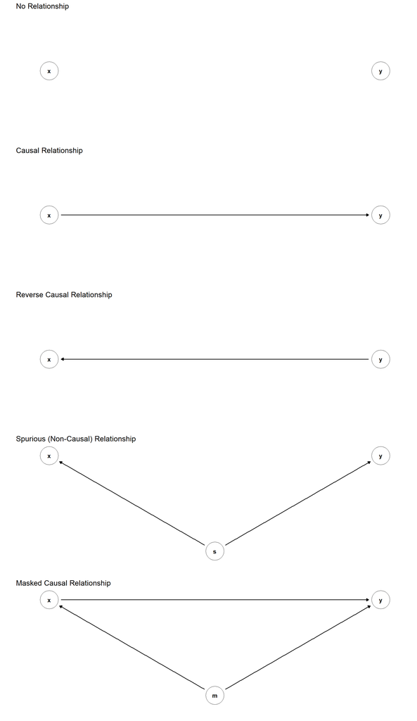

**NOTE**: *Directed Acyclic Graphs* (Pearl 1988, 1993; DAGs, Pearl 1995). $x$ = Theorized cause, $y$ = outcome, $s$ = spurious confounder, $m$ = masking confounder. Non-exhaustive list of relationship types.

Two other types of confounders considered here are (1) *spuriousness*, which refers to an instance when there is no relationship between the theorized cause and outcome, but where a third variable (e.g., $s$) impacts both of them, creating a spurious relationship that researchers may wrongly attribute to the theorized cause (Gumbel 1933; McElreath 2019: 123-144; Stock and Watson 2019: 584-586); and (2) *masking*, that involves a situation with a relationship between the theorized cause and outcome, but where a third variable (e.g., $m$) impacts both of them in a way that masks their relationship, leading to the researcher wrongly concluding no effect of the theorized cause[^12] (McElreath 2019: 144-153). These related confounders are both reliably solved with an exogenous manipulation, since an exogenous theorized cause by definition cannot be affected by a third variable, preventing any spurious or masking effects to occur. Stated in the terminology of the aforementioned DAGs, this is because an exogenous manipulation closes any and all ‘back-doors’, that is, any relationships between the theorized cause and confounders (i.e., the *back-door criterion*, Elwert 2013: 259-260; McElreath 2019: 184-189; Rohrer 2018: 30-31). However, when the theorized cause is non-manipulable, researchers may alternatively attempt to identify all possible confounders to avoid the issues of falling victim to spuriousness or masking, for example, by drawing encompassing DAGs. However, what constitutes the true DAG of a causal relationship is inherently unknowable (Elwert 2013: 270), and it is the researchers’ responsibility to justify having accounted for all possible confounders (Elwert 2013: 248). Failing to account for *any* confounder can produce spurious or masked relationships, while accounting for *any* non-confounder can induce other types of biases (e.g., *collider bias* or *overcontrol bias*, Elwert 2013: 250; Elwert and Winship 2014; McElreath 2019: 176-183; Rohrer 2018: 34-38). With non-manipulable theorized causes, researchers can reasonably suspect that their results may be confounded and attempt to estimate how much a confounding effect would be necessary to make an identified relationship spurious (e.g., Cinelli and Hazlett 2020). But a shortcoming of such procedures is that researchers may erroneously conclude that because the confounding effect would have to be too large for a known confounder to produce, then the identified relationship must be causal. There are several issues with this argument. Specifically it applies numerous *logical fallacies* (Arp et al. 2019), including an *appeal to ignorance* (Bebbington 2011; McCraw 2019), or alternatively an *appeal to personal incredulity* (Manninen 2019b), if not both, since researchers’ inability to know or imagine such a relevant confounder does *not* mean that this confounder does not exist. Further, assuming that the large confounding effect would have to originate from a single confounder commits the *oversimplification fallacy* (Burkett 2019), since the large confounding effect could be caused jointly through the aggregation of smaller effects by numerous confounders. Ultimately, unless researchers know the functional form of the confounder, which they rarely do, they cannot know the magnitude by which it may confound results (Deaton and Cartwright 2018: 4).

In line with these insights, the issues of reverse-causality, spuriousness, and masking would seem most reliably solved through an exogenous manipulation of the theorized cause. This implies that any phenomenon that is merely observed or manipulated in an non-exogenous manner may be *endogenous* and affected by confounders (Mutz and Pemantle 2012: 3), such as reverse-causation, spuriousness, and masking. Accordingly, researchers interested in drawing causal inference from non-manipulable phenomena face numerous issues of confounding that *a priori* justify serious concerns regarding the reliability of causal inference drawn from possibly endogenous phenomena. While numerous methodologies exist to mitigate these concerns, as will be made clear in the subsequent section, unless they enable an exogenous manipulation of the theorized cause, these justified concerns generally make them unable to provide reliable causal inference.

### 3.1.3 Issues with Existing Solutions

The issues of drawing reliable causal inference with non-manipulable theorized causes are widespread and affect numerous phenomena of substantial scientific interest. Non-manipulable phenomena include ‘gender, personality, and other deeply rooted traits and values […]’ (Buunk and van Vugt 2013: 17) that all have been the focus of numerous studies (Block and Block 2006; Graham and Haidt 2012; Mac Giolla and Kajonius 2019; e.g., Mondak 2010). These are generally considered non-manipulable (e.g., Holland 1986: 946) either for ethical reasons or due to being biologically rigid and thus practically impossible to manipulate (e.g., *personality traits*, Buss 2009; Larsen et al. 2021; Mitchell 2018). For the aforementioned reasons, any causal relationship involving non-manipulable phenomena, RCTs cannot be employed for reliable causal inference, and observational designs that fail to account for the possibility of confounding thus risks making false positive or false negative conclusions regarding the hypothesized causal relationships. A solution to this issue could involve changing the scope of the research from causal inference to correlational or predictive inference, since this avoids the issue of making false *causal* conclusions. However, researchers may find it difficult to change scope if their central interest is specifically that of a causal relationship. This is evidenced by researchers often making inappropriate causal interpretations (for such criticisms, see, e.g., Chiu et al. 2023; Keele 2015; Lee 2012; Rohrer 2024; Samii 2016) despite the lack of manipulability of the phenomena essentially restricting them to correlational/predictive/imputational inference. While they often justify a causal interpretation through theory (e.g., Xu and Peterson 2017), given the multitude of ways for confounding outlined above, a theoretical argument alone seldom provides any reliable guarantees for the absence of confounding, a consideration that is further expanded upon below.

A strategy for researchers to justify a causal interpretation when being unable to exogenously manipulate the theorized cause is through theory and argumentation. While this arguably helps justify a causal interpretation (Elwert 2013: 247), such arguments often make implicit, if not explicit, use of *logical fallacies* (Arp et al. 2019). Examples of fallacious logic that researchers can employ to justify a causal interpretation include *shifting the burden of proof* (Russo 2019) of the causal claim to the skeptic (e.g., ‘If you are so skeptical of my claim that $x$ causes $y$, prove to me that $x$ does *not* cause $y$.’). This is a logical fallacy because the *burden of proof* (*onus probandi*) ultimately falls upon the one making the causal claim (i.e., the researcher) and *not* the one skeptical of the claim (Cargile 1988; Hume 2010[1748]; Russo 2019; Sagan 1979). Another fallacy can involve a researcher justifying a causal interpretation because (whether guided by theory or intuition) they cannot imagine any confounders, or have accounted for the select number of confounders of which they are aware (e.g., ‘I have controlled for $z$ so therefore $x$ must cause $y$.’). This would be the fallacy of an *appeal to ignorance* (Bebbington 2011; McCraw 2019), or alternatively an *appeal to personal incredulity* (Manninen 2019b), if not both, since the ignorance of (or inability to imagine) confounders does *not* equate with there being no confounders. The probably least sound argument explicitly involves simply requiring researchers to be able to imagine a causal relationship (Morgan and Winship 2007: 279; as cited by Bollen and Pearl 2013: 313), which obviously fails to lift the burden of proof and is highly susceptible to *confirmation bias* by the causal claimant (Johnson 2019). Another, perhaps more commonly known, logical fallacy that researchers can employ is to suggest that a correlation between phenomena implies causation. This would be a *cum hoc ergo propter hoc* logical fallacy (Manninen 2019c), since the co-occurrence of phenomena, *no matter how consistent*, does *not* necessitate that one phenomenon be the cause of the other[^13]. This is why researchers generally recognize that *correlation does not imply causation* (Pearson 2015[1900]) and that *causation does not imply correlation* (Kennaway 2015).[^14]

Researchers can also employ methodological designs to help justify a causal interpretation of results. Among the more justifiable approaches is the *natural experiment* (Dunning 2008; Stock and Watson 2019: 490), which attempts to exploit a manipulation of the theorized cause to help identify a causal effect. The natural experiment, however, differs from an RCT, since this manipulation is *not* controlled by the researchers, but instead is under the control of ‘naturally occurring’ phenomena. In line with the logic underlying the RAM in RCTs, it remains key that this natural manipulation occurs *exogenously* of all possible confounders, which in this context is referred to the manipulation being *as-if-random* (Stock and Watson 2019: 497-498). Should the naturally-occurring manipulation fail this criteria, it will be endogenous, resulting in possible confounding and unreliable causal inference. Numerous researchers have employed natural experiments to test theorized causal relationships with theorized causes not manipulable by researchers (e.g., Erikson and Stoker 2011; Jones and Olken 2005; Kokkonen and Sundell 2020). Here, the *as-if-random* manipulation is often sought justified through theory and knowledge about the manipulation mechanism. While some manipulation mechanisms are undoubtedly more credibly exogenous than others (e.g., a lottery, Erikson and Stoker 2011), many are open to the aforementioned logical fallacies (e.g., ‘I think of no confounders, ergo no confounders.’). The ability of natural experiments to provide reliable causal inference therefore rests on the exogeneity of the manipulation mechanism, which unlike the RAM of RCTs are not generally as testable in relation to their randomness (Mutz and Pemantle 2012). Another limitation is the identification of natural experiments, which can be difficult and subject to luck. As such, while natural experiments, in principle, could enable reliable causal inference through an as-if-random manipulation of a phenomena non-manipulable by researchers, they are difficult to identify, and distinguishing between truly exogenous and endogenous manipulation mechanisms are difficult if not impossible, making them generally unable to deliver truly *reliable* causal inference.

Designs related to the natural experiment (i.e., quasi-experiments) include relying on regression discontinuity designs and instrumental variables. The *regression discontinuity design* (RDD, Skovron and Titiunik 2015; Thistlethwaite and Campbell 1960) involves identifying a causal effect by studying a theorized cause across a time period. During this period some change is induced in the theorized cause, which is expected to cause a change in the outcome (Stock and Watson 2019: 495-496; Angrist and Pischke 2015: 147-177; Angrist and Pischke 2009: 251-267; Gelman et al. 2021: 432-452). To justify a causal interpretation, it is necessary that the change is induced exogenously in an as-if-random manner (Stock and Watson 2019: 496). As such, the procedure is highly similar to a natural experiment, though with the added requirement that the theorized cause is observed across time. While this helps researchers understand variations in the outcome prior to the induced variation in the theorized cause, which undoubtedly can help separate random noise from a possible effect of the theorized cause (e.g., *regression to the mean* effects, cf. Gelman et al. 2021: 87-90; McElreath 2019: 92), this design again relies on strong assumptions of an exogenous manipulation that similarly makes natural experiments generally unreliable for causal inference. By contrast, *Instrumental variables* (IVs, Stock and Watson 2019: 427-472, 494; Angrist and Pischke 2015: 98-146; Angrist and Pischke 2009: 113-218, 259-267; Gelman et al. 2021: 421-454; Imbens and Rubin 2015: 513-584) are phenomena that are manipulable, either by researchers or by naturally-occurring phenomena, which are expected to impact the theorized cause. The idea is to isolate variation in the theorized cause exogenously induced by the IV and identify a relationship between this variation in the theorized cause and the outcome (Angrist and Krueger 1991; e.g., Hariri 2012; Stock and Trebbi 2003; Wright 1928). While for naturally-occurring IVs, whose exogeneity rely on the same issues of as-if-randomness that generally make natural experiments unreliable, IVs exogenously manipulated by researchers can arguably provide a better justification for a causal interpretation of results. While this may sound promising, the reliability of IVs rests on numerous assumptions (Gelman et al. 2021: 422-423), and a central criticism considered here targets the *exclusion restriction* assumption, which states that the IV cannot impact the outcome except *solely* through the theorized cause (Angrist and Pischke 2009: 116-117, 153-154; Angrist and Pischke 2015: 101-107, 130-131; Samii 2016: 948; Gelman et al. 2021: 423). This is a strong assumption that is impossible to test, since this would require investigating every possible phenomena with a temporal occurrence between the theorized cause and the outcome. Consistent with the above, the reliability of this strategy for causal inference cannot rely on researchers’ ability to adequately account for every possible confounder nor for every possible way that an IV could impact an outcome other than through the theorized cause. Accordingly, neither RDDs nor IVs are taken to generally provide reliable causal inference.

A third set of methods that researchers can employ for causal inference involves the construction of counterfactual comparison groups. Such designs include difference-in-differences, synthetic control, matching, and functional adjustment. Through different means these all attempt to correct for imbalances between units varying with respect to the theorized cause, which if inadequately accounted for can introduce confounding through *selection bias* (Angrist and Pischke 2015: 8-11; Angrist and Pischke 2009: 23-24; Deaton and Cartwright 2018: 9; Heckman 1979; Rohrer 2018: 36-38). The perhaps most sophisticated of these is the *difference-in-differences* (DiD) design (Stock and Watson 2019: 492-494; Angrist and Pischke 2009: 227-243; Angrist and Pischke 2015: 178-208). This involves observing at least two groups across time, where one group experiences a (naturally) occurring change in the theorized cause. To assess the counterfactual scenario of the outcome had this group not experienced this change during the observed time period, the difference in the outcome of the non-changed group for the same time period is used as an estimate of the counterfactual difference, producing a difference-in-differences estimate (e.g., Allers and Hoeben 2010; Bechtel and Hainmueller 2011; Card and Krueger 1994). For this method to be reliable, the changed and the non-changed group must be balanced in terms of *all* possible confounders prior to the chance in the theorized cause, an assumption that has also been referred to as *parallel trends* (Angrist and Pischke 2015: 184-187). This is commonly ascertained by assessing balance between the groups prior to the change. If data contains numerous measurements of the groups pre- and post-manipulation, this method can be combined with RDD to produce the possibly more reliable *differences-in-discontinuity* design (Grembi et al. 2012). However, it is clear that the assessment of parallel trends requires assuming a version of *no unmeasured confounders* to avoid results being plagued by *omitted variable bias* (OVB, Angrist and Pischke 2015: 69-93, 132-174, 212-213; Ho et al. 2007: 206), which again is dubious since researchers may not know of all possible confounders. Given these and other issues (e.g., Baker et al. 2022; Bertrand et al. 2004; Ferman 2023; Kahn-Lang and Lang 2020; Ryan et al. 2015), in accordance with the above, this method can similarly be found too unreliable for causal inference.

The *synthetic control* method similarly requires data across time, with the same underlying logic of a group experiencing a change in the theorized cause (Abadie et al. 2010, 2015; Abadie and L’Hour 2021). Here, multiple groups not experiencing this change are used to construct a counterfactual estimate of the outcome of the changed group had it not experienced the change. This involves a re-weighing of data similar to matching (see below), and for a causal estimate to be reliable, the counterfactual comparison group cannot differ from the treated group with respect to unobserved confounders. As such, it can be subjected to the same criticisms of plausibly failing to account for omitted variables as the DiD, making it similarly unreliable for causal inference.

By comparison, *matching* (Angrist and Pischke 2015: 50-56; Angrist and Pischke 2009: 69-91; Ho et al. 2007; Imbens 2015; Imbens and Rubin 2015: 337-358; Stuart 2010; e.g., Kam and Palmer 2008) does *not* require longitudinal data, but it similarly involves constructing a counterfactual outcome using units that did not experience a change in the theorized cause. While it does not rely on ‘parallel trends’ like the DiD, it does make the same innate assumption of no unobserved confounders (Samii 2016: 948; Stuart 2010: 5; Rohrer 2018: 32-33; Ho et al. 2007: 200, 206-207), and in the event of failing to account for any confounder, this can re-introduce confounding through selection bias (Imai et al. 2008: 489; Pearl 2000; Wan et al. 2024). These and other issues (Imai et al. 2008; King and Nielsen 2019) means that it can generally be considered to fail in providing reliable causal inference, in particular for any scenario where researchers cannot reliable demonstrate no possible confounders.

Lastly, *functional* or *parametric adjustment* (cf. Stuart 2010: 2; Imai et al. 2008: 489), commonly known as *controlling*, involves the inclusion of covariates in a statistical model in an attempt to account for confounding phenomena. This is closely related to matching, and while it can reduce imbalances between two groups varying with respect to the theorized cause, as well as reduce variation in the outcome to help identify an effect of the theorized cause, the reliability of this procedure relies on numerous assumptions. This includes the assumption of *correct functional form* (Ho et al. 2007: 218), which means that the relationship between the confounder and the theorized cause and outcome must have been modeled correctly. For example, a *linear* adjustment is only appropriate if the impact of the confounder truly is linear, which can be difficult to ascertain. Another assumption shared with matching (Ho et al. 2007: 202) is that the phenomena being adjusted for must temporally precede the theorized cause, since the adjustment of any phenomena that occurs after the theorized cause risks inducing *post-treatment bias* (Montgomery et al. 2018). A more critical assumption is again the assumption of no unmeasured confounders. Since both matching and functional adjustment amounts to nothing more than *selection on observables* (Imbens 2015: 373), their ability to provide reliable causal inference relies on the correct adjustment for *all* confounders (Imai et al. 2008; Stuart 2010: 3), including confounders of which the researchers doing the adjustment may not be aware. For these reasons, functional adjustment also generally fails to provide reliable causal inference (cf. Aronow and Samii 2016; Imai et al. 2008; Samii 2016). With all these designs relying on the assumption of no unobserved confounders, it is worth stressing that in their attempt to increase balance, either by choosing groups similar to the group experiencing a change in the theorized cause, re-weighing groups, matching units, or making functional adjustments, that this runs the risk of increasing other imbalances. That is, by decreasing some imbalances, they can introduce new imbalances through selection bias, specifically by conditioning on observables (Ho et al. 2007: 202; Rohrer 2018; Wan et al. 2024).

Given the above review of existing methodologies for causal inference with non-manipulable phenomena, while it may seem strict to deem these methods unreliable in terms of causal inference, the take-away is that viewing these methods as being able to provide reliable causal inference generally increases the risk of making false causal conclusions in an manner that can be considered to be unjustified. Instead of putting researchers in a position where they have to measure all possible confounders, since this is the burden of proof of causal inference, an alternative and reliable approach would, instead of relying on numerous dubious and untestable assumptions, involve a design that at least guarantees, or at least by expectation, simply by its design, that results cannot be systematically confounded (cf. Rohrer 2018: 34; Stuart 2010: 3; Samii 2016). Researchers must listen to the multiple criticisms targeting attempts at causal inference with non-manipulable phenomena (e.g., Baumrind 1983; Berk 1994; Cartwright 1994; Cliff 1983; de Leeuw 1985; Elwert 2013; Freedman 2004; Guttman 1977; Imai et al. 2008; Rohrer 2018; Samii 2016; Wan et al. 2024), recognize that there simply can be ‘no causation without manipulation’[^15] (Holland 1986: 959), and understand that, similar to that of the RAM in RCTs, reliable causal framework generally necessitates an exogenous manipulation.

## 3.2 Synthetic Causal Framework

The previous sections have established that (1) a causal effect is the difference in potential outcomes, (2) that confounding is an ever present threat when the theorized cause is non-manipulable, and (3) that existing solutions generally fail to provide reliable causal inference, at least by comparison to RCTs. The consequence of the latter is that substantial parts of scientific disciplines interested in non-manipulable theorized causes are barred from making reliable tests of causal hypotheses, making a solution to this problem relevant for scientific progress. These insights will be used to lay the foundation of a framework aimed at solving the issue of non-manipulability and provide a methodology that can provide causal inference as reliable as RCTs.

The novel framework devised here to enable researchers to draw reliable causal inference when the theorized cause is non-manipulable will be denoted the *Synthetic Causal Framework* (SCF), which will be outlined and formalized in this section. The development of this framework will draw on the established logic and notation by the *Neyman-Rubin Potential Outcomes Framework* (POF, Holland 1986; Imbens and Rubin 2015; Neyman 1923; Rubin 2005), with the aim of maximizing reliability through a high internal and external validity *by design* (cf. Stuart 2010: 3; Rohrer 2018: 34; Samii 2016). Following the POF, an *a priori* high internal validity will be achieved by making the non-manipulable theorized cause *exogenously manipulable*, allowing causal inference to be at least as internally valid as RCTs (cf. Angrist and Pischke 2009; Imai et al. 2008: 488; McDermott 2011; Stock and Watson 2019: 478-481). As similarly proven by theory on statistical inference, *random sampling* (Angrist and Pischke 2015: 14-16, 34-37; Thompson 2012) will be employed by the framework to provide a high external validity (cf. Gelman et al. 2021: 354-355; Stock and Watson 2019: 481; Imai et al. 2008: 488; McDermott 2011).

The first step in developing the SCF involves defining its scope. Given that the theorized cause is often non-manipulable in the social and behavioral sciences (Buunk and van Vugt 2013: 17), due to the manipulation of humans sometimes being unfeasible (e.g., due to ethical, practical, or cost concerns), the SCF will be developed with the intended aim of application within these disciplines, specifically for research topics where human individuals are the unit of interest, and where the theorized cause would otherwise not be manipulable. This means that the concern for external validity in relation to the SCF involves *inference to human populations*. The successful development of the framework will thus require an ability to rely on random sampling from an arbitrary human population, at least on a theoretical basis, and the manipulation of an arbitrary theorized cause, with results derived from an analysis of this manipulation being generalizable to the intended human population. This limitation in scope is unlikely to substantially reduce the usefulness of the framework, since the social and behavioral sciences encompass numerous disciplines and subdisciplines (Wright 2015). This is *not* to say that the SCF cannot necessarily be applied to other areas of research, but the scope helps clarify its intended area of application, as well the area-specific assumptions and limitations that the development and application of the SCF needs to consider and be evaluated against.

### 3.2.1 Large Language Models

With the intended application of the SCF being that of human-based studies, considerations can be made about random sampling and how to achieve an exogenous manipulation of an otherwise non-manipulable theorized cause. Given that numerous social scientific studies are conducted using *online surveys* (Batinic et al. 2002; Gideon 2012), where human respondents provide text-based responses, the solution that will underlie the SCF involves simulating human behavior using *Natural Language Processing* (Pillai and Tedesco 2023). In this field, *Large Language Models* (LLMs, Shanahan 2024) are developed with the specific aim of imitating human language and intelligence (Ornstein et al. 2024; e.g., Kjell et al. 2022). There have been numerous advances in this field, with LLMs being increasingly complex and trained on larger sets of data of text-based human language (OpenAI 2024b; 2024c; e.g., OpenAI 2022). The most advanced models include the *Generative Pretrained Transformers* (GPT) by OpenAI, such as the popular *ChatGPT* (OpenAI 2022). These GPT-models have proven capable of closely mimicking not just human language (Jansen et al. 2023; e.g., Colette et al. 2024; OpenAI 2022), but also human cognition, performing comparably in terms of logic, mathematics, and communication (e.g., OpenAI 2024a; 2024b; 2024c). For example, *GPT-4o* (OpenAI 2024b) can process text, audio, and image input, making it easy for researchers to use it in various ways, while *o1* (OpenAI 2024c) can engage in complex reasoning that has enabled it to [outperform physics PhDs](https://medium.com/@researchgraph/how-openais-o1-series-stands-out-redefining-ai-reasoning-9e499937139e). The prospect of simulating human behavior using such models has been recognized by researchers (e.g., Bail 2024). For example, LLMs have previously seen success in simulating patients to help train medical doctors (e.g., Holderried et al. 2024; Pang et al. 2024). A reliance on LLMs, however, restricts the application of the SCF to language-based mostly-online virtual environments, since the use of these models generally require a stimuli expressible through natural language in the form of a *prompt*, and efficient use of these models generally involve making online requests to the LLM using an *application programming interface* (API, De 2023), which require a stable internet connection. However, since text-as-data approaches are becoming more popular (e.g., Alrababa’h and Blaydes 2021; Barberá and Rivero 2014; Chadefaux 2014; Daigneault et al. 2018; Hollibaugh 2019; Van Atteveldt et al. 2017), this limitation to a text-based virtual environment is nonetheless unlikely to substantially reduce the SCF’s general applicability to researchers. At the same time, while their performance can be considered impressive, such models still have limitations (e.g., Edyko et al. 2023; Koga and Du 2024; Lecler et al. 2023; Obaid et al. 2023; Park and Choi 2024; Saka et al. 2024; Shea and Ma 2023; Zhang et al. 2024), and one might question whether models trained on natural language can be expected to sufficiently capture the nuances of human behavior.

To build a case for LLMs being capable of emulating human behavior, or at least behavior as it is expressed in natural language, and why such research would even be meaningful in the first place, it should be emphasized that the recognized *functionalist view* in psychology makes no innate distinction between the mental states of humans and mechanical operations of computers (Farrell 2014: 88, 398-403; for a general introduction and criticisms, see, e.g., Farrell 2014: 340-359; Hempel 1959; Rosenberg 2016: 195-210; for an example, see, e.g., Elster 1983). In this view (Farrell 2014: 111), it would be considered entirely meaningful to investigate human behavior through simulated modelling, since what is essential for understanding such behavior is *not* the substance of the unit being investigated but the *function* of their behavior. For example, the question of whether an LLM needs to possess *consciousness* (Eysenck and Keane 2020: 767-800) to emulate human behavior is entirely dependent on whether the distinct functions of consciousness are relevant for the specific behavior being studied. That is, if the functions of consciousness for the studied behavior can be adequately modeled and emulated, research using these models are just as meaningful and valid. Viewed alternatively using *behaviorism* (Farrell 2014: 362-389), *intrapsychic* differences between an LLM and humans, such as the presence of consciousness, would be entirely irrelevant, and any scientific inquiry will yield meaningful insights as long as their *behavior* are indistinguishable.

As to whether LLMs trained on natural language could be expected to sufficiently capture the nuances of human behavior, social psychologists and linguistics have long argued that language, thoughts, and behavior, while distinct phenomena, are closely linked (Holtgraves 2013; Lucy 1992; Thibodeau and Boroditsky 2011; Whorf 2011[1956]; e.g., Carpenter and Drabick 2011; Chen 2013; Fausey and Boroditsky 2010; Gao et al. 2015). Natural language is a medium for communicating information (Lyons 1991), and the types of data transferable in this manner are numerous. For example, information about the characteristics of objects (e.g., their color and shape), groups (e.g., their shared identity and goals), and individuals (e.g., their values and beliefs) can be communicated through natural language. Communication does not necessitate the transfer of information *between* individuals, since individuals sometimes engage in *subvocal talking* (i.e., thinking, Farrell 2014: 377-378), which can also occur vocally (i.e., by talking to oneself), and these types of communication are similarly communicable through natural language, showcasing just how nuanced human behavior can be captured through language. This is mostly achieved by language providing a formalized syntax, grammar, and vocabulary for expressing past and present thoughts, relations, experiences, feelings, values, and intended behavior in a structured, consistent, and *predictable* manner (Anderson 2020: 375-448; Eysenck and Keane 2020: 461-568; Lyons 1991). At the same time, language is undergoing constant adaptation to human requirements for communication (e.g., the term ‘Synthetic Causal Framework’ was invented to denote the concepts introduced in this paper), making it relatively reliable in terms of capturing the nuances of old and new behavior. Especially relevant is the consideration that language can be used to communicate one’s intended behavior, which can be considered an imperfect proxy for actual behavior (Ajzen and Fishbein 1977; Back et al. 2009; Zanna et al. 1980), since stated behavior is not necessarily equivalent to actual behavior.

The ability of language to capture the nuances of human behavior is further supported by *personality psychology* (Larsen et al. 2021), where trait-based approaches have relied on the *lexical hypothesis* (Galton 1884) to derive distinct personality traits that capture large parts of human behavior. This lexical hypothesis states that as language has evolved, the most relevant characteristics to distinguish individuals from each other have been incorporated into our language as distinct words. This ties into the use of language as being revelatory of the intraphychic state of individuals, with communication patterns and choice of words being predictive of the psychological states and social behavior of an individual (Chung et al. 2007; Pennebaker et al. 2003). But language not only *expresses* behavior in a nuanced manner, it also ‘shapes thought patterns on which actions are based.’ (Bandura 1999: 195). This means it also *affects* behavior by structuring our thoughts (Farrell 2014: 261), with some arguing that language even structures our perceptions of reality (i.e., the *hypothesis of linguistic relativity*, Lucy 1992; Whorf 2011[1956]; e.g., Boroditsky 2001; Fausey and Boroditsky 2011). That language shapes our thoughts and behavior is, for example, evidenced by *framing* (Tversky and Kahneman 1981) and *priming* (Bargh and Chartrand 2000), which often consists of a text-based information, communicated through natural language, that affects behavior by structuring our thoughts, either by presenting fragmented information or making some information salient (Weingarten et al. 2016). Such research demonstrates that human preferences and behavior are *not* fixed *nor* entirely determined on our genetic predisposition and the entirety of our lived experiences, but, consistent with the view of human reason as being *bounded* (Elster 1989/1990; March 1994; Simon 1955), instead vary in relation to the salience of information communicated through natural language. Accordingly, it could be expected that an LLM, despite lacking genes, consciousness, and lived experiences, if provided with enough relevant information about a particular context, could emulate human preferences and behavior, at least as they are expressed using natural language. Given these considerations, language would seem to capture many relevant nuances of human behavior, making human behavior somewhat predictable from natural language, and since LLMs have been trained on natural language (Ornstein et al. 2024), they can arguably be expected to, albeit imperfectly, predict human behavior.

### 3.2.2 Simulated Data

The choice of the SCF to mimic human behavior using LLMs to make non-manipulable theorized causes manipulable invites concerns regarding the appropriateness of essentially simulating data for research. Simulated data is often used by researchers in statistics to investigate the properties of estimators, since simulations allow them to control every underlying aspect of the data (e.g., Green and Yang 2009; Hanmer and Kalkan 2013; Homburg and Dobartz 1992; Hu and Bentler 1999; Jackson 2003; MacCallum 1990; Sheng and Sheng 2012). While concerns regarding the inference of simulated results to real world applications could plausibly be justified, such inferences underlie numerous approaches to research, and are, as mentioned, consistent with functionalist and behaviorist psychology (Farrell 2014: 88, 111, 362-389, 398-403). For example, the statistical method of *bootstrapping* (Efron 1979, 2003; Efron and Tibshirani 1994) is used to make inferences to the real-world, and this involves simulating counterfactual samples of real-world data to obtain a sampling distribution of the estimates, their usefulness for inference generally outcompeting analytical approaches in terms of robustness (Angrist and Pischke 2009: 293-308; King and Roberts 2014). For the *non-parametric bootstrap* (Efron and Tibshirani 1994; e.g., Barber and Thompson 2000), this is done by permuting data (i.e., re-sample data with replacement), assuming that the unit characteristics in the data are proportional to their prevalence in the population, while the *parametric bootstrap* (Efron and Tibshirani 1994; e.g., Studer 2021) involves assuming a specific probability distribution for the estimates and computing sampling distributions using *Monte Carlo* simulation (Robert and Casella 2013; Rubinstein and Kroese 2016). This is similarly done in *Bayesian statistics* (Bayes and Price 1763; Gelman et al. 2014; Kruschke 2014; Laplace 2009[1814]; McElreath 2019) with the use of *Markov-Chain Monte Carlo* methods (Brooks et al. 2011; Duane et al. 1987; Gelman and Rubin 1992; Metropolis et al. 1953), which like the parametric bootstrap, involves parametric simulations. These methods have from a statistical-theoretical standpoint numerous advantages, and they are generally considered valid when making inferences to the real-world (e.g., Gelman et al. 2021; Imai and Tingley 2012: 223-224; King et al. 2000: 352; Pawitan 2001: 122). Besides relying on simulations for statistical inference, they are also used when encountering real-world limitations of the phenomena being studied. For example, in the field of *social dilemmas* (van Lange et al. 2013), simulations underlie *agent-based modeling*, which are models used to estimate the actions of individuals in relation to social dilemmas across a number of trials too large to feasibly be conducted with human participants (van Lange et al. 2013: 31; Macy and Willer 2002), and this is again entirely consistent with a functionalist view of social research (Farrell 2014: 88, 398-403). This means that the reliance on simulated data is *not* necessarily inappropriate for research, and it can be emphasized that ‘as with any computer simulation, it becomes important to collect actual data, contrast the results against the simulation results, and then address the question of why there are deviations between the modeled and actual results.’ (van Lange et al. 2013: 31) As such, similar to the bootstrap, Bayesian statistics, and agent-based modeling, the employment of simulations in the SCF do *not* automatically make results invalid nor meaningless. Instead, it poses an empirical question regarding the quality of the simulated data and the ability to infer results to human populations, something that the SCF must be validated against.

In terms of data quality, consistent with the mantra of *garbage-in-garbage-out* (GIGO, Yoder-Wise 2023), the ability of the SCF to provide reliable causal inferences hinges in part on its external validity, since its fundamental aim is to generalize results to human populations. To take advantage of the aforementioned fact that LLM have been trained on a plethora of data containing natural language expressions of human thoughts, values, and behavior (cf. OpenAI 2024a; 2024b; 2024c; 2022; Ornstein et al. 2024), which would expectedly allow it to closely emulate human behavior as expressed through natural language, the SCF will *simulate human units by using an LLM to behave as each unit*. This means that the SCF produces results based on LLM-driven inferences of human behavior. Given that the external validity of this behavior is critical, the SCF will involve several procedures that serve to make the LLM-based behavior as realistic as possible. The first step involves supplying the LLM with a prompt detailing relevant characteristics of each human unit. Since LLMs are inherently text-processing neural networks that generate a probability-based output based on the input (cf. OpenAI 2024a; 2024b; 2024c; 2022; Ornstein et al. 2024), supplying the model with the characteristics of each simulated unit will likely enable it to more accurately infer the types of language-based behavior of an individual with those specific characteristics (cf. Chung et al. 2007; Pennebaker et al. 2003). While the relevancy of characteristics will likely differ between research topics, human characteristics that are generally considered relevant include those related to their sex, age, income, education, and geography (Memon et al. 2024). Researchers applying the SCF are encouraged to consider characteristics beyond those mentioned here, since consistent with concerns of latent measurement precision (cf. Bakker and Lelkes 2018; Credé et al. 2012), the greater the amount of simulated characteristics, the more precise the LLM can plausibly be expected to realistically and generalizably infer human behavior when controlling simulated units. At the same time, researchers should note that, just like humans (cf. Anderson 2020: 171-244; Eysenck and Keane 2020: 239-392), LLMs have a finite limit of how much information they can process and retain (cf. OpenAI 2025a), so the most relevant characteristics in relation to the research topic should likely take precedence. As such, by explicitly specifying these characteristics and supplying them to the LLM, it is expected that its ability to realistically emulate humans will expectedly increase.

The second consideration is that, like with any human data (Aronow and Samii 2016; Deaton and Cartwright 2018), the external validity of the simulations are closely related to how representative the simulated units are of the population of interest. If data on the entire population of interest is available, external validity is generally *not* a concern (Imai et al. 2008), but since the simulation of every human in a population would likely be unfeasible for a practical implementation of the SCF, the framework will be developed with a reliance on samples of simulated human units in mind, making external validity a concern. Generalizing from any sample to a population, it is an ideal that the unit characteristics in the sample are proportional to their prevalence in the population, since sample-population imbalances can produce errors (e.g., Type M and S) if effects vary across characteristics (Gelman et al. 2021: 59; Gelman and Carlin 2014; Imai et al. 2008). A sample with characteristics representative of the population is typically achieved through *random sampling* (Stock and Watson 2019: 108; Thompson 2012), where each unit has the same probability of being included in the sample. However, since the SCF will rely on LLM-based simulated units, a random sample from a population cannot be achieved in the conventional manner, for example, by distributing an online survey. Instead, the SCF will involve a *simulated random sample*, which will specifically be done by considering representativeness solely with respect to the aforementioned relevant characteristics. To apply random sampling to the simulation of these characteristics, it is necessary to obtain the prevalence of these characteristics in the population of interest. This may be unfeasible for some applications, but census data often contain such micro-level data, or at the very least, estimates of them (e.g., the IPUMS for the US Population, Ruggles et al. 2024). To then mimic random sampling, it is ideal if the simulated random sampling relies on the *joint probability of characteristics* (i.e., the probability of a characteristic conditional on all other characteristics), since different combinations of characteristics may *not* have equal probability of occurring in the population. For example, suppose that the population of interest is the voter population of the United States and that the characteristics to simulate are race (e.g., Caucasian and Afro-American) and party affiliation (e.g., Democrat and Republican). Here, it is known that Afro-Americans, compared to Caucasians, have greater probability of being affiliated with the Democratic Party than the Republican Party (Wallace et al. 2009), so it would be incorrect for the simulation to assume that the probability of being a Republican *and* a Caucasian is the same as the probability of being Republican *and* Afro-American (i.e., $Pr(Republican \ | \ Caucasian) \ne Pr(Republican \ | \ Afro-American)$). Accordingly, a simulated random sampling that simulates characteristics with independent probability would fail to account for this interdependence of characteristics, which is why the SCF will simulate random sampling using joint probability. This procedure for simulated random sampling can be implemented by transforming the census data into a *stratification matrix* (cf. Gelman and Little 1997), which is characterized by containing the proportion of each combination of the characteristics in the population, which in Frequentist statistics is equivalent to the joint probability. Analogous to the aforementioned bootstrapping (cf. Efron 1979, 2003; Efron and Tibshirani 1994), joint probability random sampling is implemented by randomly sampling with replacement from the stratification matrix, with the sampling probability being the (estimated) population proportion of each combination of characteristics. As evidenced by the equivalent logic of the bootstrap (cf. Efron 1979, 2003; Efron and Tibshirani 1994), this (asymptotically) guarantees a sample representative of the population with respect to the characteristics. A limitation of this procedure is the reliance on census data, which can contain measurement error and may not be current, easily available, nor contain measures of all relevant characteristics. For these instances, it may be necessary to simulate characteristics with outdated population estimates and/or without accounting for interdependencies. Nevertheless, the use of a joint-probability-based random sampling helps ensure that the characteristics supplied as the basis of the LLM-driven simulated units are sampled in proportion to their prevalence in the population of interest, increasing the external validity of the SCF.

### 3.2.3 Life-Histories

To further improve the ability of the SCF to provide results that generalize to human populations, the literature on life-histories (Bertaux 1981; Rosenthal 2018; Schütze 1997, 2008) is consulted. To understand why the concepts of life-histories can be used within the SCF to make the behavior of the simulated units more realistic, a brief review is presented here. A *life-history* can be considered ‘a narrative *gestalt* that must be envisioned as an ordered sequence of personal experiences’ (Schütze 2008: 168; cited in Wygnańska 2019: 116, emphasis in original), whose orderliness ‘implies the inner identity development of the biography incumbent’ (Schütze 2008: 168; cited in Wygnańska 2019: 116). This means that a life-history is a structured autobiographical narrative, and the fact that it expresses a person’s psychological construction of self-identity based in intuition (Schütze 2008: 164; Wygnańska 2019: 115) is supported by evidence of people forming ‘spontaneous narratives of self-lived experiences’ (Riemann 2014: 27; e.g., Alea 2008; Bellana et al. 2022). In sociology, this concept is the foundation for the *life history method*, a style of interview, where the interviewer lets the interviewee tell their life history (Riemann 2014: 23; Wygnańska 2019: 113). The method has seen extensive use (for review, see, e.g., Goodson 2001; for critcisms, see, e.g., Hamel 2013), including case studies of people having undergone traumatic episodes (Gaulejac 1997; e.g., Riemann 2014; Wygnańska 2019). Being the storyteller of their own life, the emphasis of this method is on the interviewee’s subjective experiences, and they have generally free constrains on how to order and frame their life and what experiences to talk about. A life-history can include information about the origin of the interviewee’s parents, their childhood, family dynamics, ethnicity, moral and cultural values, education, employment, social interactions, and experiences as an adult (e.g., Riemann 2014; Williams and Khan 2020; Wygnańska 2019). The main advantage of this method is ‘the possibility for the narrator to recreate in his/her story, the significant biographical processes that shaped his/her life in subsequent phases of biography, experienced situations, and the social framework in which his/her biographical processes took place.’ (Kaźmierska and Schütze 2013: 131; cited in Wygnańska 2019: 115). This means that the interview does not have to extensively cover all aspects of their life, letting the interviewee choose to highlight what they perceive as the most defining events of their life. Based on the life-history, the researchers then attempts to ‘explain motivations, attitudes, and values that shape human behavior and the flow of human affairs’ (Stanfield 1987) by basing the analysis on how the interviewee constructs meaning around the events of their life (Schütze 2008: 131; Wygnańska 2019: 116). Since this narration may cover traumatic events and socially undesirable behavior of the interviewee, trust between interviewee and interviewer are critical for the quality of the information divulged in this manner (Riemann 2014: 23; Wygnańska 2019: 115), and if this is achieved, even socially undesirable behavior can be divulged.

This concept of life-histories can be used by the SCF to further characterize simulated units. Compared to manually specifying every relevant characteristic, by letting the LLM serve a the autobiographical narrator of the simulated unit, the relevant characteristics assigned to each unit (e.g., gender, age, income), based on the aforementioned joint probability sampling procedure, can be used to the LLM to further ‘flesh out’ the unit through the generation of a life-history containing more characteristics and information about the unit. Stated differently, prompting the LLM to generate a life-history allows the generation of greater nuances about the individual, their identity, and behavior. Similar to the rationale for supplying the LLM with explicitly assigned relevant characteristics, basing the life-history on the assigned characteristics serves to ensure that the contents of the life-history are probabilistically determined conditional on the assigned characteristics. Compared to merely supplying the assigned characteristics to the LLM as a list, this also serves to embed the assigned characteristics in a realistic manner within the narrative structure of the life-history, allowing them to contribute to the creation of a more *ecologically valid* (cf. Schmuckler 2001) autobiographical identity of each simulated unit. This, of course, requires that the LLM generates a life-history that includes and is consistent with the assigned characteristics. While these are relevant concerns, they are partly empirical and can be evaluated by the researcher by comparing the assigned characteristics with the generated life-history. As such, prompting the LLM to generate life-histories based on the assigned characteristics are likely to provide more information on the type of individual that the LLM is to emulate, thus increasing the realism and external validity of the LLM-based behavior to human populations. Similar to the specification of relevant characteristics to simulate for the simulate units, note again practical limitations on the length of life-histories, which need to be short enough for the LLM to process and retain it when controlling the behavior of the synthetic units.

### 3.2.4 Synthetic Units

The synthesis of simulated characteristics and the LLM-generated life-history is expected to produce units that when controlled by the LLM produces substantially more realistic and generalizable behavior than simulated units lacking life-histories. This is because the LLM, by merit of being trained on real-world data (OpenAI 2024a; 2024b; 2024c; Ornstein et al. 2024), expectedly infuses the researcher-assigned characteristics with real-life characteristics, making the product not strictly simulated nor strictly real. As such, units produced by the synthesis of simulated characteristics and LLM-determined life-histories will, borrowing *Hegelian dialectical terminology* (Fichte 1970; Hegel 2014; though see Kaufmann 1959: 154), be denoted as *synthetic units* to clarify a conceptual distinction from simulated units. The concept of ‘synthetic units’ borrows from the existing concept of *synthetic data* (e.g., Abadie et al. 2010; Agarwal et al. 2023; Emam et al. 2020; Strübing et al. 2023). Such data similarly involves a synthesis between real-world and simulated data, and it has been used to circumvent privacy laws, where data containing personal information is used to generate realistic but simulated data that can be shared without violating such laws (Abowd et al. 2004; Emam et al. 2020). On a similar note, synthetic data is also used to train deep learning models aimed at real-world application (Nikolenko 2021; Kennedy et al. 2024; e.g., Zivenko et al. 2025). Consistent with the SCF’s reliance on LLM to generate synthetic units, previous studies have generated synthetic data using statistical models (Christensen et al. 2019: 187; e.g., Kinney et al. 2011), and the synthetic units produced by an LLM with the SCF can thus be considered to constitute a special case of synthetic data that is entirely valid for the basis of research. This also means that a key step of applying the SCF is thus the transformation of simulated units into synthetic units by generating life-histories based on relevant characteristics that are sampled in proportion to the population.

With synthetic units having been produced, it is then possible to conduct a study using these units in place of human respondents. This has the caveat that synthetic respondents can be manipulated in many more ways compared to human units, since there are fewer practical, ethical, and cost concerns. This means that a previously non-manipulable theorized cause could in principle be manipulated with the SCF, though a key assumption here is that the manipulation is meaningfully expressible through natural language and can be processed as input by the model (e.g., text, images, etc.). For example, if the purpose of the study is to evaluate the effects of a new pharmaceutical drug on human welfare, the LLM-driven synthetic respondents conceptualized by the SCF will likely yield invalid results because the LLM necessitates that the phenomena under investigation can be meaningfully captured in existing language-based expressions. The effects of a new drug fails to meet this criteria, because the effects of pharmaceutics mostly involve biochemical processes that may *not* be distinctly expressed in natural language. Accordingly, the use of the SCF in medical research is likely *invalid* and should only be considered with utmost precaution due to the direct ramifications of such research on human health. With these considerations in mind, the specific procedure used in the SCF to achieve an exogenous manipulation can then be outlined.

### 3.2.5 Exogenous Manipulation

For the SCF to provide an internal validity compareble to RCTs, the manipulation of the theorized cause in synthetic units must be *exogenous* to reliably avoid confounding (cf. Angrist and Pischke 2015: 1-46; Angrist and Pischke 2009: 15-22; Stock and Watson 2019: 48-49; Wooldridge 2019: 54-56). In line with the aforementioned considerations on this, Guido W. Imbens and Donald B. Rubin (2015: 31) have outlined theoretical restrictions on what constitutes an exogenous assignment mechanism, which involve it being *individualistic, probabilistic, and unconfounded*. These restrictions apply to the aforementioned RAM of RCTs, where each unit is *individually* assigned to a group manipulation condition (e.g., treatment or control), with *equal probability* (e.g., 50%), and *independently* of all other factors. This means that the RAM exogenously assigns any individual to any *one* manipulation condition. However, recall from the *Potential Outcomes Framework* and equations 1.4-1.5, how this procedure can be viewed as the result of the inability to assign the same unit to multiple manipulation conditions due to a lack of independence and simultaneity (equations 1.2-1.3), and that the RAM as a result only prevents confounding in an unbiased and asymptotic manner (Deaton and Cartwright 2018: 6). By instead relying on synthetic units, the SCF offers a *synthetic solution* to the *Fundamental Problem of Causal Inference* (cf. Holland 1986), since each unit can be independently and simultaneously assigned to *every* manipulation condition. This is because each synthetic respondent can in principle be exposed to one level of a manipulation theorized to impact the potential outcome, $Y_i(X_{x, i})$, while *independently* and *simultaneously* being exposed to another level of manipulation, $Y_i(X_{x', i})$. The *independence of assignment* occurs because the LLM determining the behavior of the synthetic units in each manipulation condition is unaware of previous, cuncurrent, and future manipulations of each unit, making the potential outcomes independent and thus avoiding *pre*- and *post-manipulation biases* (cf. Linos and Twist 2018; McElreath 2019: 170-176; Montgomery et al. 2018). The *simultaneity of assignment* occurs because multiple requests to the LLM can be made at the same time, which eliminates time as a confounder, because it would not vary between the manipulation conditions (equation 1.3). The results of this is that a counterfactual outcome, one for each manipulation condition, can be measured in an unbiased manner. Causal effects are then computed as the difference of each synthetic unit in one manipulation condition to the same unit in another manipulation condition (equation 1.2), meaning that all unit- and time-invariant factors are subtracted away, producing a causal effect arguably more reliable than one produced by an RCT. Under these conditions, not just *average causal effects*, but *individual causal effects* can be estimated without confounding (cf. Westreich et al. 2015). As such, in the SCF, all synthetic respondents are assigned to every manipulation condition using a *simultaneous and independent exogenous assignment mechanism* (SIXAM). The SIXAM of the SCF meets the aforementioned criteria by being *individualistic* (cf. Imbens and Rubin 2015: 34), since the probability of being assigned to a manipulation condition is independent of the manipulation condition of other units; it is *probabilistic* (cf. Imbens and Rubin 2015: 38), since it meets the requirement of every unit having the possibility of being assigned to any manipulation condition (with that probability being 1); and it is *unconfounded* (cf. Imbens and Rubin 2015: 38), since the assigned manipulation condition does *not* depend on the potential outcomes. As such, the SIXAM of the SCF differs from the RAM of RCTs, and causal effects are derived within the SCF through an independent and simultaneous generation of counterfactual outcomes that are compared across synthetic respondents (see equation 1.2), enabling unbiased estimates of causal effects through the elimination of confounders by design.

The *simultaneity* of the simultaneous and independent generation of counterfactual outcomes outlined above serves to eliminate time confounding results when employing equation 1.2, for reasons previously outlined in relation to equation 1.3. While this paper mostly serves to outline the theoretical framework of the SCF (though for a proof-of-concept, see below), with specific implementations of the SCF likely varying across research topics, a theoretical basis on how to implement a simultaneous generation is provided here for clarity. The ability to simultaneously generate counterfactual outcomes for the same synthetic unit is made possible by the reliance on LLMs, with multiple LLMs being available for use at the same time. Hence, a synthetic unit can be operated by one LLM under one manipulation condition, while the same synthetic unit is operated by a different yet identical LLM under another manipulation condition. This is perhaps most easily achieved by relying on an API for the LLM (e.g., OpenAI’s API, 2025a). By specifying the different manipulation conditions for the synthetic unit, a *parallel process* (cf. Gottlieb and Almasi 1989; Ozdoganlar and Endres 2021[1999]) can be used to simultaneously call the API, one time for each manipulation condition, allowing the LLM to expectedly generate an outcome for each manipulation condition with no time difference nor dependency on the generation of other outcomes under different manipulation conditions. To conceptually denote this parallel processing-procedure in relation to the SCF, this simultaneous and independent exogenous manipulation and generation of counterfactual outcomes will, with inspiration from Sara Steegen, Francis Tuerlinckx, Andrew Gelman, and Wolf Vanpaemel (2016), be denoted as *‘parallel worlds’-estimation*. This helps emphasize the notion that the employment of equation 1.2 to compute causal effects makes a *simultaneity assumption* to ensure its equivalency with equation 1.3. This simultaneity assumption states that *the point in time for measuring the counterfactual outcomes for any unit do not vary with the manipulation assigned to each unit.* Note that this assumption mostly matters for the computation of unconfounded individual causal effects, since the average causal effect, just like for RCTs (Ho et al. 2007: 207-208), is unconfounded if the points in time for measuring the counterfactual outcomes do *not* vary across the manipulation groups. As such, the SCF solves the *Fundamental Problem of Causal Inference* (cf. Holland 1986) by implementing a simultaneous and independent exogenous manipulation and generation of multiple counterfactual outcomes for each synthetic respondent, which are used to reliably isolate a causal effect through *intra-unit comparisons of counterfactual outcomes*. This identification strategy outlined for the SCF can account for the aforementioned fact that the mere assignment to any manipulation does *not* ensure the intended level of manipulation, and that the potential outcome could in fact depend on an interaction between the theorized cause and the manipulation levels (e.g., if the LLM infers a prior manipulation of the synthetic unit which interacts with an effect on the inferred outcome). This is achieved by modifying equation 1.2 using equation 1.5, resulting in the following:

| $D_{\underset{x, x'}{\Delta}, \underset{g_x, g_{x'}}{\Delta}, i} = (Y_i(X_{x, i}, C_i) \: \| \: G = g_x) \: - \: (Y_i(X_{x', i}, C_i) \: \| \: G = g_{x'})$ | 1.6 |
| --- | --- |

As already stated, equation 1.6 involves the computation of individual treatment effect using intra-unit comparisons of counterfactual outcomes that have been generated using the ‘parallel worlds’-estimation procedure, which employs the aforementioned SIXAM. Unlike equation 1.2, equation 1.6 accounts for an interacting effect between the manipulation condition and the theorized cause by explicitly denoting the effect (i.e., $D$) as possibly conditional on the realized (i.e., $x$ and $x'$) and intended levels of manipulations (i.e., $g_x$ and $g_{x'}$). Aggregated to the group level, the identification strategy is equivalent to equation 1.5 and can be re-formalized for clarity as the following equation.

| $\mathbb{E}(D_{\underset{x, x'}{\Delta}, \underset{g_x, g_{x'}}{\Delta}}) = \mathbb{E}(Y(X_{x}, C) \: \| \: G = g_x) \: - \: \mathbb{E}(Y(X_{x'}, C) \: \| \: G = g_{x'})$ | 1.7 (1.5) |
| --- | --- |

To statistically estimate the causal effect, equations 1.6 and 1.7 specify it as the difference in potential outcomes across counterfactual manipulation conditions. This is easily estimable using the simple but powerful *difference-in-means* estimator, which is unbiased and requires few assumptions (Deaton and Cartwright 2018: 3; Gelman et al. 2021: 350-351). For designs with more than two manipulation conditions, the identification strategy of the SCF can easily be generalized to an arbitrary number of manipulation conditions, though the estimation of a causal effect with more than 2 groups would likely necessitate introducing more assumptions about the functional form of the relationship between the theorized cause and outcome (e.g., non-linearity). Note also that since the estimation involves intra-unit comparisons, the identification strategy of the SCF as outlined here *guarantees* perfect balance between groups in terms of unit-invariant confounders (though time-invariant confounders will also be balance if the aforementioned simultaneity assumption holds), which is different from the mere unbiased and asymptotic properties of balance in RCTs. This procedure is similar to and equally efficient as *blocking* (Gelman et al. 2021: 347-353), which involves a stratified randomization based on measured confounders that guarantees balance on those confounders (Imai et al. 2008: 489; Duflo et al. 2007: 3925). Perhaps most importantly in terms of efficiency, by merit of making such intra-unit comparisons, the SCF obtains perfect balance on both *measured* and *unmeasured* confounders.

Inferring a causal estimate derived from the sample to the population using this procedure outlined for SCF can then be done using standard statistical inference, for example, with parametric or non-parametric statistical models. However, for inferential statistics to be *reliable*, they need to account for each synthetic unit having been measured multiple times. This is because of the fact that data derived from the same unit can be *autocorrelated* (Stock and Watson 2019: 375; Gelman et al. 2021: 459), which produces downward-biased estimates of inferential uncertainty. Autocorrelation can be mitigated by accounting for the clustered structure of the data, with a common approach being *multilevel models* (Gelman and Hill 2007). These can be easily implemented using standard statistical software packages[^16], meaning the causal inference can be easily derived from data generated by the SCF using standard statistical inference.

### 3.2.6 Formalization

With the theory underlying the framework outlined above, the *Synthetic Causal Framework* (SCF) is here defined as *a theoretical framework for drawing reliable causal inference when the theorized cause in non-manipulable in human populations, achieved through the use of LLM-generated synthetic units that enable independent and simultaneous intra-unit comparisons of counterfactual outcomes.* As outlined here, the SCF can primarily be considered a *theoretical* contribution to the literature on causal inference, with its scope of application being that of the social and behavioral sciences (cf. Wright 2015), specifically studies that rely on human populations, where the theorized cause is non-manipulable. Its central assumption is that the theorized cause and outcome must be meaningfully expressible through natural language, and researchers applying the SCF must be able to justify why this assumption holds for their particular research topic. Since it is typically unclear what specific data an LLM have been trained on, researchers should also justify why they use a specific LLM and why they expect the theorized cause and outcome to have been expressed in data that this LLM could have been trained on. These are prerequisites for establishing why the LLM can be expected to infer human behavior in relation to an effect of the theorized cause on the outcome.

This formalization of the SCF can be considered an an extension of the *Neyman-Rubin Potential Outcomes Framework* (cf. Holland 1986; Imbens and Rubin 2015; Neyman 1923; Rubin 2005), with its fundamental definition of a causal effect being *the difference in potential outcomes varying solely with respect to the theorized cause*. The causal identification strategy of the SCF involves making simultaneous and independent intra-unit comparisons of the counterfactual outcomes, with the equation used for estimating this at the individual level being equation 1.6, a modified form of the aforementioned equation 1.2. At the group level, the equation used for estimating the expected causal effect is equation 1.7, which is equivalent to the aforementioned equation 1.5. By using the *‘parallel worlds’-estimation* procedure, the SCF applies a *simultaneous and independent exogenous assignment mechanism* (SIXAM) to assign each synthetic unit to every manipulation condition, with a counterfactual outcome being measured for each, allowing intra-unit comparisons of the counterfactual outcomes to eliminate all unit- and time-invariant confounders. Should the ‘parallel worlds’-estimation procedure fail or be unavailable to researchers (e.g., parallel processing requires a computational core for each manipulation condition), to reliably estimate individual causal effects, researchers may alternatively rely on the *simultaneity assumption*. However, researchers invoking this assumption should note that if it is violated, time may confound causal estimates at the individual level, but similar to RCTs, not at the group level. While these considerations together ensure a high internal validity of the SCF, its external validity is less certain. Such concerns are mitigated by procedures embedded within the SCF, foremost through the generation of synthetic units from characteristics simulated for their relevance to the research topic. This simulation involves census data, where a joint probability random sampling procedure is used to ensure that the characteristics simulated are proportional to their prevalence in the population of interest. These characteristics are then used to generate further characteristics as part of a *life-history* (cf. Bertaux 1981), that while being expectedly less important than the simulated characteristics, nonetheless serve to add human-like nuance to the synthetic units, so that the LLM-driven behavior of each synthetic unit becomes more realistic and generalizable to humans. To provide an ease of overview of the formalization of the SCF and the workflow involved in its use, a flowchart is provided in figure 3.2.

Figure 3.2: The Synthetic Causal Framework

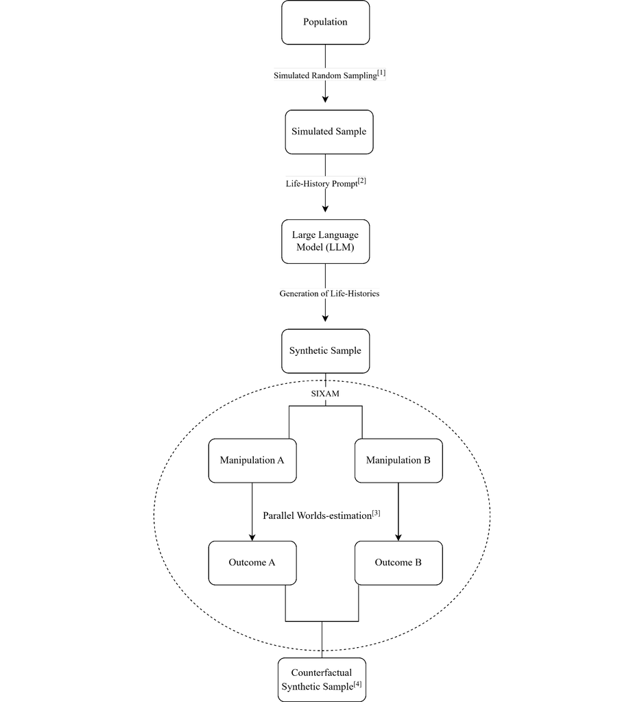

$\$

**NOTE**: Flowchart. ${}^{[1]}\!$Joint probability sampling is used to simulate relevant unit characteristics in proportion to their prevalence in the population. ${}^{[2]}\!$Simulated unit characteristics and instructions to generate a life-history are provided in a prompt to the LLM. SIXAM = **S**imultaneous and **i**ndependent e**x**ogenous **a**ssignment **m**echanism. ${}^{[3]}\!$Parallel processing is used to simultaneously, independently, and exogenously assign each synthetic unit to both manipulation conditions. With the LLM controlling the behavior of the synthetic units based on the generated life-histories, a counterfactual outcome for each manipulation condition is measured. Note that the dashed circle indicates the area of the design where the ‘parallel worlds’-estimation is implemented. ${}^{[4]}\!$Data is transposed into a long-format to account for the multiple outcome measurements of each synthetic unit.

Having outlined the SCF in this manner, there are several considerations worthy of a brief discussion. It should be noted that the reliance on generating synthetic data for causal inference is not new (e.g., Mazaheri et al. 2024). For instance, the previously mentioned *synthetic control* methodology (Abadie et al. 2010, 2015; Abadie and L’Hour 2021) serves to enable causal inference through the generation of counterfactual outcomes. This method is often used in case studies of countries and the effects of policy implementations, with the counterfactual outcome being constructed from the outcomes of other units (e.g., countries that did not implement the policy, Bilgel and Galle 2015; Birdsall 2011; Gilchrist et al. 2024; Powell 2022). While this method does provide justification for a causal interpretation and is relatively easily implemented in conventional software (e.g., Abadie et al. 2011), it does possess the same previously mentioned issues of *adjusting for observables*, since the synthetic conterfactual outcome is constructed from measured characteristics across groups in the data, leaving results possibly confounding by the failure to match on *unobservables.* Another limitation of that approach is the necessity for researchers to possess time-series data, reducing it applicability by researchers (though applicability is expanding, e.g., Abadie and L’Hour 2021; Arkhangelsky et al. 2021; Pang et al. 2022). While both methods essentially involve the inference of counterfactual outcomes, unlike the *synthetic control* method, the *Synthetic Causal Framework* (SCF) proposed here does *not* solely match on observables and does *not* require time-series data, making it more broadly applicable.

On a related note, the internal and external validity of the SCF’s reliance on LLMs may be criticized on the theoretical grounds that the generation of counterfactual outcomes essentially involves the LLM making stochastic predictions conditional on the life-history of each synthetic respondent. Implicit in such criticism is the premise that such behavior is fundamentally different from how humans behave. However, for this criticism to hold, the generation of outcomes in humans must substantively differ from synthetic respondents. That is, humans must *not* be stochastic *nor* condition their responses on their life-history. But researchers consistently assume that, and find evidence consistent with, human behavior being stochastic and conditional on their life-history (e.g., their gender, age, education, income, political affiliations, Memon et al. 2024), where every aspect of one’s identity or experiences do not matter equally, nor are they equally salient across different moments. Analogous to an LLM making a stochastic prediction of counterfactual outcomes conditional on a life-history, human respondents similarly make a guess about the outcome (e.g., their preference for a political leader) based on salient components of their life-history, which may change at a later time, for example, due to the acquirement of new experiences and information. Similarly in terms of stochasticity, when making statistical inference from data consisting of human self-report data, a common assumption is that of *random measurement error* (Gelman et al. 2021: 49-50; Levy and Mislevy 2020; Stock and Watson 2019), where any human response is characterized by some idiosyncratic and stochastic error component, and the concepts of *inter* and *intra-rater reliability* specifically serve to account for the stochasticity of human rating (Saal et al. 1980). Accordingly, an LLM predicting a preference based on the life-history and characteristics of the synthetic respondent is *not* inherently different a human respondent forming a preference based on their characteristics, life-history and context of the situation.

While these considerations arguably does lend some credence to the external validity of the SCF, it should be noted that LLMs currently do possess numerous limitations (e.g., Edyko et al. 2023; Koga and Du 2024; Lecler et al. 2023; Obaid et al. 2023; Park and Choi 2024; Saka et al. 2024; Shea and Ma 2023; Zhang et al. 2024). While future models may solve some of these issues (e.g., OpenAI 2024c), a central concern for this paper is whether results produced by *current* LLMs allow researchers to implement the SCF and expect results to generalize to human populations. To test the external validity of the SCF, and provide a proof-of-concept for how researchers can implement it, the remainder of this paper is therefore dedicated to validating the SCF against human data and assess whether its results are generalizable.

# 4 Methodology

To justify the *Synthetic Causal Framework* (SCF) empirically, as well as help researchers implement it, a *conceptual replication study* (cf. Isager et al. 2023: 2; Nosek et al. 2012: 619) is undertaken that simultaneously serves as a demonstrative proof-of-concept. This section first details that the external validity of the SCF will be validated through a large-scale replication (*n* = 1,009) of the established relationship between deservingness and welfare support (Aarøe and Petersen 2014; Kane et al. 2023; Mummolo and Peterson 2019). This involves a theoretical justification of this relationship, with the exact causal estimate to replicate being determined by conducting a *meta-analysis* (Eysenck 1995; Glass 1976; Sharpe and Poets 2020) on studies previously investigating it within the United States. The study then follows the illustrated workflow of the SCF (see figure 4.1) by implementing a joint-probability random sampling procedure to simulate random sampling from the adult population of the United States, making results expectedly more representative of that population. This is followed by specifying prompts for generating *life-histories* (cf. Bertaux 1981) and detailing code for making requests to the *gpt-4o-mini* LLM (OpenAI 2024a) using OpenAI’s API (2025a), which serve to transform the simulated respondents into *synthetic respondents*, making their expected behavior more nuanced and realistic. The novel concept of a *Synthetically Controlled Trial* (SCT) is then introduced, where the ‘parallel worlds’-estimation procedure is implemented for a simultaneous and independent exogenous manipulation of deservingness. Group balance and the simultaneity assumption are then assessed, followed by specifying the *Multilevel Bayesian Generalized Robust Linear Model* (cf. Bürkner 2017, 2018) that is used in the analysis for identifying the causal effect of deservingness on welfare attitudes.

Figure 4.1: SCF-based Replication Design

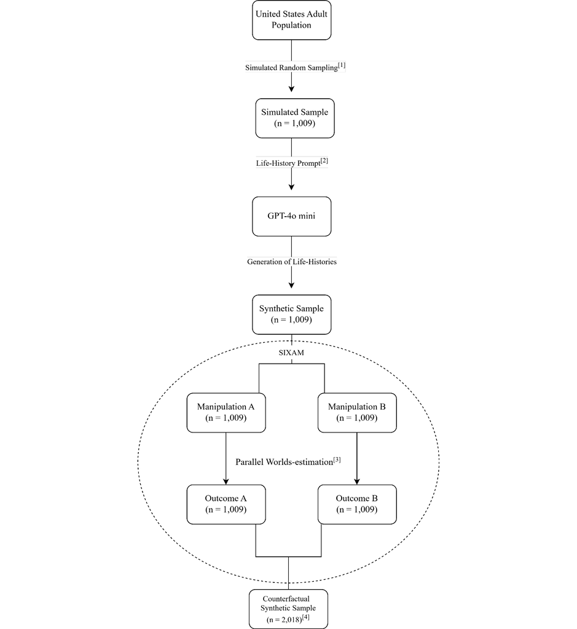

$\$

**NOTE**: Synthetic Causal Framework-flowchart. n = Sample size. ${}^{[1]}\!$Based on population estimates from IPUMS (Ruggles et al. 2024) and ANES (2021), joint probability sampling is used to simulate relevant unit characteristics in proportion to their prevalence in the population. These unit characteristics are US state of residence, area type of residence, number of children in household, sex, age, marital status, ethonoracial group, level of education, employment status, annual household gross income in 2022 US dollars, preferred political party, and political ideology. ${}^{[2]}\!$Simulated unit characteristics and instructions to generate a life-history are provided in a prompt to the API of the GPT-4o mini LLM (OpenAI 2024a). SIXAM = **S**imultaneous and **i**ndependent e**x**ogenous **a**ssignment **m**echanism. ${}^{[3]}\!$Parallel processing is used to simultaneously, independently, and exogenously assign each synthetic unit to manipulation conditions, where they are exposed to a ‘lazy’ (Manipulation A) and an ‘unlucky’ welfare recipient (Manipulation B). With the LLM controlling the behavior of the synthetic units based on the generated life-histories, a counterfactual outcome for each manipulation condition is measured, which is the support for restricting the welfare eligibility for the corresponding welfare recipient. Note that the dashed circle indicates the area of the design where the ‘parallel worlds’-estimation is implemented. ${}^{[4]}\!$Data is transposed into a long-format to account for the two outcome measurements of each synthetic unit, doubling the sample size.

Following recent recommendations for *reproducible* and *transparent* research (e.g., Alister et al. 2021; Lenz and Sahn 2021; Open Science Collaboration 2015; Peng 2011; Ritchie 2021), this study subscribes to the *open science standard* (Christensen et al. 2019; Nosek et al. 2012, 2015). This means that the study is (1) an *open project*, whose development can be followed by the public; (2) that it uses *open data*, with raw data being made freely available; and (3) that it relies on *open software* by using the free and open-source *R* programming language (R Core Team 2024) and *RStudio integrated development environment* (IDE, Posit Team 2024), which is especially suited for data science (Welbers et al. 2017: 245) and reproducible research (Krotov and Tennyson 2018: 171), with code being provided as *R* syntax in the *markdown* (Gruber 2014) version of this file. This is all made available using the [Open Science Framework](https://osf.io/) (OSF), with materials provided on the project hub: DOI: 10.17605/OSF.IO/5P3M2 (Note that data and code are *not* made available in this preview version). Similarly, for transparency and reproducibility, software specifications, used *R* packages, descriptive statistics of the data, and details not covered in the main paper are provided in the appendix.

## 4.1 Deservingness Heuristic

To assess the external validity of the SCF, that is, the generalizability of results derived from synthetic respondents to human populations, this study seeks to replicate the established relationship between deservingness and welfare attitudes (Aarøe and Petersen 2014; Kane et al. 2023; Mummolo and Peterson 2019). To understand the concepts involved in this relationship, and its usefulness for validating the SCF, a brief review of existing theory and results is provided.

The relationship between deservingness and welfare attitudes is founded in *evolutionary psychology* (Buss 2019), where substantial parts of human behavior are considered the product of *evolution by natural selection* (Darwin 1998; Futuyma and Kirkpatrick 2023). In this view, the three essential components of evolution - *genetic variation*, *inheritance* and *differential reproductive success* (Buss 2019: 7) - has lead to the human genome adapting physically, psychologically, and socially to the conditions of the environment (Buss 2009, 2019; Dawkins 1976; Elster 2007). With evolution by natural selection operating mostly at a slow pace, the human genome is generally considered adapted to an environment characteristic of a *hunter-gatherer society* (Buss 2019; e.g., Boyer and Petersen 2018; Van Prooijen and van Vugt 2018), meaning that it is mostly *not* adapted specifically for the modern society. In the long run, evolution produces adaptations useful for a particular environment, but these adaptations are *not necessarily* optimal and can prove disadvantageous across different environments (Boyer and Petersen 2018; Buss 2019; Li et al. 2018; Sperber and Hirschfeld 2004). While some of these adaptations have lead to *predispositions* for different types of behavior that vary across individuals (e.g., Claessens et al. 2020; Hibbing et al. 2019; Oxley et al. 2008; though see Bakker et al. 2020; Osmundsen et al. 2022), others are posited to produce mostly invariant predispositions in the form of *cognitive modules* in the brain (Kurzban and Aktipis 2007; Sperber and Hirschfeld 2004) that operate subconsciously, automatically, and mandatory (Cosmides et al. 2003: 173). Being specialized for making cost-efficient computational operations that affect our behavior by serving as decision heuristics (Kurzban and Aktipis 2007; Sperber and Hirschfeld 2004; e.g., Boyer and Petersen 2018; Pietraszewski et al. 2015), such modules are closely related to *System I* intuition-based thinking (Kahneman 2024; e.g., Haidt 2013; Haidt and Joseph 2004). It should be noted that while cognitive heuristics are generally theorized as being universal and thus *invariant* across populations, they are *not necessarily* utilized to the same extent across individuals (e.g., Aarøe et al. 2017), and like other predispositions (Hibbing et al. 2019: 26), they do *not* determine behavior in a *monocausal* manner, since biological and social phenomena likely interact (e.g., Hinsz et al. 2013). With cognitive modules functioning involving processes spanning different brain regions (Kurzban and Aktipis 2007; Sperber and Hirschfeld 2004), they are physical constructs, and similar to how other cognitive modules can become defunct due to a neurological disorder (e.g., people with *prosopagnosia* cannot recognize faces, Buss 2019: 253), some individuals may *not* possess *nor* be affected by a cognitive heuristic.

Since humans are social creatures and depend on cooperation with others to improve their reproductive success, this has lead to the development of social groups (Buss 2019), and cognitive modules on how to assess ingroup and outgroup members likely evolved to solve issues with whom to cooperate and how to redistribute goods (Fong et al. 2006). One such cognitive module has been denoted the *deservingess heuristic* (Aarøe and Petersen 2014; Petersen et al. 2011, 2012; Petersen 2012), and researchers state that it ‘influences everyday judgments about interpersonal help giving’ and ‘constitutes a key psychological basis for judgments about political help giving; that is, social welfare’ (Aarøe and Petersen 2014: 686). Consistent with related research (Feather 1999; Gilens 2000; Larsen 2006; Skitka and Tetlock 1993; van Oorschot 2000; Weiner 1995), this means that the deservingness heuristic assesses whether members are ‘deserving’ or ‘underserving’ of being redistributed goods (Aarøe and Petersen 2014: 686). An individual being assessed as ‘low in deservingness’ can, for example, occur because they enjoy the benefits of the goods while being ‘unwilling to invest effort to improve their circumstances’ (Aarøe and Petersen 2014: 687). By comparison, an individual may be assessed as ‘high in deservingness’ because they are ‘making an effort and trying but failing due to forces beyond their control’ (Aarøe and Petersen 2014: 687), which indicate that the perceived effort of a person is central in assessing their deservingness. The deservingness heuristic, similar to other heuristics, likely operates in an automatic and subconscious manner (Petersen et al. 2011) by regulating emotions (cf. Al-Shawaf et al. 2015), producing a behavioral response (e.g., a political attitude) by evoking a positive emotion for individuals deemed high in deservingness and a negative emotion for individuals low in deservingness (Petersen et al. 2012), which in turn affect political support toward welfare policies. Based on numerous studies across cultures (e.g., Aarøe and Petersen 2014; Appelbaum 2002; Meyer and Mulherin 1980; Petersen et al. 2012; Weiner 1995), the deservingness heuristic is likely a cognitive module universally shared across the human population due to the common issues of group cooperation (e.g., *free-riding*, Delton et al. 2012). Since cognitive heuristics are cost-efficient, they can make suboptimal evaluations due to relying on sparse information, and consistent with numerous studies (Allport 1954; Bodenhausen and Lichtenstein 1987; Macrae et al. 1994), researchers argue that it can operate simply through *stereotypes* (Aarøe and Petersen 2014: 687), which are defined as ‘beliefs about the characteristics, attributes, and behaviors of members of certain groups’ (Hilton and von Hippel 1996: 240; cited in Aarøe and Petersen 2014: 687). This ties directly into the perceived effort of a person and means that the deservingness of a welfare recipient can be determined simply based on how much they resemble a stereotypical depiction of a ‘lazy’ or ‘unlucky’ welfare recipient (cf. Aarøe and Petersen 2014; Petersen et al. 2012). Taken together, the deservingness heuristic operates by taking in sparse information about individuals (e.g., ‘lazy’ and ‘unlucky’ stereotypes) and computes an affective response that exacts a causal effect on political support for social welfare policies. For an illustrative view, the operations of the deservingness heuristic underlying the relationship between deservingness and welfare attitudes are provided as a *directed acyclic graph* (DAG, Pearl 1988, 1993, 1995) in figure 4.2. Note that much of the aforementioned research is also somewhat consistent with *evolution by cultural selection* (cf. Dawkins 1976; Sperber 1976), since the deservingness heuristic could in principle be a learned heuristic universally shared across cultures, similar to numerous other cognitive heuristics stipulated to be social constructions (e.g., Kuklinski and Quirk 2000; Lau and Redlawsk 2001).

Figure 4.2: Relationship Between Deservingness & Welfare Support

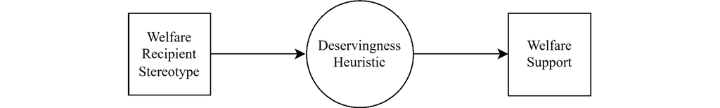

$\$

**NOTE**: *Directed Acyclic Graph* (DAG, Pearl 1988, 1993, 1995). Theorized causal relationship based on (Aarøe and Petersen 2014).

The relationship between deservingness and welfare attitudes has been directly replicated across numerous studies (Aarøe and Petersen 2014; Kane et al. 2023; Mummolo and Peterson 2019). Since these are *direct replications* (cf. Isager et al. 2023: 2; Nosek et al. 2012: 619), they rely on highly similar methods, and for brevity, this review will only present the design of the original (i.e., Aarøe and Petersen 2014). In the original study, Lene Aarøe and Michael Bang Petersen (2014: 688) rely on cross-national, representative samples from the United States (US, *n* = 1,009) and Denmark (*n* = 1,006). Here, they employ a *experimental survey design* (cf. Gaines et al. 2006) containing three manipulation conditions, with the manipulations being validated text-based vignettes containing deservingness-cues in relation to a ‘lazy’, ‘unlucky’, and a ‘control’ welfare recipient[^17] (Aarøe and Petersen 2014: 689; also used in Petersen et al. 2012). Survey participants are assigned to view either one of these vignettes using the aforementioned *random assignment mechanism* (RAM) characteristic of *randomized controlled trials* (RCTs, Coover and Angell 1907; Peirce and Jastrow 1885; Woodworth and Thorndike 1901), which together with its reliance on stratified random and representative samples (Aarøe and Petersen 2014: 688) means that their study is here considered capable of providing *reliable* causal inference. The theorized welfare support outcome is operationalized as political support for tightening the requirements for welfare eligibility of the shown welfare recipient: ‘To what extent do you *dis*agree or agree that the eligibility requirements for social welfare should be tightened for persons like him?’ (Aarøe and Petersen 2014: 689, emphasis in original), with the response being measured using a 7-point *Likert* (Likert 1932) *response scale*, ranging from ‘Strongly disagree’ to ‘Strongly agree’. They consider relevant demographics to include gender, age, and education (Aarøe and Petersen 2014: 689), and they use Frequentist multiple linear models, estimated using *ordinary least squares* (OLS, Aarøe and Petersen 2014: 691), with all ‘Don’t know’-responses being excluded from the analysis (Aarøe and Petersen 2014: 689). By comparison, the replications do *not* include the ‘control’-vignette and solely rely on US-based samples, with Kane et al. (2023) relying on a sample size of 805, while Mummolo and Peterson (2019) conduct two separate replications, with sample sizes of 1,874 and 5,550. To leverage these direct replications, focus will be on the ‘lazy’ and ‘unlucky’ conditions and the results specific to the US. In all three studies (Aarøe and Petersen 2014; Kane et al. 2023; Mummolo and Peterson 2019), they identify the effect of deservingness on welfare support as positive and *statistically discernible*[^18] from zero with 95% confidence (see the respective estimates in table 10.1 in the appendix).

To arrive at the specific causal estimate to replicate, a *meta-analysis* (Eysenck 1995; Glass 1976; Sharpe and Poets 2020) is conducted using the estimates provided by these studies[^19] (i.e., Aarøe and Petersen 2014; Kane et al. 2023; Mummolo and Peterson 2019), which can be considered the ‘platinum standard’ of science (Pedersen and Stritch 2018: 606), since it combines the results from each study to produce a more robust uncertainty-weighted average estimate. This exploited the numerous advantages of *Bayesian inference* (Gelman et al. 2014; Heck 2019; Kruschke 2010; Levy and Mislevy 2020; McElreath 2019; Wagenmakers et al. 2010) by employing a *multilevel Bayesian model* (cf. Bürkner 2017, 2018; e.g., Maier et al. 2022). This used the `brms` *R* package (Bürkner 2017, 2018) to implement the *No-U-turn* algorithm (NUTS, Hoffman and Gelman 2014) for the *Hamiltonian Markov-Chain Monte Carlo* procedure (Duane et al. 1987; Neal 1993, 2011), implemented in the probabilistic software *STAN* (Stan Development Team 2024), to efficiently draw 40,005 samples from the posterior using 7 independent sampling chains, with 2,000 warmup samples being drawn in advance. This produced an estimated uncertainty-weighted average effect of .44 (SD = .12; $BF_{1,0}$ = 22.37; 95% HDI[.12; .61]; $\hat{R}$ = 1.00; ESS = 5,553; MCSE = .00; Prior = $\mathcal{T}_3$(.00, .08); for an explanation of these metrics, see the ‘Bayesian inference’ and ‘Analysis’-sections), which indicates a positive effect of deservingness on welfare support that can be considered discernible from zero with 95% credibility (see the appendix for model formalization, diagnostics, and posterior distributions). As generally recommended by King et al. (2000), these results can be more meaningfully interpreted as the following: *Ceteris paribus*, compared to being exposed to a ‘lazy’ welfare recipient (i.e., someone low in ‘deservingness’), individuals exposed to an ‘unlucky’ welfare recipient (i.e., someone high in ‘deservingness’) are on average 43.92 *percentage-points* (*pp*) more supportive of allowing the recipient to receive welfare support at the current requirements for welfare eligibility, plus or minus 11.88 *pp*, and with 95% credibility between 12.24 *pp* and 61.41 *pp*.

An advantage of this Bayesian approach (Kass and Raftery 1995; Raftery 1995) is the ability to compute *posterior odds* (i.e., $\dfrac{Pr(H_\alpha \ne 0 \ | \ D)}{Pr(H_\alpha = 0 \ | \ D)}$) from the *likelihood odds* (i.e., $\dfrac{Pr(D \ | \ H_\alpha \ne 0 )}{Pr(D \ | \ H_\alpha = 0)}$) and the *prior odds* (i.e., $\dfrac{Pr(\ H_\alpha \ne 0)}{Pr(H_\alpha = 0)}$) for the estimated parameters (e.g., $\alpha$) using *Bayes theorem* (cf. Bayes and Price 1763; Laplace 2009[1814]; McElreath 2019: 36-39) as shown in equation 1.8:

| $\dfrac{Pr(\ H_\alpha \ne 0 \ \| \ D)}{Pr(H_\alpha = 0 \ \| \ D)} = \dfrac{Pr(D \ \| \ H_\alpha \ne 0 )}{Pr(D \ \| \ H_\alpha = 0)} \times \dfrac{Pr(H_\alpha \ne 0)}{Pr(H_\alpha = 0)}$ | 1.8 |
| --- | --- |

With the likelihood odds also known as the *Bayes factor* (BF, Kass and Raftery 1995; Raftery 1995), this statistic can be computed from Bayesian models by exploiting the *Savage-Dickey density ratio* (see Heck 2019; Makowski et al. 2019a; 2019b; Wagenmakers et al. 2010). Then, by assuming prior odds of 1, implying that a non-zero hypothesized parameter is *a priori* as likely as a hypothesized zero parameter[^20] (i.e., $\dfrac{Pr(\ H_\delta \ne 0)}{Pr(H_\delta = 0)} = 1$), the BF simplifies to the *posterior odds* (i.e., $\dfrac{Pr(\ H_\delta \ne 0 \ | \ D)}{Pr(H_\delta = 0 \ | \ D)} = \dfrac{Pr(D \ | \ H_\delta \ne 0)}{Pr(D \ | \ H_\delta = 0)} \times 1 = BF$, Wagenmakers et al. 2010: 165). This metric is particularly useful, because it addresses the limitations and criticisms of the *p*-value (e.g., American Statistical Association 2016; Cohen 1994; Johnson 1999; Kruschke 2010; Wagenmakers et al. 2010), which is directly illustrated by taking the exponent of the $ln(BF)$ provided in the results, and assuming prior odds of 1, one can state that the hypothesized effect of deservingness on welfare support is 22.37 times more probable than the hypothesis of no effect given the data. Following guidelines by Adrian E. Raftery (1995), the relative evidence provided by the BF can then be interpreted to indicate ‘strong evidence in favour of’ the hypothesized relationship between deservingness and welfare support given the data.

Since a Bayesian model relies on the specification of prior distributions for each parameter which may inadvertently bias results if they are ‘strongly informative’ relative to the data (Gelman et al. 2021: 123-127; Gelman et al. 2014: 55-56), to assess robustness, a *multilevel Frequentist meta-analysis* (Viechtbauer 2010) is also conducted by employing a model using *restricted maximum likelihood* (REML, Patterson and Thompson 1971). For inference, this exploited a *Student t-parametric bootstrap* (Efron and Tibshirani 1994) with an equivalent 40,005 permutations to increase comparability with Bayesian estimates. To compute summary statistics, contrary to the Bayesian results (cf. McElreath 2019: 197), this relied on Frequentist *estimators* (cf. Fisher 1970; Stock and Watson 2019; Wooldridge 2019), such as biased-reduced estimators of *standard error* (SE, Park et al. 2022; Park and Wang 2020, 2022) and *bias-corrected and accelerated* (BCa) confidence intervals (Efron 1987; Makowski et al. 2019a). This yielded a similar estimated SE-weighted average effect of .50 (SE = .06; 95% BCa[.38; .62]), which for practical purposes can be interpreted similar to the Bayesian estimates (though for the interpretive differences, see, e.g., Clayton 2021). While the *overlap* (Makowski et al. 2019a) between the Bayesian posterior distribution and the Frequentist parametrically-bootstrapped (maximum) likelihood distribution is relatively moderate (67.92%), the exact difference is -.06 (SD = .13; 95% HDI[-.41; .16]), which indicates that, while the Bayesian approach produces a lower, and thus more conservative, estimated average effect, the difference is indiscernible from zero with 95% credibility. As such, the priors used in the Bayesian model can be considered ‘weakly informative’ in their influence on the estimated parameters, and the specific causal estimate to replicate will be the Bayesian estimates.

Having outlined both the theory, design, and effect pertaining to the relationship between deservingness and welfare attitudes, the reason for assessing the external validity of the SCF by replicating specifically these results can be made clear. Since the relationship is founded in the concept of the deservingness heuristic (Aarøe and Petersen 2014; Petersen et al. 2011, 2012; Petersen 2012), which is essentially a computational algorithm for making decisions on support for welfare policies, consistent with *functionalist psychology* (Farrell 2014: 88, 111, 398-403), it is likely that LLM-based simulated behavior would be capable of mimicking the *functionality* of this cognitive module because the neural networks underlying these models mimic the neural structure of the human brain (cf. OpenAI 2024a; 2024b; 2024c; 2022; Ornstein et al. 2024). Since the input for the deservingness heuristic has been demonstrated to be expressible entirely as text-based vignettes (Aarøe and Petersen 2014; Petersen et al. 2011, 2012), the manipulation conditions meaningfully fit with the input-format of LLMs. Similarly, all LLMs trained on a large enough repertoire of text-based expressions of everyday human behavior (e.g., most of OpenAI’s GPT-models, cf. OpenAI 2024a; 2024b; 2024c; 2022; Ornstein et al. 2024) can be expected to have been trained on data reflecting stereotypes, specifically those relating to welfare recipients, which would likely occur in relation to expressions of support for welfare policies targeting these stereotypes. With the *gpt-4o-mini* LLM by OpenAI (2024a) being one such model that simultaneously manages to be comparatively cost-efficient (costing on average 0.375 US-dollars per 1 million tokens at the time of writing) and capable in terms of producing high-quality outputs, the validation of the SCF will rely on this model. Another consideration in using this phenomena to validate the SCF is that since the human-based studies rely on random sampling and experimental designs (Aarøe and Petersen 2014; Kane et al. 2023; Mummolo and Peterson 2019), the causal estimates can be considered reliable, and with multiple *direct* replications confirming the initial results (i.e., Kane et al. 2023; Mummolo and Peterson 2019), the ability to combine these in a meta-analysis without having to worry about pooling together too different studies (cf. Ioannidis 2016; Sharpe 1997; see also general criticisms by Data Colada 2022a; 2022b; 2022c; 2022d), this provides a rather robust estimate of the effect to compare the SCF against. The specific choice of assessing the external validity of the SCF against the relationship between deservingness and welfare attitudes can thus be considered meaningful and reliable, though it should be noted that any one single assessment is inadequate to robustly conclude that the SCF is externally valid.

With these considerations in mind, the current direct replication study will draw on the theory and existing results pertaining to the deservingness heuristic (Aarøe and Petersen 2014; Kane et al. 2023; Mummolo and Peterson 2019) to specify the expectation that support for the social welfare eligibility of recipients is higher when the recipient is perceived as high in deservingness compared to recipients perceived as low in deservingness, which is formalized as the following hypothesis:

**$H_1$: Support for welfare eligibility is higher for deserving welfare recipients compared to undeserving welfare recipients.**

Given the previously outlined theoretical foundation of the SCF, and the consideration that an investigation of the deservingness heuristic in relation to synthetic units could be meaningful and reliable, it will be expected that the estimated causal effect of deservingness on welfare eligibility does *not* differ between human-based and synthetic-based studies, formalized as:

**$H_2$: The effect of deservingness on welfare eligibility is the same whether measured among synthetic respondents or human respondents.**

Considering these two hypotheses, the subsequent sections will demonstrate how to simulate representative data of the US-population through the use of joint probability random sampling, followed by the introduction of the *Synthetically Controlled Trial* (SCT), which will emulate the survey conditions of the original survey and rely on vignettes to operationalize a manipulation of deservingness through text-based descriptions of a ‘lazy’ and ‘unlucky’ welfare recipients.

## 4.2 Simulating Data

As previously mentioned, simulating data allows the researcher to decide which characteristics the LLM should base its life-history and responses on. While the selected gpt-4o-mini LLM by OpenAI (2024a) is expectedly capable of inferring characteristics proportional to a population by basing them on their prevalence in its training data, explicitly determining the characteristics gives the researcher more control over the characteristics generated, which could impact the behavior of the synthetic respondents and how generalizable results are to the population of interest. Similarly, while it can be expected that the greater the number of simulated characteristics, the more realistic the behavior of the LLM, specifically which and how many characteristics to simulate will likely vary depending on characteristics found relevant for the particular research topic and the ability of the selected LLM to retain and process information. For this demonstration, the common demographics (e.g., ANES 2021; Ruggles et al. 2024) of US State residence, area residence type, number of children in household, sex, age, marital status, ethnoracial group[^21], highest level of education, employment status, and annual household gross income ($US) will be simulated, which includes the demographic characteristics deemed relevant by Aarøe and Petersen (2014), and this will likely provide gpt-4o-mini with plenty of realistic information from which to generate the life-histories. Furthermore, since the results from Aarøe and Petersen (2014), Mummolo and Peterson (2019), and Kane et al. (2023) relate specifically to *political* attitudes toward welfare requirements, the characteristics of preferred political party and political ideology will also be simulated.

Simulating characteristics can be done so that their prevalence in the data is proportional to a national population of interest. Since this demonstration focuses on replicating the results from Aarøe and Petersen (2014), Mummolo and Peterson (2019), and Kane et al. (2023), the population of interest is determined to be the adult population of the United States of America (US). A population-proportional simulation of characteristics can be achieved by constructing a *stratification matrix* using large samples such as those that form the basis of census data (cf. Gelman and Little 1997). A stratification matrix consists of every combination of the characteristics of interest and their frequency in the population, and a US-based version can be constructed using [US Census Bureau](https://www.census.gov/) data provided by the *IPUMS* (Ruggles et al. 2024). Here, the 2022-wave is used due to being relatively contemporary, containing measures of most characteristics to simulate (i.e., US State residence, area residence, number of children in household, sex, age, marital status, ethnoracial group, highest level of education, employment status, and annual household gross income in 2022 US dollars) and a large sample size ($n$) of 3,373,378 respondents, which after data cleaning (e.g., removing missing values and respondents less than 18 years old) results in 2,403,591 usable observations. However, the data lacks measures of political party affiliation and political ideology, meaning that these measures will have to be *imputed* (Kalton and Kasprzyk 1982; King et al. 2001; Rubin 1988).

To impute the measures of political party affiliation and political ideology, data from the similarly recent 2020-wave of the *American National Election Survey* (ANES 2021) can be used. While the ANES relies on samples substantially smaller than the IPUMS ($n$ = 8,280), it is also contemporary and contains similar measures of all characteristics to simulate. The subset of the ANES of all these characteristics can be used to train statistical models to impute political party and ideology, which necessitates recoding all variables to have the same categories and scale across the IPUMS and ANES. To leverage as much data from the ANES as possible, missing values were imputed (range: 12 - 3,700) with the *multiple imputations by chained equations* procedure (MICE, van Buuren and Groothuis-Oudshoorn 2011), using the *random forest* algorithm (Breiman 2001; Ho 1995; Liaw and Wiener 2002) due to its generally high accuracy, non-parametric nature, and ability to handle both categorical and continuous data. This involved 121 imputation iterations, which was estimated as the number of iterations necessary for *chain convergence* (cf. von Hippel 2020). Having undertaken data cleaning similar to the IPUMS data prior to imputation (e.g., removing respondents less than 18 years old), this results in one imputed ANES sample of 6,568 usable observations.

Following then the methodology of *cross-validation* (Stone 1974), an unbiased measure of the *imputation accuracy* of statistical models can be derived by splitting the ANES data into a train and test dataset, using the conventional 80/20 split ratio (e.g., França et al. 2024), training the models on the *training data* and testing their imputation accuracy on the *testing data*. To assess variability in imputation accuracy, *Bootstrapped cross-validation* (Xu and Liang 2001) is used, which here involves iteratively splitting, training, and testing models a total of 10 times. To impute respondents’ dichotomously-coded preferred political party, a *varying-intercepts Bernoulli* model (Gelman and Hill 2007) and a *Random Forest* model (Breiman 2001; Ho 1995; Liaw and Wiener 2002) are compared. From their predictions, a *confusion matrix* (Tharwat 2018) is generated, with imputation accuracy being computed as the equally-weighted arithmetic mean of the *total accuracy* (ACC), *sensitivity* (i.e., *recall*) and *specificity* (Yerushalmy 1947), *positive predictive value* (PPV; i.e., *precision*) and *negative predictive value* (NPV) (Altman and Bland 1994), which are popular, complementary metrics of model accuracy. The average imputation accuracy of the varying-intercepts Bernoulli model is 66%, with a *standard deviation* (SD) of 1 percentage points (*pp*), while the Random Forest model has an imputation accuracy of 65% (SD = 1*pp*), meaning that the varying-intercepts Bernoulli model is chosen to impute political party in the IPUMS data due to its (marginally) superior accuracy. Imputing political ideology, which due to its Likert (1932) scale could be treated either as an ordered or (less appropriately) as a continuous variable (cf. Lantz 2013; Wu and Leung 2017), involves a *varying-intercepts Gaussian* model (Gelman and Hill 2007), a *Generalized Additive Model* (GAM, Hastie and Tibshirani 1990; Wood 2004, 2011, 2017), and a Random Forest model (Breiman 2001; Ho 1995; Liaw and Wiener 2002). These are similarly evaluated, though given its non-dichotomous coding, only ACC is used to measure imputation accuracy. These models produce an ACC of 30% (1*pp*), 30% (1*pp*), and 43% (1*pp*), respectively, resulting in the Random Forest model being chosen to impute political ideology for its superior accuracy. While the imputation accuracies of both political party affiliation and political ideology can be considered relatively high, they are far from an accuracy of 100%, meaning that these imperfectly imputed values may make the resulting stratification matrix less reliably representative of the adult US population.

Having imputed preferred political party and political idelogy in the IPUMS data, all chosen characteristics are available, and a stratification matrix is generated by counting the frequency of every combination of the characteristics (*n* = 2,366,924). Then, analogous to a *non-parametric bootstrap* (Efron 1979, 2003), simulating data can done by sampling with replacement from the stratification matrix, with the sampling probability being the frequency of each combination of characteristics. This aforementioned joint probability procedure for simulated random sampling ensures that the value of each characteristic is simulated conditionally on the values of all the other characteristics (e.g., *P(sex = Male | State = Tennessee, Age = 65, Political Ideology = Conservative)*), making the resulting data more closely reflect the proportionality of characteristics in the US population. Asymptotically, data simulated in this manner is representative of the national population of interest, and for smaller datasets that nonetheless are unrepresentative, the *multilevel regression and poststratification* (MRP, Gelman and Little 1997) method may alternatively be used to adjust for such sample-population imbalances. With this US-based stratification matrix available, a sample can then easily be generated. For the purposes of this demonstrative replication, the sample size of the original study is used (Aarøe and Petersen 2014: 688), which entails a relatively large sample size of 1,009 simulated respondents being generated. Given that the aforementioned ‘parallel worlds’-estimation is here used to produce two counterfactual outcomes for each respondent (see below), this results in an effective sample size of 2,018. With regards to successfully replicating the aforementioned effect size of .44 (SD = .12; 95% HDI[.12; .61]), a *false-positive error rate* ($\epsilon_{\alpha}$, i.e., *Type I error*) of 5% is specified *a priori*, which together with 4 fixed model parameters (i.e., intercept mean, intercept standard deviation, coefficient, and the model degrees of freedom, see model in the ‘Bayesian inference’-section), the *false-negative error rate* ($\epsilon_{\beta}$, i.e., *Type II error*) is estimated to be 4.14%. This means that the study has an estimated *statistical power* (Gelman and Carlin 2014) of 95.86%, which can be considered more than ‘adequate’ for replicating the existing results (cf. Cohen 1988, 1991). Similarly, the *type M error rate* ($\epsilon_{M}$, Gelman and Carlin 2014) is 1.03, meaning that the effect is unlikely to be substantially under-/overestimated (i.e., the exaggeration rate is only 3%), while the *type S error rate* ($\epsilon_{S}$, Gelman and Carlin 2014) is .00%, indicating almost no probability of the estimate having the wrong sign. As such, the probability of a successful replication is high, at least as indicated by these metrics.

Table 4.1: Examples of the Simulated Dataset

| State | Area | Children | Sex | Age | Marital Status | Ethnoracial Group | Education | Employment Status | Household Income | Political Party | Political Ideology |
| --- | --- | --- | --- | --- | --- | --- | --- | --- | --- | --- | --- |
| Kentucky | Small Town Or Surburb | 0 | Female | 62 | Not Married | Black/African American | Some Post-High School, No Bachelor’s Degree | Not In Labor Force | 10,980 | Democratic Party | Moderate; Middle Of The Road |
| Kansas | Small Town Or Surburb | 0 | Female | 59 | Divorced | White | Graduate Degree | Employed | 42,700 | Democratic Party | Slightly Liberal |
| North Carolina | Small Town Or Surburb | 0 | Female | 53 | Widowed | White | Some Post-High School, No Bachelor’s Degree | Employed | 25,200 | Republican Party | Conservative |
| California | Small Town Or Surburb | 1 | Female | 49 | Married | Mexican | Less Than High School Credential | Not In Labor Force | 60,600 | Democratic Party | Moderate; Middle Of The Road |
| Virginia | Small Town Or Surburb | 0 | Female | 52 | Married | White | Bachelor’s Degree | Employed | 100,200 | Democratic Party | Liberal |
| Minnesota | Small Town Or Surburb | 0 | Female | 65 | Married | White | Graduate Degree | Not In Labor Force | 141,400 | Democratic Party | Liberal |

**NOTE**: Randomly-sampled rows from the simulated data. n = 1,009. ‘Ethnoracial group’ is a term used to denote the overlapping racial/ethnic/national terminology employed in the US (e.g., ‘White’, ‘African-American’, ‘Chinese’, etc.). Household income is provided as annual household gross income in 2022 US dollars ($). Based on data by the IPUMS (Ruggles et al. 2024) and ANES (2021).

Simulating the data in this manner produces a 1009 $\times$ 13 matrix, with randomly-determined examples of simulated units being provided in table 4.1. The simulated data contains an identification number (`id`, omitted from table 4.1) and the 12 measures of the selected characteristics of each simulated respondent: Their US state of residence (e.g., ‘Maine’, ‘Vermont’, ‘Florida’), area residence type (e.g., ‘City’, ‘Rural Area’, ‘Small Town Or Surburb’), number of children (range: ‘0’ - ‘4 Or More’), sex (i.e., ‘Female’, ‘Male’; 52.82% females), age (mean: 51.72; SD = 18.53; range: ‘18’ - ‘95’), marital status (e.g., ‘Not Married’, ‘Widowed’, ‘Divorced’), ethnoracial group (e.g., ‘Chinese’, ‘Bangladeshi’, ‘Ecuadorian’), level of education (range: ‘Less Than High School Credential’ - ‘Graduate Degree’), employment status (e.g., ‘Not In Labor Force’, ‘Employed’, ‘Unemployed’), annual household gross income in 2022 US dollars ($) (median: 82,000; IQR = 99,000; range: ‘-6,910’ - ‘1,360,000’), preferred political party (i.e., ‘Democratic Party’, ‘Republican Party’; 53.72% democrats), and political ideology (range: ‘Extremely Liberal’ - ‘Extremely Conservative’). For more details and greater overview of the simulated data, descriptive statistics are provided both metrically and graphically in the appendix.

On average, the sample is estimated to capture 97.69% (SD = 6.29*pp*) of the information in the US population in relation to the specified characteristics[^22], and comparisons of the sample distributions with US population estimates reveals that the sample could generally be considered representative on all measured demographics. Compared to the nationally representative sample used by Aarøe and Petersen (2014: 688), which employed stratified sampling, the two samples differ by this simulated data including an age range up to 95 compared to their age range up to 70. Possibly as a result of this, the mean age of their sample is 41.1 years, while it is 51.7 here. Also, the ratio of females is in their sample 51%, while it in this simulated sample is 52.8%. As such, while the sample of Aarøe and Petersen (2014) is relatively younger, based on the characteristics described in their materials, there are no substantial differences between the samples, meaning that this sample can be considered comparatively representative. This representativeness of the sample is likely attributable to the relatively large nominal sample size (*n* = 1,009) and the joint probability procedure used to generate it. With this simulated data now having been generated, OpenAI’s (2024a) gpt-4o-mini can then be used to generate their life-histories.

## 4.3 Generating Life-Histories

With simulated data available, a *prompt* can be engineered, which serves as an input that instructs the LLM to generate life-histories for the respondents. As mentioned, a *life-history* (Bertaux 1981) can be considered an autobiographical narrative by which individuals frame their life, experiences, identity, relationships, existential purpose and place in society (e.g., Znaniecki and Thomas 2020[1974]), and their purpose here is to provide more character and nuance to the simulated respondents in a way that goes beyond their assigned characteristics. This will expectedly help the LLM respond in a manner that is consistent with a human possessing the assigned characteristics. Writing a prompt that instructs the LLM to generate the life-history based on the assigned characteristics helps ensure that other characteristics generated in the life-history are functions of the explicitly determined characteristics. The prompt engineered for this specific purpose, with examples of characteristics specific to a randomly-sampled simulated unit is provided in table 4.2.

Table 4.2: Life-History Prompt

| id | Prompt |
| --- | --- |
| 495 | You are to act as a character and must remain in character for the purposes of a roleplay scenario. ‘You’ and ‘your’ thus refer to your character from now on. Your character has the following characte… |

**NOTE**: Example of a prompt engineered to generate a life-history. The characteristics in the prompt are based on data by the IPUMS (Ruggles et al. 2024) and ANES (2021).

The prompt specified here for generating life-histories instructs the gpt-4o-mini LLM (OpenAI 2024a) to act as a character and to persistently remain in character. This serves to ensure that all output generated by the LLM reflects behavior consistent with that character. It also contains a list of all the assigned characteristics, followed by a request for it to generate a (brief) life-history based on these characteristics. While an increase in the number of provided characteristics and the request of a longer life-history will expectedly result in behavior that more realistically reflects a human possessing these traits, this likely comes at the cost of greater financial costs and time needed by the LLM to process the input and generate an output. An advantage of relying on the API of GPT-models by OpenAI is that researchers can control numerous parameters of the model. For example, the *[max length](https://platform.openai.com/docs/api-reference/chat)* (i.e., `max_tokens`) parameter can be restricted to reduce costs (OpenAI 2025a), though this will likely reduce its ability to act in a manner consistent with its assigned characteristics. What constitutes an ‘optimal’ max length will expectedly vary across different research purposes, depending in part on the number of relevant characteristics from which the LLM is to generate life-histories. For this demonstration the `max_tokens` for generating life-histories is set to 500, which is found to be adequate within this context, since the LLM can generate life-histories within this limit without its output being truncated due to exceeding the limit. Another relevant parameter is the *[temperature](https://platform.openai.com/docs/api-reference/chat)* of the LLM’s output (i.e., `temperature`), which determines the randomness of the output (OpenAI 2025a). A higher value makes its output adhere less to language syntax, making its output less cohesive and meaningful. The default value outlined by OpenAI is `1`, and while an optimal value will likely vary across contexts, a text analysis of the generated life-histories (see below) found this value to be adequate for the context of generating realistic life-histories.

To generate life-histories from the simulated data, it is recommended to use the *gpt-4o-mini* LLM through [OpenAI’s API](https://platform.openai.com/docs/api-reference/introduction) (OpenAI 2025a). As mentioned, gpt-4o-mini is among the best-performing and cheapest models (OpenAI 2024a; 2025b), with a hallucination rate as low as 1.7% and factual consistency rate of 98.3% (Vectara 2025), indicating that the model is generally reliable. Making requests through OpenAI’s API is preferred, since data generated in this way are not used to train their models, and in terms of privacy, such data is generally deleted after 30 days (OpenAI 2024d). This helps reduce concerns that studies such as this could inadvertently train the model, leading to results more consistent with researcher preferences rather than human behavior, which would result in tautological results. Compared to manually generating life-histories, calling the API using software exponentially speeds up the process and is easily done through *R* in RStudio. To this end, this demonstration relies on the `openai` *R* package (Rudnytskyi 2023) because of its ease in making such API requests. Due to the speed of such software, it is furthermore recommended to enforce pauses between calls to the API to reduce traffic, which can stress their systems. OpenAI already enforces [rate limits](https://platform.openai.com/docs/guides/rate-limits) (OpenAI 2025a), and to avoid unintentionally hitting one of their numerous request limitations, the researcher can *a priori* enforce a pause between requests. This demonstration uses a relatively substantial pause of 3.1 seconds to avoid hitting rate limits, though values could vary depending on the number and length of requests.

This demonstration implements and recommends that LLM-output is generated through separate requests, one for each simulated respondent, to ensure that observations are *independent*. An alternative to this procedure is *[batching](https://platform.openai.com/docs/api-reference/batch)*, which involves grouping multiple requests together into a single request (OpenAI 2025a). For example, by providing the characteristics of several simulated respondents in the same prompt and asking for multiple life-histories. While this can reduce both financial and time costs, a serious methodological concern of batching is that generating life-histories (and most other types of outcome) in batches produces output that may be *interdependent*, which typically is *not* desirable. For example, output generated in batches may be more strongly correlated than output generated in other batches or output generated individually. This would violate the common statistical assumption of observations being *independent and identically distributed* (*iid*, Gaenssler and Stute 1979; McElreath 2019: 81), which would likely need to be accounted for using statistical modeling (e.g., *multilevel models*, Gelman and Hill 2007). Furthermore, when generating the outcome across different group conditions using batching, there may be information *spill-over*, for example, if the LLM in generating a counterfactual output mistakes a unit in one manipulation condition with a unit in another manipulation condition, or if the mere presence of information relating to both group conditions affects the generation of results. This spill-over would violate the aforementioned fundamental assumption of *stable unit treatment value assumption* (SUTVA, Angrist et al. 1996; Cox 1958; Gelman et al. 2021: 353-354; Imbens and Rubin 2015: 9-12; Rosenbaum and Rubin 1983; Rubin 1974), which the SCF was formalized to depend on for reliable causal inference. While general methods could be implemented to account for this information spill-over (Imbens and Rubin 2015: 12-13; e.g., Aronow and Samii 2017), these can be complex (Rosenbaum 2007), and as similarly argued by Elizabeth Stuart (2010: 3), the most effective solution is simply to prevent interdependency and spill-over *by design*. As such, to prevent violations of *iid* and SUTVA in this manner, it is recommended to generate life-histories and most other types of outcome separately, unless the purpose specifically is to study interdependency.

With the specifications and considerations in mind, a life-history for each simulated resondent can be generated. In this demonstration, this involves a for-loop, which iteratively goes through each respondent, makes a call to OpenAI’s API for the selected gpt-4o-mini LLM, and saves the output to the data. The loop accounts for possible errors in calling the API by waiting 10 seconds before trying again, up to a total of 3 times. Information about the output generation provided by OpenAI is saved, such as the time of receiving a response from the model, which help provide documentation of the data. The number of tokens used and the time it took to generate the output is also stored, which will be used to ascertain financial and time costs. Note that before it is possible to call OpenAI’s API, researchers must create an OpenAI account, deposit adequate finances, and generate a unique [API key](https://platform.openai.com/docs/api-reference/authentication) (OpenAI 2025a). The key will be used to connect your requests with your finances and should thus be kept private. Following these specifications, the below *R* code provides an overview of some of the code used to generate life-histories with the gpt-4o-mini LLM (OpenAI 2024a):

```r
# Initialize columns for storing the GPT-output
simulated_data$life_history_gpt <- NA
simulated_data$life_history_id_gpt <- NA
simulated_data$life_history_object_gpt <- NA
simulated_data$life_history_created_gpt <- NA
simulated_data$life_history_model_gpt <- NA
simulated_data$life_history_prompt_tokens <- NA
simulated_data$life_history_completion_tokens <- NA
simulated_data$life_history_logprobs <- NA
simulated_data$life_history_finish_reason <- NA
simulated_data$life_history_message.refusal <- NA
simulated_data$life_history_message.role <- NA
simulated_data$life_history_time_cost <- NA


# Construct prompt
messages_life_history <- list()
messages_life_history[[1]] <- list(
  "role" = "system",
  "content" = "You are a human simulator."
)
messages_life_history[[2]] <- list(
  "role" = "user",
  "content" = NA
)


# Progress bar to keep track of the for-loop
pb <- txtProgressBar(min = 0, max = nrow(simulated_data), style = 3)


# Indices in the data for which to generate life-histories
indices <- simulated_data$id[is.na(simulated_data$life_history_gpt)] %>% as.numeric()


# Reset attempts
attempt_thresholds <- 0


# For-loop for generating life-histories
for(i in c(indices)){

  # Check if threshold has been met
  if(attempt_thresholds >= max_attempt_thresholds){
    print("Threshold for maximum number of errors reached. Stopping...")
    break
  }


  # Start time recording
  t0 <- Sys.time()


  # Enforce a pause if this is the second iteration or higher
  if(i > 1){
    Sys.sleep(pause_duration)
  }


  # Adjust prompt to reflect respondent i's characteristics
  messages_life_history[[2]][2] <- list(paste0(
    "You are to act as a character and must remain in character for the purposes of a roleplay scenario. 'You' and 'your' thus refer to your character from now on. Your character has the following characteristics:
    Country: United States of America (USA)
    State: ", simulated_data$state[i], "
    Area: ", simulated_data$urban[i], "
    Number of Children in Household: ", simulated_data$children[i], "
    Sex: ", simulated_data$sex[i], "
    Age: ", simulated_data$age[i], "
    Marital Status: ", simulated_data$married[i], "
    Ethonoracial Group: ", simulated_data$race_d[i], "
    Annual Household Gross Income in 2020 $US: ", simulated_data$household_income_d[i], "
    Education: ", simulated_data$education[i], "
    Employment Status: ", simulated_data$employment[i], "
    Preferred Political Party: ", simulated_data$political_party[i], "
    Political Ideology: ", simulated_data$political_ideology[i], "
    Be creative but realistic and compose a brief life-history for your character based on the provided characteristics:"
  ))


  # Set initial attempt
  attempt <- 1


  # Call GPT model (and use tryCatch to make the loop continue retrying if encountering an error)
  while(attempt <= max_attempts){
    print(paste0("Attempt: ", attempt, "/", max_attempts))
    attempt <- attempt + 1

    tryCatch(
      expr = {
        gpt_output <- openai::create_chat_completion(
          model = selected_gpt_model,
          messages = messages_life_history,
          max_tokens = max_tokens$life_history,
          temperature = temperature$life_history,
          openai_api_key = OPENAI_API_KEY
        )
        break
      },
      error = function(e){
        print(paste("Error encountered. Error message:", e))
        print(" Going to sleep for 10 seconds ...")
        Sys.sleep(time = 10)
      }
    )
  }


  # Check is used attempts reach threshold
  if(attempt >= max_attempts){
    attempt_thresholds <- attempt_thresholds + 1
    print(paste0("Maximum number of errors reached threshold. Thresholds met: ", attempt_thresholds, "/", max_attempt_thresholds))

    # Update progress bar
    setTxtProgressBar(pb, i)


    # End and store time recording
    t1 <- Sys.time()
    simulated_data$life_history_time_cost <- t1-t0

    next
  }


  # Store life history
  simulated_data$life_history_gpt[i] <- gpt_output$choices$message.content


  # Store utility info
  simulated_data$life_history_id_gpt[i] <- gpt_output$id
  simulated_data$life_history_object_gpt[i] <- gpt_output$object
  simulated_data$life_history_created_gpt[i] <- gpt_output$created
  simulated_data$life_history_model_gpt[i] <- gpt_output$model
  simulated_data$life_history_prompt_tokens[i] <- gpt_output$usage$prompt_tokens
  simulated_data$life_history_completion_tokens[i] <- gpt_output$usage$completion_tokens
  simulated_data$life_history_logprobs[i] <- gpt_output$choices$logprobs
  simulated_data$life_history_finish_reason[i] <- gpt_output$choices$finish_reason
  simulated_data$life_history_message.refusal[i] <- gpt_output$choices$message.refusal
  simulated_data$life_history_message.role[i] <- gpt_output$choices$message.role


  # Update progress bar
  setTxtProgressBar(pb, i)


  # End and store time recording
  t1 <- Sys.time()
  simulated_data$life_history_time_cost <- t1-t0
}


# Convert Unix Timestamp to Datatime
simulated_data$life_history_datetime <- lubridate::as_datetime(simulated_data$life_history_created_gpt)
```

Using the aforementioned specifications, generating 1,009 life-histories using this for-loop takes 192.76 minutes, or 3.21 hours, with the expected time-cost per simulated respondent thus being 11.46 (SD = .00) seconds. Output from the gpt-4o-mini model can be gauged to ascertain whether it ran into any [issues](https://platform.openai.com/docs/api-reference/debugging-requests) during the generation (OpenAI 2025a). This includes its `finish_reason`, where a `stop`-response is consistent with no issues, while `length`-response means that the life-histories were cut short due to the model reaching the specified `max_tokens` limitation. Another output parameter is `message.refusal`, which indicates whether the model refused to provide an output, and an `NA`-response is generally consistent with no issues. A message refusal can happen for several reasons and retries or changing the input may fix the issue. For an example of the contents of a life-history, a randomly-sampled index is provided in table 4.3.

Table 4.3: Example of an LLM-Generated Life-History

| id | Life-History |
| --- | --- |
| 495 | My name is Marcus Lee, and I grew up in the small, tight-knit community of rural North Carolina. My folks are from here—a mix of tradition and a yearning for the future. They instilled in me the value… |

**NOTE**: Synthetic data generated by OpenAI’s (2024a) gpt-4o-mini model on 2025-02-03 10:50:14 using simulated characteristics based on data by the IPUMS (Ruggles et al. 2024) and ANES (2021).

With life-histories now generated from the simulated characteristics, this synthesis of simulated data and LLM-based data can be considered to have produced what was previously termed *synthetic units*. When later being tasked to act as a survey respondent (see below), the LLM by merit of basing its behavior on the combined information in the life-history specific to each synthetic unit, rather than merely basing it on the information reflected in the assigned characteristics specific to each simulated unit, its behavior will likely be more realistic and in a more nuanced way reflect actual human behavior.

In terms of quality assurance, it is here recommended to validate that the life-histories reflect and are consistent with the assigned characteristics. This serves to ensure that subsequent output by the model (i.e., the counterfactual outcomes) correctly draws on the assigned characteristics. Analogous to procedures used in *qualitative methodology* (O’Connor and Joffe 2020) or *computational text analysis* (Theocharis and Jungherr 2021), validations can be performed by *raters*, who read the generated life-history and compare it to the assigned characteristics to assess consistency. Raters can provide their evaluations of consistency in numerous formats, for example, dichotomously (e.g., ‘Consistent’, ‘Inconsistent’), continuously (e.g., 7-point Likert (1932) scale), or in open-text format. The number of raters and evaluated life-histories can vary, for example, it can involve two independent raters, who evaluate all life-histories or a random sample, with the scope of the evaluation likely depending on the resources available for the given project. Rater evaluations can then be assessed to ascertain their *inter-rater reliability* (Saal et al. 1980), which expresses whether raters are generally in agreement on the (in)consistency of the output. If rater evaluations are provided in a quantifiable format, this can be estimated as a reliability coefficient, for example, as *percent agreement*, Sklar’s $\omega$ (Hughes 2022), Krippendorff’s $\alpha$ (2018), Fleiss’ $\kappa$ (1971), Cohen’s $\kappa$ (1960), Scott’s $\pi$ (1955), Spearman’s $\rho$ (1904), Kendall’s τ (1938), or the *product-moment correlation coefficient* (*r*, Bravais 1844; Pearson 1895a; Stigler 1989), depending on the number of raters and the scale used to measure (in)consistency. If the same rater has evaluated the same output multiple times, *intra-rater reliability* (Saal et al. 1980) can also be similarly estimated. An alternative procedure to human raters is to have LLMs act as raters, which can reduce financial and time costs related to evaluating the consistency of the model output. If doing this, the randomness inherent to the LLM can be maximally reduced (i.e., `temperature = 0`), which increases the determinism of the LLM-raters (cf. OpenAI 2025a), expectedly producing a perfect inter- and intra-rater reliability. However, this may under-/overestimate consistency, and until the rater reliability of LLMs has proven comparable to human raters in assessing consistency between life-histories and characteristics, caution in choosing to use LLM-raters is advised, as it reduces human supervision and quality control over the output.

For the present purposes of evaluating the consistency between the assigned characteristics and the characteristics mentioned in the generated life-history, a single-rater assessment was conducted by the author using a random sample of 100 synthetic units. Here, following standard practice for response options (e.g., ANES (2021)), the rater could choose between ‘Agree’, ‘Disagree’, ‘Didn’t know’, or ‘Prefer not to answer’ in relation to whether the information contained in the life-history matched each assigned characteristic. To estimate the intra-rater reliability of this human rater, after a 7-day window to reduce *recall* (Agnihotri et al. 2024; Ernst et al. 2019; Sørensen et al. 2024), a random sample of 50 of the previously-coded synthetic units were recoded by the same rater. Consistent with a consensus-based approach (Syed and Nelson 2015: 5), rater-discrepancies were resolved by comparing ratings across the two intervals, with the proportion of responses for each category being provided in table 4.4. Intra-rater reliability was estimated as percent agreement and Sklar’s $\omega$ (Hughes 2022) prior to resolving discrepancies and are similarly provided in the table.

Table 4.4: Rater Assessment of Consistency between the Assigned Characteristics & the Content of Life-Histories

| Characteristics | Consistent (%) | Inconsistent (%) | Ambiguous (%) | Rater-Agreement (%) | Rating Reliability ($\hat{\omega}$) |
| --- | --- | --- | --- | --- | --- |
| State | 100 | 0 | 0 | 100 | 0.999 |
| Area | 95 | 4 | 1 | 96 | 0.932 |
| Children | 98 | 0 | 2 | 100 | 0.999 |
| Sex | 100 | 0 | 0 | 100 | 0.999 |
| Age | 77 | 0 | 23 | 100 | 0.999 |
| Marital Status | 99 | 1 | 0 | 100 | 0.999 |
| Ethnoracial Group | 20 | 0 | 80 | 96 | 0.987 |
| Education | 98 | 2 | 0 | 100 | 0.999 |
| Employment Status | 97 | 0 | 3 | 100 | 0.999 |
| Household Income | 30 | 0 | 70 | 98 | 0.931 |
| Political Party | 90 | 0 | 10 | 100 | 0.999 |
| Political Ideology | 98 | 1 | 1 | 100 | 0.999 |

**NOTE**: Percentages may not sum to 100 due to rounding. $\hat{\omega}$ = *Sklar’s $\omega$ reliability coefficient* (Hughes 2022). Human assessment of consistency in synthetic data generated by OpenAI’s (2024a) gpt-4o-mini model using simulated characteristics based on data by the IPUMS (Ruggles et al. 2024) and ANES (2021).

## 4.4 Conducting an SCT

With synthetic units having been produced through the synthesis of simulated data and LLM-based data, a *Synthetically Controlled Trial* (SCT) can then be conducted, which implements the ‘parallel worlds’-estimation procedure whilst emulating the survey design of Aarøe and Petersen (2014), enabling an exogenous manipulation of deservingness by simultaneously and independently exposing each synthetic respondent to both the ‘lazy’ and ‘unlucky’ welfare recipient vignettes, measuring their support for restricting the welfare eligibility of each recipient. The following subsections cover (1) the simultaneous and independent generation and measurement of the counterfactual outcomes across a ‘lazy’ and ‘unlucky’ manipulation condition; (2) an assessment of (im)balance between the measured characteristics of the synthetic respondents across these two manipulation conditions; (3) a statistical test of the *simultaneity assumption* to ascertain whether ‘parallel worlds’-estimation expectedly eliminates time as a confounder; and (4) a formalization of the statistical model, which in line with Bayesian inference (Gelman et al. 2014, 2021; Heck 2019; Kruschke 2014; McElreath 2019; Wagenmakers et al. 2010), will be used to estimate the causal effect of deservingness on welfare support.

### 4.4.1 Parallel Worlds

The procedure for generating the counterfactual outcomes is similar to the procedure used for generating life-histories. This will involve prompting the LLM to assume the character of the synthetic respondent by relying on the characteristics described in the previously generated life-histories. As mentioned, the novel concept of a *Synthetically Controlled Trial* (SCT) can be considered an SCF-based version of the *Randomized Controlled Trial* (RCT, Coover and Angell 1907; Peirce and Jastrow 1885; Woodworth and Thorndike 1901), since its borrows heavily on its design and ability to provide reliable causal inference (cf. Angrist and Pischke 2015: 1-46; Angrist and Pischke 2009: 15-22; Stock and Watson 2019: 48-49). Just like an RCT, the SCT will involve exogenously assigning the synthetic respondents to group conditions with varying manipulations, followed by then measuring the outcome. However, an SCT does *not* rely on the *randomized assignment mechanism* (RAM) of an RCT, since every respondent can be assigned to *every* manipulation condition and have all their counterfactual outcomes measured. For this, it employs the aforementioned *simultaneous and independent exogenous assignment mechanism* (SIXAM), where each synthetic respondent is assigned to every manipulation condition, and with the measurement of simultaneous and independent counterfactual outcomes, intra-unit comparisons can be made that eliminate confounders by merit of the exogeneity of the SIXAM, providing reliable causal inference. While doing intra-unit comparisons in this manner will eliminate all unit-invariant confounders when estimating individual treatment effects (ITEs)[^23] (cf. Westreich et al. 2015), to also eliminate time as a possible confounder of the ITEs, it is important that this process, at least with respect to each synthetic respondent, occurs simultaneously across manipulation conditions, which was previously introduced as the *simultaneity assumption*. Compliance with this assumption is implemented with the aforementioned concept of ‘parallel worlds’-estimation, which exploits *parallel computation* (cf. Gottlieb and Almasi 1989; Ozdoganlar and Endres 2021[1999]) to simultaneously generate and measure the counterfactual outcomes of each respondent by handling these processes in separate computational cores. If the simultaneity assumption is *not* violated, the intra-unit comparisons will also remove all time-invariant confounders in relation to the ITEs. A limitation of ‘parallel worlds’-estimation is that it requires implementation on a machine that has as many computational cores as there are manipulation conditions. With 2 manipulation conditions considered here and 8 cores available on the system used to implement parallel processing, ‘parallel worlds’-estimation is available for this replication.

With the above considerations in mind, the current demonstration involves replicating the survey design and two manipulation conditions invariably employed by Aarøe and Petersen (2014), Mummolo and Peterson (2019), and Kane et al. (2023). The replication has so far managed to simulate a sample of similar size (*n* = 1,009) and representativeness to Aarøe and Petersen (2014) from the (theoretically) same population of adults from the US. Since details on the design of the original study are sparse, which is contrary to best practice (cf. Christensen et al. 2019), replicating the survey conditions is limited to the vignettes and outcome measurement. The vignettes that make out the manipulation conditions involve the description of a ‘lazy’ welfare recipient: ‘Imagine a man who is currently on social welfare. He has never had a regular job, but he is fit and healthy. He is not motivated to get a job’ (Aarøe and Petersen 2014: 689; Petersen et al. 2012) and an ‘unlucky’ welfare recipient: ‘Imagine a man who is currently on social welfare. He has always had a regular job, but has now been the victim of a work-related injury. He is very motivated to get back to work again’ (Aarøe and Petersen 2014: 689; Petersen et al. 2012). While these phrasings are evidently useful (cf. Aarøe and Petersen 2014; Kane et al. 2023; Mummolo and Peterson 2019; Petersen et al. 2012), to implement the ‘parallel worlds’-estimation procedure, the word length and character length of the manipulations would expectedly matter in relation to the simultaneity assumption. Since the vignettes differ in both word length (i.e., 30 and 36 words, respectively) and character length (i.e., 142 and 184 characters, respectively), it is *unlikely* that the parallel API-requests to gpt-4o-mini and its resulting responses will occur *simultaneously* due to differences in the time needed to process these differing inputs, and a violation of the simultaneity assumption is thus expected.[^24] This is because the GPT-model uses time to process the input (e.g.,, it *tokenizes* a sentence by breaking it down into individual words), which can vary depending on the length of the input, though the exact impact of word and character length on processing time may differ. To address this issue, without changing the substantive meaning of the vignettes, they are rephrased to have the same word length (i.e., 33 words) and character length (i.e., 171 characters).[^25] These can then be embedded into prompts that present the vignette to the gpt-4o-mini LLM, provided in table 4.5.

Table 4.5: Manipulation Conditions

| ‘Lazy’ Welfare Recipient | ‘Unlucky’ Welfare Recipient |
| --- | --- |
| One day you decide to participate in a survey. You are informed that the responsible researchers are professional and impartial and care about your honest opinions. On the first few pages, you answer … | One day you decide to participate in a survey. You are informed that the responsible researchers are professional and impartial and care about your honest opinions. On the first few pages, you answer … |

**NOTE**: Example of prompt engineered with the purpose of using vignettes to generate different manipulation conditions for synthetic respondents using LLMs. Rephrased vignettes based on Aarøe and Petersen (2014) and Petersen et al. (2012).

To further increase the external validity of the results, the prompt are formulated to create a realistic survey environment, for example, by stating that the respondent has chosen to participate in a survey and has already filled out questions regarding their background characteristics. This includes standard survey introductory text informing the synthetic respondent that the researchers are impartial and professional and care for the respondent’s honest answers. This flavor text serves to reduce the impact of *social desirability* (Edwards 1953; Krumpal 2013) and other *demand characteristics* (Masling 1966; Nichols and Maner 2008), such as *expectancy effects* (McDermott 1895: 34) and *experimenter demand bias* (Druckman 2015: 57-58), on respondent answers. To inform the LLM of the intended response format, the prompts includes the response scale, which in line with the replication is a 7-point Likert (1932) scale[^26] (Aarøe and Petersen 2014: 689), though it should be noted that other types of scales may be of greater use to researchers when studying other phenomena. Lastly, the prompt explicitly states that the respondent takes their time to imagine the welfare recipient, which serves to ensure that the response reflects a contemplated opinion. While this may increase the reliability of the response, it could make results less generalizable, since not all human respondents take their time to read and comply with vignettes (Kane et al. 2023), and given how agreeable the GPT models generally are (cf. OpenAI 2024a; 2024b; 2024c; Ornstein et al. 2024), it is likely that responses generated by these current models will fail to reflect non-compliant and inattentive human respondents.

With one vignette being used in each manipulation condition, the synthetic respondents can then be simultaneously and independently assigned to both conditions to provide their counterfactual responses. Similar to generating the life-histories, this again involves a for-loop iterating over each synthetic respondent, thus abiding by the *iid* and SUTVA assumptions. Unlike before, however, the loop implements a nested for-loop that implements the ‘parallel worlds’-estimation using parallel processing (Microsoft and Weston 2022b). This involves two independent computational cores, with each one making a separate call to gpt-4o-mini API (OpenAI 2024a). As mentioned, this serves to reduce any time difference between observing each outcome across the manipulation conditions. API calls are again made continuously with a 3.1 second pause between each synthetic respondent, and a 10-second pause in case of an error, up to a total of 3 tries. It should be further noted that the code also implements randomization, with a *Bernoulli-process* (cf. Bernoulli 1713[2006]; Kachitvichyanukul and Schmeiser 1988) determining the initial index-value of the parallel process-loop (i.e., whether the index-sequence is [1,2] or [2,1]), which serves to ensure that any idiosyncratic waits attributable to the initial index-value are unbiased.

The below *R*-code specifies the for-loop that employs the *simultaneous and independent exogenous assignment mechanism* (SIXAM) to produce two counterfactual outcomes for each respondent, one for the ‘lazy’ welfare recipient and one for the ‘unlucky’ welfare recipient. The implementation of the ‘parallel worlds’-estimation procedure uses two independent cores, with one core being used to process each manipulation condition.

```r
# Initialize columns for storing the 'lazy' outcome
simulated_data$outcome_gpt <- NA
simulated_data$outcome_id_gpt <- NA
simulated_data$outcome_object_gpt <- NA
simulated_data$outcome_created_gpt <- NA
simulated_data$outcome_model_gpt <- NA
simulated_data$outcome_prompt_tokens <- NA
simulated_data$outcome_completion_tokens <- NA
simulated_data$outcome_logprobs <- NA
simulated_data$outcome_finish_reason <- NA
simulated_data$outcome_message.refusal <- NA
simulated_data$outcome_message.role <- NA


# Initialize columns for storing the 'unlucky' counterfactual outcome
simulated_data$outcome_counterfactual_gpt <- NA
simulated_data$outcome_counterfactual_id_gpt <- NA
simulated_data$outcome_counterfactual_object_gpt <- NA
simulated_data$outcome_counterfactual_created_gpt <- NA
simulated_data$outcome_counterfactual_model_gpt <- NA
simulated_data$outcome_counterfactual_prompt_tokens <- NA
simulated_data$outcome_counterfactual_completion_tokens <- NA
simulated_data$outcome_counterfactual_logprobs <- NA
simulated_data$outcome_counterfactual_finish_reason <- NA
simulated_data$outcome_counterfactual_message.refusal <- NA
simulated_data$outcome_counterfactual_message.role <- NA


# Initialize column for recording time cost
simulated_data$outcome_time_cost <- NA


# Assign one computational core to each manipulation condition
doParallel::registerDoParallel(cores_parallel_worlds)


# Progress bar to keep track of the for-loop
pb <- txtProgressBar(min = 0, max = nrow(simulated_data), style = 3)


# Indices in the data for which to generate the counterfactual outcomes
indices <- simulated_data$id[is.na(simulated_data$outcome_gpt) | is.na(simulated_data$outcome_counterfactual_gpt)] %>% as.numeric()


# Reset attempts
attempt_thresholds <- 0


# For-loop for generating the counterfactual outcomes
for(i in c(indices)){


  # Check if threshold has been met
  if(attempt_thresholds >= max_attempt_thresholds){
    print("Threshold for maximum number of errors reached. Stopping...")
    break
  }


  # Start time recording
  t0 <- Sys.time()


  # Enforce a pause if this is the second iteration or higher
  if(i > 1){
    Sys.sleep(pause_duration)
  }


  # Adjust prompt to reflect respondent i's life-history
  message_history <- list(
    list(
      "role" = "system",
      "content" = "You are a human survey respondent."
    ),
    list(
      "role" = "assistant",
      "content" = simulated_data$life_history_gpt[i]
    ),
    list(
      "role" = "user",
      "content" = NA
    )
  )


  # Set initial attempt
  attempt <- 1


  # Use parallel processing to 'create parallel worlds', where each respondent is assigned to either condition and have their outcome measured. Randomization is used to decide the index sequence for unbiasedness
  if(rbinom(1, 1, .5)){
    gpt_results <- foreach::foreach(j = 1:2, .combine = "rbind") %dopar% {

      # Adjust prompt to reflect the manipulation condition
      message_history[[3]]$content <- group_condition[[j]]$content

      while(attempt <= max_attempts){

        # Record attempts
        attempt <- attempt + 1

        # Call GPT model (and retry if encountering an error)
        tryCatch(
          expr = {
            gpt_output <- openai::create_chat_completion(
              model = selected_gpt_model,
              messages = message_history,
              max_tokens = max_tokens$outcome,
              temperature = temperature$outcome,
              openai_api_key = OPENAI_API_KEY
            )
            return(data.frame(
              condition = group_condition[[j]]$condition,
              gpt_output = gpt_output
            ))
            break
          },
          error = function(e){
            Sys.sleep(time = 10)
          }
        )
      }
    }
  }else{
    gpt_results <- foreach::foreach(j = 2:1, .combine = "rbind") %dopar% {

      # Adjust prompt to reflect the manipulation condition
      message_history[[3]]$content <- group_condition[[j]]$content

      while(attempt <= max_attempts){

        # Record attempts
        attempt <- attempt + 1

        # Call GPT model (and retry if encountering an error)
        tryCatch(
          expr = {
            gpt_output <- openai::create_chat_completion(
              model = selected_gpt_model,
              messages = message_history,
              max_tokens = max_tokens$outcome,
              temperature = temperature$outcome,
              openai_api_key = OPENAI_API_KEY
            )
            return(data.frame(
              condition =  group_condition[[j]]$condition,
              gpt_output = gpt_output
            ))
            break
          },
          error = function(e){
            Sys.sleep(time = 10)
          }
        )
      }
    }
  }


  # Check is used attempts reach threshold
  if(attempt >= max_attempts){
    attempt_thresholds <- attempt_thresholds + 1
    print(paste0("Maximum number of errors reached threshold. Thresholds met: ", attempt_thresholds, "/", max_attempt_thresholds))


    # Update progress bar
    setTxtProgressBar(pb, i)


    # End and store time recording
    t1 <- Sys.time()
    simulated_data$outcome_time_cost <- t1-t0

    next
  }


  # Store 'lazy' outcome
  simulated_data$outcome_gpt[i] <- gpt_results$gpt_output.choices.message.content[gpt_results$condition == "lazy"]


  # Store 'lazy' utility info
  simulated_data$outcome_id_gpt[i] <- gpt_results$gpt_output.id[gpt_results$condition == "lazy"]
  simulated_data$outcome_object_gpt[i] <- gpt_results$gpt_output.object[gpt_results$condition == "lazy"]
  simulated_data$outcome_created_gpt[i] <- gpt_results$gpt_output.created[gpt_results$condition == "lazy"]
  simulated_data$outcome_model_gpt[i] <- gpt_results$gpt_output.model[gpt_results$condition == "lazy"]
  simulated_data$outcome_prompt_tokens[i] <- gpt_results$gpt_output.usage.prompt_tokens[gpt_results$condition == "lazy"]
  simulated_data$outcome_completion_tokens[i] <- gpt_results$gpt_output.usage.completion_tokens[gpt_results$condition == "lazy"]
  simulated_data$outcome_logprobs[i] <- gpt_results$gpt_output.choices.logprobs[gpt_results$condition == "lazy"]
  simulated_data$outcome_finish_reason[i] <- gpt_results$gpt_output.choices.finish_reason[gpt_results$condition == "lazy"]
  simulated_data$outcome_message.refusal[i] <- gpt_results$gpt_output.choices.message.refusal[gpt_results$condition == "lazy"]
  simulated_data$outcome_message.role[i] <- gpt_results$gpt_output.choices.message.role[gpt_results$condition == "lazy"]


  # Store 'unlucky' counterfactual outcome
  simulated_data$outcome_counterfactual_gpt[i] <- gpt_results$gpt_output.choices.message.content[gpt_results$condition == "unlucky"]


  # Store 'unlucky' utility info
  simulated_data$outcome_counterfactual_id_gpt[i] <- gpt_results$gpt_output.id[gpt_results$condition == "unlucky"]
  simulated_data$outcome_counterfactual_object_gpt[i] <- gpt_results$gpt_output.object[gpt_results$condition == "unlucky"]
  simulated_data$outcome_counterfactual_created_gpt[i] <- gpt_results$gpt_output.created[gpt_results$condition == "unlucky"]
  simulated_data$outcome_counterfactual_model_gpt[i] <- gpt_results$gpt_output.model[gpt_results$condition == "unlucky"]
  simulated_data$outcome_counterfactual_prompt_tokens[i] <- gpt_results$gpt_output.usage.prompt_tokens[gpt_results$condition == "unlucky"]
  simulated_data$outcome_counterfactual_completion_tokens[i] <- gpt_results$gpt_output.usage.completion_tokens[gpt_results$condition == "unlucky"]
  simulated_data$outcome_counterfactual_logprobs[i] <- gpt_results$gpt_output.choices.logprobs[gpt_results$condition == "unlucky"]
  simulated_data$outcome_counterfactual_finish_reason[i] <- gpt_results$gpt_output.choices.finish_reason[gpt_results$condition == "unlucky"]
  simulated_data$outcome_counterfactual_message.refusal[i] <- gpt_results$gpt_output.choices.message.refusal[gpt_results$condition == "unlucky"]
  simulated_data$outcome_counterfactual_message.role[i] <- gpt_results$gpt_output.choices.message.role[gpt_results$condition == "unlucky"]


  # Update progress bar
  setTxtProgressBar(pb, i)


  # End and store time recording
  t1 <- Sys.time()
  simulated_data$outcome_time_cost <- t1-t0
}


# Convert Unix Timestamp to Datatime
simulated_data$outcome_datetime <- lubridate::as_datetime(simulated_data$outcome_created_gpt)
simulated_data$outcome_counterfactual_datetime <- lubridate::as_datetime(simulated_data$outcome_counterfactual_created_gpt)
```

Executing the above for-loop, generating a counterfactual outcome for the ‘lazy’ and ‘unlucky’ welfare recipient manipulation conditions for each of the 1,009 synthetic respondents, takes a total of 182.00 minutes, or 3.03 hours. This means that for these specified settings, the expected time-cost per simulated respondent is 10.82 (SD = .00) seconds. Following this, the generated outcomes can the be examined to ascertain whether the intended output has been generated and if the model ran into any issues generating it. Similar to the generated life-histories, this could involve using coders to check for consistency between the responses and the life-histories/characteristics, but this is beyond the scope of this paper. To help illustrate these LLM-generated counterfactual outcomes, an example of a synthetic respondent with both counterfactual outcomes observed is provided in table 4.6.

Table 4.6: Example of Counterfactual Outcomes

| id | Outcome (‘Lazy’ Welfare Recipient) | Outcome (‘Unlucky’ Welfare Recipient) |
| --- | --- | --- |
| 495 | I would answer: 3 Somewhat disagree. While I understand the concerns about individuals who may not be motivated to seek employment, I believe that social welfare should provide support for those in ne… | 1 Strongly disagree I believe that individuals who are on social welfare, especially those who have suffered work-related injuries and are motivated to return to work, should have access to support wi… |

**NOTE**: Randomly-sampled counterfactual responses to the question: ‘To what extent do you disagree or agree that the eligibility requirements for social welfare should be tightened for persons like him?’ (Aarøe and Petersen 2014: 689), with responses using the 7-point Likert (Likert 1932) scale (‘Strongly disagree’ to ‘Strongly agree’). Synthetic data generated by OpenAI’s (2024a) gpt-4o-mini model on 2025-03-05 09:58:24 in response to vignettes and questions based on Aarøe and Petersen (2014) and Petersen et al. (2012), using simulated characteristics based on data by the IPUMS (Ruggles et al. 2024) and ANES (2021).

The provided example gives an overview of the expected output produced by the gpt-4o-mini model, which can consist of responses of varying length and concision that may not be as easily processed as data generated by human respondents in a survey. This may not be an issue if the researcher wants to analyze the output in a qualitative manner, however, data can otherwise be converted to a format more easily processed quantitatively by using *regular expressions* (regex, Thompson 1968; Wickham 2023) to extract the part of the responses that fit with the intended response scale. Since Aarøe and Petersen (2014) treat the 7-point Likert scale (somewhat inappropriately, cf. Göb et al. 2007; Lantz 2013; Wu and Leung 2017) as *interval*-scaled (cf. Stevens 1932), this replication similarly converts the outcome to a numeric format for linear analysis. For an overview of the response distributions across these two manipulation conditions, descriptive statistics are provided metrically and graphically in the appendix. Following this, the group balance in synthetic respondent characteristics can then be assessed.

### 4.4.2 Group Balance

Table 4.7: Balance Table

[output not shown]

[output cut: 71 more lines]

**NOTE**: Value comparisons of unstandardized differences across manipulation conditions. % = Percent; M = Mean. Results derived from synthetic data generated by OpenAI’s (2024a) gpt-4o-mini model based on vignettes and questions by Aarøe and Petersen (2014) and Petersen et al. (2012), as well as data by the IPUMS (Ruggles et al. 2024) and ANES (2021).

The balance table reveals that there are invariably no differences in any of the synthetic respondent characteristics across the manipulation conditions, with even the sum of differences across characteristics being *exactly* zero. With balance being a property of the sample (Stuart 2010: 11; Imai et al. 2008: 497), this means that the results in this study cannot be confounded by these characteristics. While tests using inferential statistics could help ascertain whether the SIXAM is unbiased outside of this particular sample (Mutz and Pemantle 2012: 3), from merely considering the invariable differences of zero, which would yield extreme (e.g., *p* = 1), if not undefined, test statistics, it can be credibly inferred that the SIXAM guarantees perfect balance on the assigned characteristics on samples as well.

While the balance table only demonstrates perfect balance on the measured characteristics, given that every synthetic respondent is assigned to both manipulation conditions, thus providing every respondent with a perfect unit for comparison across conditions, it is here argued that there is perfect balance not only on the measured characteristics but also *every unmeasured characteristic* as well, since comparisons of the same unit across two counterfactual conditions implies that all unit-invariant characteristics are balanced as well. This demonstrates the high internal validity of the SCF and the equivalent efficiency between the SIXAM and blocking, especially when compared to other methods (e.g., the RCT) that only guarantees perfect balance on average, or asymptotically as a function of the sample size.

### 4.4.3 Testing Simultaneity

With group balance having been demonstrated to be perfect, a more relevant concern for researchers using the SCT is testing the simultaneity assumption. As mentioned, this assumption serves to eliminate the ability of time to confound results, which would be possible if the generation and measurement of outcomes across manipulation conditions for the same individual varied. This was why the ‘parallel worlds’-estimation procedure was used when generating the outcome data, since parallel processing expectedly helps ensure that the generation occurs simultaneously by using separate computational cores. However, while the use of parallel processing offers a reasonable argument for abiding by the simultaneity assumption, recall that a reasonable argument is seldom a guarantee for the validity of an assumption, and it can be considered best practice to empirically test assumptions when possible to see whether they hold (cf. Hartman and Hidalgo 2018). The simultaneity assumption can be tested since the time of receiving the response by gpt-4o-mini LLM was saved and stored in the data. This allows assessing whether the time difference between generating the outcomes across the two manipulation conditions is zero and whether the generation is biased towards any manipulation condition. If the difference is zero across all synthetic respondents, this suggests that the individual treatment effects (ITE) are unconfounded by time. However, should this be false, another option is that the difference across all individuals are expectedly 0, which means that the average treatment effect (ATE) can be considered unconfounded by time. Both conditions can be interesting to examine, though if the first condition holds, the second condition would necessarily hold as well.

Testing that the difference in outcome generation across manipulation conditions is zero can be done by specifying a statistical model and doing a *Bayesian hypothesis test* (cf. Heck 2019; Wagenmakers et al. 2010), with an *a priori null hypothesis* ($H_0$) that the time difference ($\delta$) in the measurement time across group conditions is zero ($H_0: \delta = 0$), and with an *alternative hypothesis* ($H_a$) being that it is non-zero ($H_a: \delta \ne 0$).[^27] As was already made evident in the *Bayesian* meta-analysis, this study primarily subscribes to *abductivist scientific reasoning* (Dellsén 2024), in part, by relying on *Bayes’ theorem* (Bayes and Price 1763; Laplace 2009[1814]) for statistical inference (Gelman et al. 2014, 2021; Heck 2019; Kruschke 2010; McElreath 2019; Wagenmakers et al. 2010), though it complements this approach with deductive reasoning (Popper 2002[1959]) and Frequentist inference (Fisher 1970; Stock and Watson 2019; Wooldridge 2019), and the hybrid approach of this paper can be considered part of an emerging *Bayesian-Frequentist* framework (e.g., Han et al. 2023; Wulff and Taylor 2024; Yuan 2009). With this in mind, for the purposes of testing the simultaneity assumption, using notation based on McElreath (2019), a Bayesian model is specified in table 4.8. Note that a Frequentist version of the model can easily be derived by changing the priors to uniform distributions, or equivalently, omitting them entirely (Hastie et al. 2017: 272).

Table 4.8: Simultaneity Test Model

| $D_{z, i} \: \overset{\mathrm{iid}}{\sim} \: \mathcal{N}(\delta, \varsigma)$ | 1.1 |
| --- | --- |
| $\delta \: \overset{\mathrm{iid}}{\sim} \: \mathcal{T}_3(0, \: 1)$ | 1.2 |
| $\varsigma \: \overset{\mathrm{iid}}{\sim} \: \mathcal{T}^{(0; \infty]}_3(1, \: .077)$ | 1.3 |

**NOTE**: Bayesian Generalized Linear Model. 1.1 is the likelihood-function, which specifies that the observations of the outcome variable $D_{z, i}$ (i.e., the time difference between measurements across the manipulations conditions in time second standard deviations) are assumed to be independent and identically (i.e., *iid*) distributed as a normal (Gaussian) distribution, with the mean ($\delta$) and standard deviation ($\varsigma$) parameter being the desired estimands. 1.2 is the mean ($\delta$) prior, which is specified to be a *Student t* distribution (Gosset 1908; Helmert 1876a; 1876b; 1875; Lüroth 1876; Pearson 1895b), with a *degrees of freedom* (*df*) parameter of 3, mean of 0, and a standard deviation of 1. 1.3 is the prior for the (residual) dispersion ($\varsigma$), specified as a non-negative *Student t* distribution, with a *df* of 3, mean of 1, and standard deviation of .077.

In the model, the time difference in time second standard deviations is treated as a continuous outcome that is assumed to be independent and identically distributed (*iid*), following a normal (Gaussian) distribution (Gauss 2012[1809]).[^28] Following recent recommendations (Lundberg et al. 2021), the quantities of interest (i.e., the estimands) are explicitly stated as the mean (i.e., $\delta$) and dispersion ($\varsigma$) of this time difference distribution. The prior distribution of the mean is specified to *a priori* assume no difference, while its standard deviation is specified as 1, which serves to make the priors be ‘weakly informative’ relative to the data (Gelman et al. 2014: 55-56; Gelman et al. 2021: 123-127). Consistent with practices recommended by Paul-Christian Bürkner (2017, 2018), the priors are specified to follow a *Student t* distribution (Gosset 1908; Helmert 1876a; 1876b; 1875; Lüroth 1876; Pearson 1895b), which, following [Aki Vehtari](https://discourse.mc-stan.org/t/why-studentt-3-0-1-for-prior/8102/7), are specified with 3 *degrees of freedom* (*df*) to enable a finite mean and variance of the prior distribution. The dispersion (i.e., residual standard deviation) prior is specified as a non-negative *Student t* with a *df* of 3. Only non-negative values are allowed, since the dispersion by definition cannot be negative. Its mean is specified as a 1 standard deviation of the time difference, with a standard deviation of .077, which effectively means that the model is *a priori* expected to account for little to no variation in time difference, with the standard deviation being wide enough to let data prove it wrong. This can be considered more conservative than other approaches (e.g., McElreath 2019: 120-121), which typically specify the prior for the dispersion so that the model is *a priori* expected to explain all or most variation in the outcome, which is arguably unreasonable for most models, at least in the social sciences.

The model is then fit to the data in *R* using the `brms` *R* package (Bürkner 2017, 2018) to exploit *STAN* (Stan Development Team 2024) and the NUTS algorithm (Hoffman and Gelman 2014) to efficiently draw samples from the time difference posterior distribution. To assess whether the posterior has been reliably identified, 7 independent sampling chains are used, and to increase the reliability of the drawn samples, each chain will first draw 2,000 samples for warmup. Following this, approximately 40,000 samples are then be drawn in total, which serves to reliably identify the posterior and produce precise *Bayes factors* (BF, Makowski et al. 2019a) by invoking the *law of large numbers* (Angrist and Pischke 2015: 13-16; Sen and Singer 1993). With model diagnostics and posteriors being provided in the appendix, inspections of the fitted model using traceplots and the *Gelman-Rubin Convergence metric* ($\hat{R}$, Gelman and Rubin 1992; Vehtari et al. 2021), the sampling chains are found to reliably converge to the same posterior distribution ($\hat{R}$ < 1.01), with an approximately zero sampling error as indicated by the negligible *Monte-Carlo Standard Error* (MCSE ≤ .001, Kruschke 2014). Accounting for the autocorrelation between chains, the *effective sample size* (ESS) can also be considered ‘sufficiently’ large (ESS ≥ 1,000, Bürkner 2017).

As previously mentioned, the specified priors may affect the results in an unwanted manner and to validate the priors as ‘noninformative’ relative to the data, a Frequentist version of the model is estimated using *ordinary least squares* (OLS, Legendre 1805). Inferential statistics from this model were derived using the non-parametric bootstrap (Efron 1979, 2003; Efron and Tibshirani 1994) with the number of permutations equivalent to the number of posterior samples (i.e., 40,005 permutations), exploiting the fact that the Frequentist bootstrap approximates a Bayesian model with uniform priors (Hastie et al. 2017: 272). Comparing the posterior distribution with its (maximum) likelihood counterpart, while the overlap is a mere 15.32%, the exact difference is nonetheless zero with 95% credibility. Visual comparisons of the distributions (provided in the appendix) suggest that the low overlap is due to the multimodal distribution of the (maximum) likelihood distribution, possibly a result of too few permutations to invoke the law of large numbers for this irregular data. Given the credible lack of difference between the distributions, the priors were nevertheless concluded to be ‘noninformative’ relative to the data. The posterior distribution for the estimated mean time difference ($\hat{\delta}$) parameter is displayed in figure 4.3, while summary statistics are provided in table 4.9.

Figure 4.3: Time Difference Between Measured Group Conditions

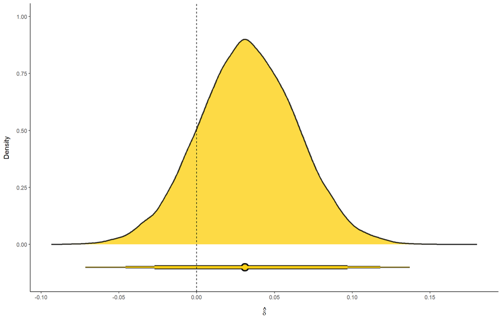

**NOTE**: Posterior distribution of the time difference (in time second standard deviations) between measurements across manipulation conditions (i.e., $\delta$). Posterior samples = 40,005. The dashed black line indicates a time difference of zero. The geometric below the distribution indicates the posterior mode (circle), the 95% HDCI (thick bar), 99% HDCI (thin bar), and 99.9% HDCI (line). Results derived from synthetic data generated by OpenAI’s (2024a) gpt-4o-mini using vignettes and questions based on Aarøe and Petersen (2014) and Petersen et al. (2012), as well as data by the IPUMS (Ruggles et al. 2024) and ANES (2021).

Table 4.9: Measurement Time Difference Between Manipulation Conditions

[output not shown]

**NOTE**: Bayesian Generalized Linear Model, estimated using Bayes MCMC with NUTS (Bürkner 2017, 2018). Posterior means with standard deviations in parentheses and 95% HDI in brackets. *n* = 1,009. *p* = Two-tailed probability of at least as extreme a sample estimate if assuming no true difference: ${}^{\#}\!$p ≤ .1, ${}^{*}\!$p ≤ .05, ${}^{**}\!$p ≤ .01, ${}^{***}\!$p ≤ .001. $ln(BF_{1,0})$ = Natural-logarithm-scaled Bayes factor with the null-hypothesis ($H_0: \delta = 0$) in the denominator. $\hat{R}$ = Rubin-Gelman Convergence metric, ‘Excellent’ if < 1.01 (Vehtari et al. 2021), ‘Acceptable’ if < 1.1 (Gelman and Rubin 1992), otherwise ‘Unacceptable’. ESS = *Effective sample size*, ‘Sufficient’ if ≥ 1,000, otherwise ‘Insufficient’ (Bürkner 2017). MCSE = *Monte-Carlo Standard Error* (Kruschke 2014). $\mathcal{T}_3$ = *Student t* distribution (Gosset 1908; Helmert 1876a; 1876b; 1875; Lüroth 1876; Pearson 1895b) with 3 degrees of freedom, validated as ‘noninformative’ relative to the data. $PP_P$ (Gelman et al. 1996) = 0.999. Bayesian $R^2$ (Gelman et al. 2019) = .000 (SD = .000; 95% HDI[.000; .000]). RMSE ($\hat{\varsigma}$) = 1.001 (SD = .021; 95% HDI[.959; 1.042]; $\hat{R}$ = 1; ESS = 21,918; MCSE = 0; Prior = $\mathcal{T}^{(0; \infty]}_3(1.000, .077)$). Results derived from synthetic data generated by OpenAI’s (2024a) gpt-4o-mini using vignettes and questions based on Aarøe and Petersen (2014) and Petersen et al. (2012), as well as data by the IPUMS (Ruggles et al. 2024) and ANES (2021).

Turning to the inferential statistics provided by the model, following (Mutz and Pemantle 2012: 3; Imai et al. 2008), these can be used to test whether the current implementation of the ‘parallel worlds’-estimation procedure can be expected to violate the simultaneity assumption. Consulting the 95% *highest density (posterior) intervals* (HD(P)I, McElreath 2019: 56-58), these reveal that the difference is expectly zero with 95% credibility. This can be similarly expressed by considering the two-tailed *p*-value (cf. Makowski et al. 2019a; 2019b), indicating that the probability of at least as an extreme difference assuming that there is no difference is 29.47%, which would be considered statistically *indiscernible* from zero at conventional levels ($p > .05$). In line with Bayesian inference (Heck 2019; Makowski et al. 2019b; Wagenmakers et al. 2010), an arguably more relevant conclusion can be derived by considering the computed Bayes factor (Makowski et al. 2019a). Assuming that a hypothesized time difference is as probable as no hypothesized time difference, taking then the inverse *exponent* (Euler 1862) of the resulting posterior log-odds reveals that the hypothesis that the ‘parallel worlds’-estimation procedure is *unbiased* is 20.20 times more probable than the hypothesis that the ‘parallel worlds’-estimation procedure is *biased*. Following the guidelines by Raftery (1995), this can be interpreted to provide ‘strong evidence against’ against the hypothesis that the ‘parallel worlds’-estimation violates the simultaneity assumption by generating non-zero time differences across manipulation conditions given the data. As such, while some time differences *do* exist in the sample, they make out a small portion, and with regards to the implementation of the ‘parallel worlds’-estimation procedure implemented here, the simultaneity assumption has been proven testable, with results indicating that it is unbiased and can be considered to produce no time differences.

## 4.5 Bayesian Inference

To replicate the meta-analytic estimate derived from Aarøe and Petersen (2014), Mummolo and Peterson (2019), and Kane et al. (2023) as closely as possible, the model used for statistical inference solely includes an intercept and coefficient for the difference between the ‘lazy’ and ‘unlucky’ welfare recipient manipulation conditions. Contrary to these existing study, Bayesian inference is used, which can generally be considered superior in terms of interpretation and inference (Cohen 1994: 998-999; Pawitan 2001: 13; Clayton 2021; Gelman et al. 2014, 2021; Kruschke 2010; Kruschke and Liddell 2018; McElreath 2019), though for increased comparability with their results, Frequentist models are used for robustness. As previously alluded to, a caveat of the SCF’s ability to generate multiple counterfactual outcomes for each synthetic respondent is that the data can be transformed into a ‘long format’ to take advantage of these multiple observations for each unit. While this creates a respondent-clustered structure in the data, which would violate the *iid* assumption because observations in this format would *not* be independent, it is easily accounted for with a hierarchical/multilevel model (Gelman and Hill 2007; Yarkoni 2020) that specifies respondent-varying intercepts. To ease comparability with the meta-analytic estimates, as well as the estimates by Aarøe and Petersen (2014), Mummolo and Peterson (2019), and Kane et al. (2023), the responses to the outcome ‘To what extent do you disagree or agree that the eligibility requirements for social welfare should be tightened for persons like him?’ (Aarøe and Petersen 2014: 689) are first recoded so that higher values indicate less agreement with tightening the eligibility requirements for the social welfare recipient, which is followed by then *normalizing* the outcome (i.e., *min-maxing*: rescaled 0-1). For similar reasons, the categorical variable indicating the manipulation condition is specified so that the reference category is the ‘lazy’ welfare recipient manipulation. Using notation similar to McElreath (2019) and Nalborczyk et al. (2019), the specified multilevel model is then formalized and provided in table 4.10.

Table 4.10: Modeled Relationship between Deservingness & Welfare Support

| $Y_i \: \overset{\mathrm{iid}}{\sim} \: \mathcal{T}_\nu(\mu_i, \sigma)$ | 1.1 |
| --- | --- |
| $\mu_i = \alpha_{id[i]} \: + \: \beta_G \: \cdot \: G_i$ | 1.2 |
| $\beta_G \: \overset{\mathrm{iid}}{\sim} \: \mathcal{T}_3(0, \: .077)$ | 1.3 |
| $\alpha_{id} \: \overset{\mathrm{iid}}{\sim} \: \mathcal{T}_3(\mu_\alpha, \: \sigma_\alpha)$ | 1.4 |
| $\mu_\alpha \: \overset{\mathrm{iid}}{\sim} \: \mathcal{T}_3(.5, \: .039)$ | 1.5 |
| $\sigma_\alpha \: \overset{\mathrm{iid}}{\sim} \: \mathcal{T}^{(0; \infty]}_3(0, \: .039)$ | 1.6 |
| $\sigma \: \overset{\mathrm{iid}}{\sim} \: \mathcal{T}^{(0; \infty]}_3(.5, \: .039)$ | 1.7 |
| $\nu \: \overset{\mathrm{iid}}{\sim} \: \mathcal{T}^{(1; 2018)}_3(2013, \: 155.757)$ | 1.8 |

**NOTE**: Bayesian Generalized Linear Model with respondent ID-varying intercepts. 1.1 is the likelihood-function, which specifies that the observations of the outcome variable $Y$ (i.e., welfare support) are assumed to be independent and identically (i.e., *iid*) distributed as a *Student t* distribution (Gosset 1908; Helmert 1876a; 1876b; 1875; Lüroth 1876; Pearson 1895b), with a mean, dispersion (i.e., residual standard deviation), and degrees of freedom (*df*) parameters. 1.2 is the *affine* function (Boyd and Vandenberghe 2018) of the mean parameter, which consists of random (i.e., respondent-level) varying intercepts and a fixed coefficient indicating the difference across the groups (i.e., manipulation conditions), with the ‘lazy’ welfare recipient vignette being the reference category. 1.3 is the prior of the fixed coefficient, specified as a *Student t* distribution, with a 3 *degrees of freedom* (*df*) parameter, a mean of 0, and dispersion of .077. 1.4 is the prior for the respondent-level varying intercepts, *Student t* distributed, with a *df* of 3, an unknown mean, which is the fixed (i.e., US-level) intercept, and an unknown dispersion parameter. 1.5 is the hyper prior for the fixed/mean parameter of the respondent-varying intercepts, being *Student t* distributed, *df* of 3, mean of .5, and a dispersion of .039. 1.6 is the hyper prior for the dispersion parameter of the respondent-varying intercepts, being distributed as a non-negative *Student t*, with a *df* of 3, mean of 0, and dispersion of .039. 1.7 is the prior for the dispersion of the outcome (RMSE), specified as a non-negative *Student t* distribution, with a *df* of 3, mean of .5, and dispersion of .039. 1.8 is the prior for the *df* parameter of the model, being distributed as a truncated *Student t*, with a mean of 2,013, dispersion of 155.757, while the truncation includes values between 1 and 2,018.

With this model specified, a few *a priori* considerations for testing the two aforementioned hypothesis can be made. In relation to the expectation that increasing deservingness increases welfare support ($H_1$), this is supported by the coefficient being (1) credibly different from zero as ascertained by a 95% *highest density (contiguous) interval* (HD(C)I, Kay 2024a; 2024b; Makowski et al. 2019a; McElreath 2019: 56-58), or similarly with a 95% *bias-corrected and accelerated* (BCa, Efron 1987) or a 95% *equal-tailed confidence interval* (CI, Stock and Watson 2019: 117-118) for Frequentist models, which following recommendations (Brandstätter 1999), are here preferred over *p*-values; and (2) that the *relative evidence* in the form of the *posterior odds* (Makowski et al. 2019a; i.e., BF with prior odds of 1, Wagenmakers et al. 2010) indicates that the hypothesis of a relationship between deservingness and welfare is more probable than the (null) hypothesis of no such relationship (i.e., $ln(BF) > 0$) given the data. It should also be noted that the sample size is listed as 2,018 in the analysis, due to the long-format of the data that accounts for each synthetic respondent in the nominal sample (*n* = 1,009) having had an outcome measured two times, one for each counterfactual outcome. With these considerations in mind, an analysis of the results can be conducted.